# SRK Bioinformatics

Nanopore-Based SRK Haplotype Reconstruction and Population Analysis Pipeline

Sven Buerki - Boise State University

2026-06-15

# 1 Pipeline at a Glance

This pipeline reconstructs S-receptor kinase (SRK) haplotypes from Nanopore amplicon sequencing of polyploid plants and turns them into population-genetic and crossing-design data products usable for conservation breeding. It comprises **28 steps in 5 phases**.

## 1.1 Roadmap — what the pipeline does, at a glance

Read the figure below left-to-right: each phase shows what it does (bullets), the steps it covers, and the canonical output it produces. Phase 2 → 3 → 4 → 5 each consume the previous phase’s outputs.

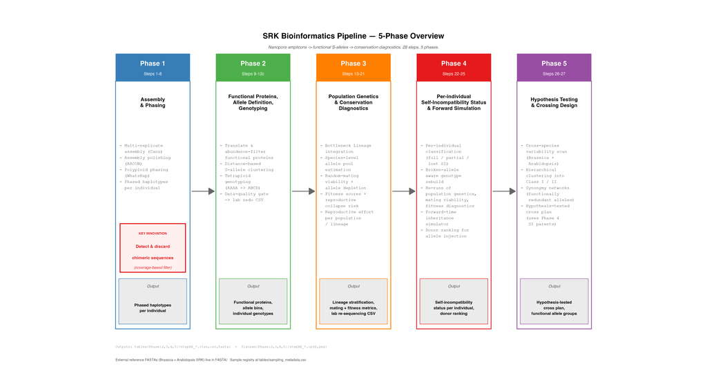

SRK pipeline overview — 5-phase roadmap from Nanopore amplicons through functional S-alleles to conservation diagnostics, cross plan, and forward-time simulation. Produced by `SRK_pipeline_overview_figure.R`. (Click to enlarge in a new tab.)

For step-by-step detail (scripts, inputs, outputs, key parameters) see the protocol document [`Bioinformatics_pipeline.md`](https://github.com/svenbuerki/SRK_bioinformatics/blob/main/Bioinformatics_pipeline.md).

## 1.2 Two design choices worth flagging up front

### 1.2.1 Chimera defence in two stages

Canu *de novo* assembly of Nanopore amplicons routinely produces chimeric contigs — reads from two different SRK haplotypes get spliced into a single false haplotype, and the splice junction typically introduces a premature stop codon. Left in the data, chimeras look molecularly indistinguishable from real broken SRK copies and inflate the per-individual broken-copy count, producing false `pSI` / `SC` calls. Because chimeras leave a different fingerprint at each stage, the pipeline filters them twice:

1. **Step 2 — coverage-based filter on the assembled DNA contigs.** `chimera_coverage_filter.py` runs inside the within-library assembly wrapper, after `seqkit rmdup` and before RACON polishing. It computes per-contig `uniformity = min_window_cov / median_cov` across a 200 bp sliding window and **drops contigs with `mean_cov < 20` OR `uniformity < 0.20`**. Threshold calibrated on Library 005 (2026-06-12) — the highest DROP sits at `uniformity = 0.182` and the lowest KEEP at `0.202`, a clean gap. Chimeric contigs show characteristic mid-contig depth crashes (high plateau collapsing to ~10×) that this metric isolates. Configurable via `CHIMERA_FILTER_MODE` (`report` for calibration vs `filter` for production), `MIN_MEAN_COV`, `MIN_UNIFORMITY`, `CHIMERA_WINDOW`. Stats land in `logs/${library}_${run_id}_${barcode}.chimera_stats.tsv`.
2. **Step 22a — AA-distance filter on translated haplotypes.** `SRK_null_allele_assignment.py` aligns every haplotype tagged `REMOVED` by Step 7 (premature stop) to the 49 canonical functional allele representatives via `mafft --add --keeplength` and computes amino-acid p-distance. Confidence tiers: `high` (`AA_distance ≤ 0.005` AND `n_stops ≤ 3`) and `medium` (`AA_distance ≤ 0.05` AND `n_stops ≤ 10`) are **real broken copies** of a known allele — they enter the Step 22b SI status calculation. `low` confidence (`AA_distance > 0.05` OR `n_stops > 10`) are chimeric Canu artefacts that resemble no known allele — they are recorded as `n_haps_chimeric` for data-quality transparency but excluded from the tetraploid-copy signal pool used by Step 22b. Also records `first_stop_position` and `stop_codon_DNA` for downstream IBD work distinguishing same-mutation (IBD) from independent-LoF (IBS) signals on the same allele.

Outputs: `Tables/Phase4/step22a_null_allele_assignments.tsv` (per-haplotype identity + confidence) consumed by Step 22b. Only individuals whose surviving haplotypes pass both layers reach a defensible SI / pSI / SC call.

### 1.2.2 Lab re-run identification — a single merged sheet

`evaluate_data_quality.py` (Step 12c) is the only place in the pipeline where samples are flagged for lab follow-up. It reads the per-sample exit point from every upstream stage — Phase 1 length / paralog / N-content / no-assembly failures + Phase 2 abundance / contamination failures — AND joins the Phase 4 Step 22b `Insufficient_data` individuals. The merged CSV at **`tables/Phase2/step12c_samples_redo.csv`** carries one `Lab_action` per row:

- **Re-PCR** — DNA stock fine; the PCR amplicon failed. Triggered by Stage 4b BLAST paralogs, Step 9 dropped_abundance_filter, Step 9 no_functional_proteins, Stage 3 no assembly, or Step 4 length-filter failures. Same-day operation; re-amplify from existing DNA.
- **Re-DNA-extraction** — DNA stock itself is contaminated (Step 9 `too_many_alleles` — individuals showing 15–26 distinct functional proteins). Requires fresh tissue isolation; re-PCR would preserve the contamination.
- **Re-sequence (SI status uncertain)** — added 2026-06-15 augmentation. Step 22b classified the individual as `Insufficient_data` (`n_haps_OK + n_haps_REMOVED_real < 4` after the Step 22a chimera filter, so the tetraploid copy budget is undefined). Existing DNA and library are fine; higher-coverage Nanopore re-run on the sequencer will resolve the call. The `Redo_reason_SI` column carries the per-sample diagnostic `Insufficient_data (n_haps_OK=…, REMOVED=…, chimeric=…)`.

The CSV’s full schema is `Lab_action, Sample_ID, Tube_number, Library, Barcode, EO, EO_normalised, BL_inferred, n_raw_haps, Proteins_in_final_data, Exclusion_stage, Recommended_action, Redo_reason_SI` and rows are sorted by `Lab_action → EO → Sample_ID` for field-collection grouping. This is the single file collaborators consult — root-level `Tables/SRK_samples_for_redo.tsv` and `Tables/SRK_samples_redo.csv` are pre-2026-06-14 paths and were removed from the GitHub repo in commit `8f8e820`.

**Phase 3 — Population genetics under a bottleneck-lineage framework** (Steps 13–21). Step 13 imports five independent bottleneck lineages (BL1–BL5) from the sibling repository LEPA_EO_spatial_clustering — derived by Ward’s D2 hierarchical clustering of 32 geographic-group centroids under a 500 m pollinator-connectivity threshold — and writes a per-individual BL assignment table consumed by every downstream analysis. Steps 14–21 then compute population-genetic statistics, allele-accumulation curves with Michaelis-Menten and Chao1 estimators, χ² goodness-of-fit against the NFDS equal-frequency expectation, the TP1 mating-pool functionality diagnostic (evenness J × tetraploid sporophytic-SI compatibility P_compat, at strict and leaky SI), allele composition / sharing (UpSet + heatmap), per-individual Genotypic Fitness Score, the TP2 tipping-point diagnostic (mean GFS × proportion AAAA), and reproductive-effort summaries — every output stratified in parallel by EO (management unit, ordered within parent BL by ascending mean Drift_index) and by BL (inferential unit, ordered by total habitat area then within-BL connectivity: **BL4, BL5, BL3, BL1, BL2**). The locked Set1 colour palette (BL1 purple, BL2 blue, BL3 red, BL4 orange, BL5 green) is used consistently with the sibling spatial-clustering repository. All BL ordering and palette decisions are centralised in the mirrored modules **`srk_bl_constants.R`** and **`srk_bl_constants.py`**, sourced/imported by every Phase 3/4 script (see Step 14 for the full ordering rules).

**Phase 5 — Hypothesis testing and crossing design** (Steps 26–27). Step 26a (`srk_variability_landscape.py`) runs an identical sliding-window Shannon-entropy scan on a combined alignment of LEPA + 22 *Brassica* + 10 *Arabidopsis* SRK alleles to detect hypervariable (HV) columns per species, validates LEPA HV regions against Brassica/Arabidopsis with a 10 000-permutation overlap test, and overlays the 12 SCR9-contact residues from Ma et al. 2016 (PDB 5GYY) for structural validation. Step 26b (`srk_allele_hypotheses.py`) consumes the canonical HV columns to compute HV-only pairwise distances, UPGMA-detect Class I / Class II, build the synonymy network (synonymy groups (HV-identical) + Synonymy_test bridges), and rank the AAAA × AAAA cross matrix into Incompatible / Synonymy_test / Compatible_within / Compatible_cross categories. Two optional diagnostics — **Step 26c** (`srk_wgroup_collapse_test.py`, tests how much Synonymy group redundancy contributes to LEPA’s low Shannon entropy) and **Step 26d** (`srk_perBL_entropy_test.py`, decomposes LEPA HV-column residue diversity per Bottleneck Lineage and compares to Brassica + Arabidopsis to distinguish drift from selection convergence) — flesh out the biological mechanism. **Step 26e** (`srk_cross_plan.py`) translates the cross categorisation into a phased experimental protocol (H0 / H1a / H1b / H2 / H3) with explicit AAAA / AAAB / AABB genotype requirements and paired controls for heterozygous-donor tests; every cross row is traceable to a sequence-based category (HV distance + Class from Step 26b) plus a genotype-based feasibility filter (`Allele_composition` from Step 12). Step 27 reads completed cross records and tests the predictions.

**Software stack and conventions.** Python 3 (BioPython, NumPy, pandas, SciPy, matplotlib, networkx); R (ggplot2, tidyverse, vegan, iNEXT, UpSetR, ComplexUpset); MAFFT, Canu, WhatsHap. By convention, PDFs are written to the project root and PNGs to `figures/`. Every Phase 3 / Phase 4 script reads `SRK_individual_BL_assignments.tsv` from Step 13 to add BL stratification to its outputs without breaking EO-level views.

# 2 GitHub Repository

The companion repository for this webpage is available at:

https://github.com/svenbuerki/SRK_bioinformatics/

For a concise step-by-step protocol (scripts, inputs, outputs, key parameters), see Bioinformatics_pipeline.md.

# 3 Introduction

Self-incompatibility (SI) systems represent one of the most important mechanisms preventing inbreeding in flowering plants, with the sporophytic SI system found in the Brassicaceae being controlled by the highly polymorphic S-locus. The S-receptor kinase (SRK) gene, encoding the female determinant of incompatibility specificity, exhibits extraordinary allelic diversity maintained by balancing selection over evolutionary timescales. Understanding SRK haplotype diversity and population genetic structure is critical for assessing the evolutionary maintenance of outcrossing systems and identifying populations at risk of SI breakdown.

Traditional approaches to SRK characterization have been limited by the technical challenges of resolving highly similar allelic sequences and the complex genetic architecture of polyploid species. Long-read Nanopore sequencing offers unprecedented opportunities to reconstruct complete SRK haplotypes and resolve allelic relationships within individuals, but requires specialized bioinformatics approaches to handle the unique characteristics of amplicon data from polymorphic loci.

This comprehensive pipeline integrates Nanopore amplicon assembly, haplotype phasing, and population genetic analysis to provide a complete workflow for SRK diversity assessment. The approach combines multiple CANU assembly replicates optimized for rare haplotype recovery with polyploid-aware variant calling and read-backed phasing to generate high-confidence haplotype reconstructions. Downstream analysis components translate DNA sequences to functional proteins, apply abundance-based filtering to distinguish authentic alleles from technical artifacts, and generate population genetic datasets suitable for demographic inference and conservation assessment.

The pipeline is specifically designed for threatened plant species research, addressing the critical need to assess SI system integrity in small or fragmented populations where genetic diversity loss may compromise reproductive success. By providing both molecular-level haplotype reconstruction and population-level genetic analysis, this workflow enables comprehensive evaluation of self-incompatibility system evolution and maintenance in natural populations facing conservation challenges.

Key innovations include multi-replicate assembly strategies for maximizing allelic recovery, reference-guided sequence orientation and gap-filling procedures, SRK-specific protein validation criteria, and tetraploid-aware zygosity analysis. The modular design allows adaptation to different species and study systems while maintaining rigorous quality control throughout the analysis workflow.

# 4 Pipeline Overview

## 4.1 Output organisation (2026-06-14 refactor — all 5 phases)

Every pipeline script reads/writes from a Phase- and step-prefixed path:

- **Tables**: `Tables/Phase{2,3,4,5}/stepXX_*.{tsv,csv,fasta}`
- **Figures**: `figures/Phase{2,3,4,5}/stepXX_*.{pdf,png}` — every plot now produces **both PDF and PNG** (vector + raster) except inherently multi-page PDFs (Step 15 curves, Step 16 frequency, Step 19 GFS, Step 16 chisq) where the page-level PNGs are companions.
- **External reference FASTAs** (Brassica, Arabidopsis SRK references for Step 26) live in `FASTA/`.
- `Tables/sampling_metadata.csv` is the single canonical metadata file (symlink at `./sampling_metadata.csv` for legacy scripts).

**Phase 5 (Step 26) update:** `pad_representatives.py` now restricts LEPA representatives to ingroup-observed alleles only (49 of 55), removing outgroup contamination from the cross-Brassicaceae variability landscape analysis.

**Phase 4 (Steps 22–25 + null-aware 14b/17b/19b/20b reruns)** writes to `Tables/Phase4/` and `figures/Phase4/` with `step22a/22b/23/14b/17b/19b/20b/24/25_*` prefixes.

See `Bioinformatics_pipeline.md` for the full directory tree.

## 4.2 Phase 1: SRK amplicon sequence assembly

1. Prepare Canonical Sequences – Preparation of reference SRK sequences used for downstream assembly and validation.
2. Nanopore Amplicon Assembly and Phasing Pipeline – Multi-CANU assembly of Nanopore amplicons followed by haplotype phasing to reconstruct allelic sequences.
3. Haplotype Orientation and Consolidation Pipeline – Standardization of sequence orientation and consolidation of phased haplotypes.
4. FASTA Sequence Filtering and Reference Integration Pipeline – Quality filtering of sequences by length and integration of validated reference alleles. 4b. Reference-Similarity Filter (BLAST + coverage) – Removes SRK paralogs that pass length filtering but contain a localised ~500 bp insertion. Paralogs are 98–100 % identical to canonical SRK where they align, so percent identity does not discriminate — the filter uses BLAST query coverage (≥0.90) against the canonical LEPA SRK reference set.
5. Multiple Sequence Alignment – Alignment of nucleotide sequences using MAFFT.
6. Exon Extraction from Multiple Sequence Alignments Pipeline – Extraction of coding regions based on AUGUSTUS gene annotations.
7. MSA Gap Backfilling and Terminus Processing Pipeline – Reference-guided backfilling of terminal alignment gaps and sequence terminus correction. 7b. Ambiguity (N-content) Filter – Removes contigs with N-rich termini. Origin of the `N`s: when Nanopore reads are shorter than the ~3.5 kb SRK amplicon (fragmentation during library prep, partial pore translocation), Canu *de novo* assembly produces contigs shorter than the canonical reference, and Step 7 pads the missing terminus with `N`. Those `N` codons translate to `X` residues in Step 8 and cause MAFFT to insert spurious gap blocks on the BEA canonical reference rows. Filtering at the DNA stage prevents the cascade.
8. DNA to Amino Acid Translation Pipeline – Frame-specific translation of nucleotide sequences into proteins. **Note:** This step is optional and may be skipped if protein sequences are not required.

## 4.3 Phase 2: Functional proteins, S alleles and genotyping

9. SRK Protein Translation, Alignment, and Abundance Filtering Pipeline – Translation of SRK alleles into proteins, alignment, and filtering based on abundance thresholds to retain functional candidates.
10. Distance-Based SRK S-Allele Definition – Grouping of functional proteins into allele bins using pairwise amino acid p-distance on the S-domain ectodomain, with sensitivity analysis and amino acid variation heatmaps.
11. SRK S-Allele Genotyping Pipeline – Assignment of distance-defined S-allele bins to individuals, producing long-format allele tables (with allele copy counts) and count-based genotype matrices for population genetic analysis.
12. SRK Zygosity Analysis Pipeline for Tetraploid Species – Classification of individuals as homozygous or heterozygous and estimation of population-level zygosity statistics in tetraploid species.

**⚠️ In Progress — Step 12b:** SRK Class Assignment and Dominance Prediction Pipeline – Phylogenetic classification of SRK proteins into Class I (dominant) or Class II (recessive) using IQ-TREE3, with per-individual dominance prediction for conservation breeding decisions. **This analysis is under active development and may not function correctly on all datasets.**

## 4.4 Phase 3: Data Analyses

13. Element Occurrence and Bottleneck Lineage Integration – Bridges the SRK individual-level dataset to the spatial framework defined in the sibling project LEPA_EO_spatial_clustering. For each post-QC individual, joins EO label, geographic group, bottleneck lineage (BL1–BL5), and drift index from `EO_group_BL_summary.csv`. Produces `SRK_individual_BL_assignments.tsv`, the join key used by all subsequent Phase 3 steps to add BL stratification (EO sorted within BL for management; BL aggregated for inferential power on small localities). 13b. Sampling Overview Map – Single-panel geographic map plotting every catalogued population against its parent BL. Filled triangles = sampled by the SRK pipeline; filled circles = not yet sampled. Recommended first visual in any presentation or report.
14. Population Genetics Statistics – Estimation of population-level diversity metrics, including heterozygosity, mean alleles per individual, total allele counts, and effective allele numbers.
15. Allele Accumulation Curves – Rarefaction-based analysis of SRK allele discovery across individuals to evaluate patterns consistent with negative frequency-dependent selection versus genetic drift. Includes estimation of total species allele richness using Michaelis-Menten asymptote fitting, Chao1, and iNEXT estimators.
16. Allele Frequency Analysis – Species- and population-level χ² tests of allele frequency distributions to assess deviations from equal-frequency expectations under negative frequency-dependent selection. The estimated species allele richness (from step 15) is used as the NFDS optimum baseline.
17. TP1 — Mating-pool functionality – **Is the depleted population still functioning?** Per-EO and per-BL evenness J × tetraploid sporophytic-SI compatibility P_compat, at strict (L = 0) and empirical-leakage (L = 0.25) levels. Quadrants map to conservation actions (MONITOR / AUGMENT-evenness / AUGMENT URGENTLY / BIOBANK + RESTORE). Connects directly to Stage 5 of the C3 cascade.
18. Allele Composition Comparison Across Element Occurrences – UpSet plot and pairwise sharing heatmap quantifying how S-allele sets overlap and partition across Element Occurrences, identifying private alleles and alleles shared by all populations.
19. Individual Genotypic Fitness Score – Per-individual GFS quantifying the proportion of heterozygous diploid gametes a tetraploid individual can produce, differentiating dosage-imbalanced genotypes (e.g. AABB vs AAAB) invisible to simple zygosity classification.
20. TP2 Tipping Point Analysis – **Reproductive Fitness**: EO-level tipping point assessment asking (x) what fraction of individuals are reproductive dead-ends (prop_AAAA) and (y) how much reproductive capacity the average individual still has (mean GFS); EOs breaching both thresholds simultaneously are flagged CRITICAL.
21. Reproductive Effort Support per Element Occurrence – Horizontal proportional bar chart showing the fraction of individuals at each GFS tier per EO, quantifying the proportion of the population capable of contributing allelic diversity to compatible crosses.

## 4.5 Phase 4: Per-individual SI status, null-aware genotypes, and forward simulation

> Phase 4 establishes the per-individual self-incompatibility status. This information is *required* before Phase 5 (cross design) — a cross plan is only meaningful when the parents have a verified functioning SI machinery.
22. **Per-individual SI / pSI / SC reconstruction** – `SRK_individual_SI_status.py` re-aggregates per-haplotype OK / REMOVED calls to classify each individual as full SI, partial SI, self-compatible, or insufficient_data. `SRK_null_allele_assignment.py` augments this by mapping REMOVED haplotypes to their nearest functional allele via amino acid distance.
23. **Null-aware genotype rebuild** – `SRK_genotype_null_alleles.py` rewrites the allele × individual matrix so that partial SI individuals carry explicit `Allele_NULL` copies and self-compatible individuals are represented as `Allele_NULL × 4`. Triggers null-aware cascade re-runs of Steps 14b (population genetics), 17b (random-mating viability), and 19b + 20b (fitness scores + reproductive collapse risk).
24. **Forward-time tetraploid inheritance simulator** – `SRK_inheritance_simulator.py` simulates per-lineage trajectories under multiple scenarios (baseline / high_drift / rescue_high / rescue_low) starting from the empirical Step 23 genotypes.
25. **Donor ranking for allele injection** – `SRK_injection_donor_ranking.py` ranks candidate seed parents for allele-injection crosses to rescue specific lineages / populations.

## 4.6 Phase 5: Testing S-allele Hypotheses and Cross Design

> Phase 5 uses the per-individual SI status established in Phase 4. Cross design is restricted to parents whose Phase 4 SI status is `SI` — broken-SI individuals cannot serve as reliable compatibility-prediction parents.
26. Hypervariable-Position Allele Hypothesis Testing and Crossing Design – Cross-Brassicaceae sliding-window Shannon-entropy scan identifies 66 canonical HV columns (anchored structurally by 11 of the 12 mappable Ma 2016 SCR9-contact residues; cross-genus permutation overlap with Brassica + Arabidopsis is no longer significant in the current post-QC dataset — interpreted as drift-eroded standing variation, see Step 26d); UPGMA auto-threshold clustering detects the Class I / Class II phylogenetic split (Class II = single allele, Allele_055); generates a sequence-based cross design for AAAA × AAAA pairs with four categories (Incompatible, Synonymy_test, Compatible_within, Compatible_cross) — restricted to Phase-4-verified SI parents. Optional diagnostics 26c (Synonymy group collapse test) and 26d (per-BL entropy decomposition) test alternative mechanisms underlying LEPA’s low entropy. **Step 26e** (Hypothesis-Testing Cross Plan) translates the sequence-based categories into a phased experimental protocol with explicit AAAA / AAAB / AABB genotype constraints (H0 SI validation, H1a within-Class baseline, H1b between-Class baseline, H2 synonymy bin boundaries, H3 hidden bins via heterozygous donors + paired controls).
27. Cross Result Analysis – Statistical comparison of seed yield across Incompatible / Synonymy_test / Compatible_within / Compatible_cross cross categories to test whether HV-based allele bin boundaries predict functional recognition specificity.

# 5 Phase 1: SRK amplicon sequence assembly

## 5.1 Prepare Canonical Sequences

> Warning: This need to be be done ONLY ONCE!
- SRK paralogs are in `SRK_canonical_haplotype_sequences.fasta`. These sequences are the result of the genome mining, but they need to be curated prior to conducting our analyses:
  1. Reverse complement sequences (the positions are aligned to genome, but preliminary annotation showed that the gene is on the negative strand)
  2. Check that they start with start codon (ATG). (it seems that the automatic annotation did miss the start codon of the gene. We just need to manually add the first two nucleotides)
  3. Annotate one sequence
  4. Check AA product
- **Folder:** `/Users/buerkilab/Documents/Amplicon_SRK/Canu_amplicon/Canonical_sequences`

### 5.1.1 Reverse Complement Sequences and Check Start Codon

- `reverse_complement_startcodon_fasta.py`

```python
#!/usr/bin/env python3

from Bio import SeqIO
from Bio.Seq import Seq
from Bio.SeqRecord import SeqRecord

# ----------------------------
# User input
# ----------------------------
in_fasta = input("Enter input DNA FASTA file: ").strip()

out_fasta = in_fasta.replace(".fasta", "_revcomp_ATGfixed.fasta")
log_file = in_fasta.replace(".fasta", "_startcodon_fix.log")

# ----------------------------
# Process sequences
# ----------------------------
records_out = []

with open(log_file, "w") as log:
    log.write("Sequence_ID\tAction\tNew_start\n")

    for record in SeqIO.parse(in_fasta, "fasta"):
        seq_rc = record.seq.reverse_complement()
        seq_str = str(seq_rc)

        action = "OK"

        if seq_str.startswith("ATG"):
            pass
        elif seq_str.startswith("TG"):
            seq_str = "A" + seq_str
            action = "Added_A"
        elif seq_str.startswith("G"):
            seq_str = "AT" + seq_str
            action = "Added_AT"
        else:
            action = "No_ATG_found"

        log.write(f"{record.id}\t{action}\t{seq_str[:3]}\n")

        records_out.append(
            SeqRecord(
                Seq(seq_str),
                id=record.id,
                description=record.description
            )
        )

# ----------------------------
# Write output
# ----------------------------
SeqIO.write(records_out, out_fasta, "fasta")

print("\n✅ Reverse complement + start codon correction complete")
print(f"Corrected FASTA: {out_fasta}")
print(f"Log file:        {log_file}")
```

### 5.1.2 Gene Annotation

- Done with the lab linux computer (`/media/Artemisia/Slicksport_PacBio/BEA/Augustus`) and the `SRK_canonical_haplotype_sequences_revcomp_ATGfixed.fasta` as template.
- **Output:** `augustus_SRK_canonical_haplotype_sequences_revcomp_ATGfixed_arabidopsis.csv`

```bash
## Model = Arabidopsis
# SRK_canonical_haplotype_sequences.fasta
augustus --species=arabidopsis --strand=both --singlestrand=false --genemodel=partial --protein=on --codingseq=on --introns=on --start=on --stop=on --cds=on --gff3=on --sample=100 --keep_viterbi=true --alternatives-from-sampling=true --minexonintronprob=0.2 --minmeanexonintronprob=0.5 --maxtracks=2 SRK_canonical_haplotype_sequences_revcomp_ATGfixed.fasta --exonnames=on > augustus_SRK_canonical_haplotype_sequences_revcomp_ATGfixed_arabidopsis.gff
```

## 5.2 Nanopore Amplicon Assembly and Phasing Pipeline

### 5.2.1 Overview

This pipeline implements a multi-replicate CANU assembly approach optimized for rare haplotype detection in Nanopore amplicon sequencing data. The workflow follows the methodology described in the knowledge base for SRK amplicon reconstruction and haplotype phasing.

### 5.2.2 Pipeline Steps

#### 5.2.2.1 Amplicon Reconstruction and Haplotype Phasing

Based on the knowledge base context: “For each individual, Nanopore reads from SRK amplicons are assembled de novo using CANU, followed by iterative polishing with RACON to improve consensus accuracy. Reads are then realigned to the polished assembly, and sequence variants are called using a polyploid-aware variant caller implemented in FreeBayes. Haplotypes are phased using read-backed phasing as implemented in WhatsHap, generating up to four phased SRK haplotypes per individual.”

#### 5.2.2.2 Input Parameters

The script requires three user inputs:

- **Library name**: Identifier for the sequencing library (e.g., Library001)
- **Starting barcode number**: First barcode to process (e.g., 01)
- **Ending barcode number**: Last barcode to process (e.g., 10)

#### 5.2.2.3 FASTQ File Management

The pipeline includes robust FASTQ concatenation logic:

```bash
# Concatenates individual .fastq.gz files if needed
# Checks for existing concatenated files
# Validates file integrity and timestamps
```

**Key features:**

- Automatic detection of existing concatenated files
- Validation of file completeness and timestamps
- Error handling for missing or empty files

#### 5.2.2.4 Multi-Replicate CANU Assembly

The pipeline runs four independent CANU assemblies per sample to maximize rare haplotype recovery:

```bash
REPS=4  # Number of CANU replicates

canu \
-p "${library}_${sample}_rep${rep}" \
-d "CANU_rep${rep}" \
genomeSize=5k \
-nanopore "$reads" \
useGrid=false \
correctedErrorRate=0.15 \
minInputCoverage=0 \
stopOnLowCoverage=0 \
corOutCoverage=10000 \
batOptions="-dg 3 -db 3 -dr 1 -ca 500 -cp 50"
```

**Parameters optimized for amplicon assembly:**

- `genomeSize=5k`: Appropriate for amplicon targets
- `correctedErrorRate=0.15`: Accommodates Nanopore error rates
- `minInputCoverage=0` and `stopOnLowCoverage=0`: Prevents assembly termination with low coverage
- Custom `batOptions`: Fine-tuned for small amplicon assembly

#### 5.2.2.5 Contig Consolidation

Combines contigs from multiple CANU replicates with proper naming:

```bash
# Renames contigs with replicate prefixes
# Removes duplicate sequences using seqkit
```

#### 5.2.2.6 Iterative RACON Polishing

Implements three rounds of RACON polishing to improve consensus accuracy:

```bash
for round in 1 2 3; do
    minimap2 -ax map-ont "$input" "$reads" > align.sam
    racon "$reads" align.sam "$input" > polished_r${round}.fasta
done
```

#### 5.2.2.7 Read Alignment and Indexing

Uses minimap2 for optimal Nanopore read alignment:

```bash
minimap2 -ax map-ont -t 8 "$polished_final" "$reads" | \
samtools view -bS - | \
samtools sort -o aligned.bam -
```

#### 5.2.2.8 Polyploid-Aware Variant Calling

Employs FreeBayes with tetraploid settings as specified in the knowledge base:

```bash
freebayes \
-f "$polished_final" \
-p 4 \
aligned.bam > variants.vcf
```

#### 5.2.2.9 Read-Backed Phasing

Implements WhatsHap polyphase for tetraploid phasing:

```bash
whatshap polyphase \
--ploidy 4 \
--reference "$polished_final" \
--ignore-read-groups \
-o phased.vcf \
variants.vcf.gz aligned.bam
```

#### 5.2.2.10 Haplotype Export

Generates up to four phased haplotypes per individual using bcftools consensus:

```bash
for i in 1 2 3 4; do
    bcftools consensus \
    -H $i \
    -f "$polished_final" \
    phased.vcf.gz \
    > "${library}_${sample}_hap${i}.fasta"
done
```

### 5.2.3 Output Files

For each sample, the pipeline generates:

- `combined_unique_contigs.fasta`: Deduplicated contigs from all CANU replicates
- `polished_r3.fasta`: Final polished assembly
- `aligned.bam`: Sorted and indexed read alignments
- `variants.vcf.gz`: Called variants
- `phased.vcf.gz`: Phased variants
- `${library}_${sample}_hap[1-4].fasta`: Individual haplotype sequences
- `${library}_${sample}_Phased_haplotypes.fasta`: Combined haplotype file

### 5.2.4 Error Handling

The script includes comprehensive error checking:

- File existence validation
- Empty file detection
- Timestamp comparison for file freshness
- Process failure detection with `set -euo pipefail`

### 5.2.5 Scientific Rationale

This multi-replicate approach addresses the stochastic nature of long-read assembly algorithms, particularly important for detecting rare haplotypes in self-incompatibility systems where allelic diversity is crucial for population viability. The combination of multiple assembly attempts with rigorous polishing and polyploid-aware variant calling maximizes the recovery of authentic haplotype sequences from complex amplicon pools.

### 5.2.6 Bioinformatics

```python
#!/bin/bash
set -euo pipefail

# ==========================================
# Nanopore Amplicon Assembly & Phasing Script
# Multi-CANU Rare Haplotype Optimized Version
# WITH FASTQ CONCATENATION
# ==========================================

orig_dir=$(pwd)

read -p "Enter library name (e.g., Library001): " library
read -p "Enter starting barcode number (e.g., 01): " start_barcode
read -p "Enter ending barcode number (e.g., 10): " end_barcode

start_num=$((10#$start_barcode))
end_num=$((10#$end_barcode))

# Number of CANU replicates
REPS=4

for n in $(seq "$start_num" "$end_num"); do

    sample=$(printf "barcode%02d" "$n")

    echo ""
    echo "========================================="
    echo "Processing $library / $sample"
    echo "========================================="

    cd "$orig_dir/$library/$sample"

    reads="${library}_${sample}.fastq.gz"

    # ==========================================
    # FASTQ CONCATENATION LOGIC
    # ==========================================

    if [[ ! -f "$reads" ]]; then
        echo "Concatenated FASTQ not found. Creating $reads..."

        # Check if there are individual .fastq.gz files to concatenate
        if ls *.fastq.gz 1> /dev/null 2>&1; then
            # Count existing .fastq.gz files (excluding the target file if it exists)
            gz_count=$(ls *.fastq.gz 2>/dev/null | grep -v "^${reads}$" | wc -l || echo "0")

            if [[ $gz_count -gt 0 ]]; then
                echo "Found $gz_count .fastq.gz files to concatenate"

                # Concatenate all .fastq.gz files except the target file
                cat $(ls *.fastq.gz | grep -v "^${reads}$") > "$reads"

                echo "Created $reads from individual files"
            else
                echo "ERROR: No .fastq.gz files found to concatenate in $(pwd)"
                echo "Available files:"
                ls -la
                exit 1
            fi
        else
            echo "ERROR: No .fastq.gz files found in $(pwd)"
            echo "Available files:"
            ls -la
            exit 1
        fi
    else
        echo "Using existing $reads"

        # Optional: Check if the existing file is newer than individual files
        if ls *.fastq.gz 1> /dev/null 2>&1; then
            individual_files=$(ls *.fastq.gz | grep -v "^${reads}$" || true)
            if [[ -n "$individual_files" ]]; then
                # Check if any individual file is newer than the concatenated file
                newer_files=$(find . -name "*.fastq.gz" -not -name "$reads" -newer "$reads" 2>/dev/null || true)
                if [[ -n "$newer_files" ]]; then
                    echo "WARNING: Some individual .fastq.gz files are newer than $reads"
                    echo "Consider regenerating the concatenated file"
                fi
            fi
        fi
    fi

    # Final check that the reads file exists and is not empty
    if [[ ! -f "$reads" ]]; then
        echo "ERROR: $reads still not found after concatenation attempt"
        exit 1
    fi

    if [[ ! -s "$reads" ]]; then
        echo "ERROR: $reads exists but is empty"
        exit 1
    fi

    echo "Using reads file: $reads ($(du -h "$reads" | cut -f1))"

    # ==========================================
    # Run multiple CANU assemblies
    # ==========================================

    for rep in $(seq 1 $REPS); do

        echo ""
        echo "Running CANU replicate $rep"

        canu \
        -p "${library}_${sample}_rep${rep}" \
        -d "CANU_rep${rep}" \
        genomeSize=5k \
        -nanopore "$reads" \
        useGrid=false \
        correctedErrorRate=0.15 \
        minInputCoverage=0 \
        stopOnLowCoverage=0 \
        corOutCoverage=10000 \
        batOptions="-dg 3 -db 3 -dr 1 -ca 500 -cp 50"

    done

    # ==========================================
    # Combine contigs with proper renaming
    # ==========================================

    echo ""
    echo "Combining contigs"

    > combined_contigs.fasta

    rep=1

    for dir in CANU_rep*; do

        fasta=$(ls $dir/*.contigs.fasta)

        awk -v prefix="rep${rep}_" '
        /^>/ {print ">" prefix substr($0,2); next}
        {print}
        ' "$fasta" >> combined_contigs.fasta

        ((rep++))

    done

    echo "Removing duplicate sequences"

    seqkit rmdup -s combined_contigs.fasta \
    > combined_unique_contigs.fasta

    assembly="combined_unique_contigs.fasta"

    # ==========================================
    # RACON polishing
    # ==========================================

    echo ""
    echo "Running RACON polishing"

    for round in 1 2 3; do

        input=$([ $round -eq 1 ] && echo "$assembly" || echo "polished_r$((round-1)).fasta")

        minimap2 -ax map-ont "$input" "$reads" > align.sam

        racon "$reads" align.sam "$input" > polished_r${round}.fasta

    done

    polished_final="polished_r3.fasta"

    # ==========================================
    # Align reads
    # ==========================================

    echo ""
    echo "Aligning reads"

    minimap2 -ax map-ont -t 8 "$polished_final" "$reads" | \
    samtools view -bS - | \
    samtools sort -o aligned.bam -

    samtools index aligned.bam

    # ==========================================
    # Variant Calling
    # ==========================================

    echo ""
    echo "Calling variants"

    freebayes \
    -f "$polished_final" \
    -p 4 \
    aligned.bam > variants.vcf

    bgzip -f variants.vcf

    tabix -p vcf variants.vcf.gz

    # ==========================================
    # WhatsHap Phasing
    # ==========================================

    echo ""
    echo "Phasing variants"

    whatshap polyphase \
    --ploidy 4 \
    --reference "$polished_final" \
    --ignore-read-groups \
    -o phased.vcf \
    variants.vcf.gz aligned.bam

    bgzip -f phased.vcf

    tabix -p vcf phased.vcf.gz

    # ==========================================
    # Export haplotypes
    # ==========================================

    echo ""
    echo "Exporting haplotypes"

    for i in 1 2 3 4; do

        bcftools consensus \
        -H $i \
        -f "$polished_final" \
        phased.vcf.gz \
        > temp.fasta

        sed "s/^>/>${library}_${sample}_hap${i}_/" temp.fasta \
        > "${library}_${sample}_hap${i}.fasta"

    done

    cat ${library}_${sample}_hap*.fasta \
    > ${library}_${sample}_Phased_haplotypes.fasta

    rm temp.fasta

    echo ""
    echo "Finished $library $sample"

    cd "$orig_dir"

done

echo ""
echo "====================================="
echo "ALL SAMPLES COMPLETE"
echo "====================================="
```

## 5.3 Haplotype Orientation and Consolidation Pipeline

### 5.3.1 Overview

This pipeline standardizes the orientation of phased haplotypes across all samples within a sequencing library by aligning them to a reference sequence and reverse-complementing sequences that align in the antisense orientation. The workflow consolidates all oriented haplotypes into a single multi-FASTA file for downstream analysis.

### 5.3.2 Pipeline Steps

#### 5.3.2.1 Haplotype Orientation Standardization

The pipeline addresses the inherent directionality ambiguity in amplicon sequencing data. Since PCR amplification can produce products in both forward and reverse orientations, and assembly algorithms may reconstruct haplotypes in either direction, standardization against a reference sequence ensures consistent orientation for comparative analyses.

#### 5.3.2.2 Input Parameters

The script requires two user inputs:

- **Library name**: Identifier for the sequencing library being processed
- **Reference FASTA**: Path to reference sequence file for orientation determination

```bash
read -p "Enter Library name: " Library
read -p "Enter reference FASTA: " REF_FASTA
REF_FASTA=$(realpath "$REF_FASTA")
```

#### 5.3.2.3 Output File Initialization

Creates a consolidated output file for all oriented haplotypes:

```bash
FINAL_OUT="all_${Library}_Phased_haplotypes.fasta"
> "$FINAL_OUT"  # Initialize empty file
```

#### 5.3.2.4 Barcode Directory Processing

Iterates through all barcode subdirectories within the specified library:

```bash
for BARCODE_DIR in "$Library"/barcode*/; do
    BARCODE=$(basename "$BARCODE_DIR")
    FULL_FASTA="${BARCODE_DIR}/${Library}_${BARCODE}_Phased_haplotypes.fasta"
```

**Key features:**

- Automatic detection of barcode directories
- Dynamic file path construction
- Missing file handling with warning messages

#### 5.3.2.5 File Validation

Implements robust error checking for missing input files:

```bash
if [[ ! -f "$FULL_FASTA" ]]; then
    echo "WARNING missing $FULL_FASTA"
    continue
fi
```

This ensures the pipeline continues processing even if individual samples failed in upstream steps.

#### 5.3.2.6 Reference Alignment

Uses minimap2 for sensitive alignment of haplotypes to the reference sequence:

```bash
minimap2 -a "$REF_FASTA" "$FILE" > hap_vs_ref.sam
```

**Alignment parameters:**

- `-a`: Output in SAM format for downstream processing
- Optimized for sequence similarity detection rather than read mapping

#### 5.3.2.7 Off-Target Contig Filtering

Before orientation, contigs are filtered to retain only those with a primary alignment to the reference. This removes off-target assemblies (e.g. contigs from a different genomic locus) that would otherwise stretch the downstream MAFFT alignment. SAM flags 4 (unmapped), 256 (secondary), and 2048 (supplementary) are excluded:

```bash
samtools view -F 2308 hap_vs_ref.sam \
| cut -f1 \
| sort -u \
> mapped.txt
```

A WARNING is printed if any contigs are discarded:

```bash
total=$(grep -c "^>" "$FILE" || true)
mapped_count=$(wc -l < mapped.txt)
filtered=$((total - mapped_count))
if [[ $filtered -gt 0 ]]; then
    echo "  WARNING: $filtered of $total contigs had no primary alignment to reference and were removed"
fi

seqkit grep -f mapped.txt "$FILE" > mapped.fasta
```

**Why this filter was added:** Library009 produced off-target contigs in barcodes 72, 75, 94, 40, 38, and 28 that caused MAFFT to generate an 18,212 bp alignment instead of the expected ~4,500 bp.

#### 5.3.2.8 Reverse-Complement Detection

Identifies sequences aligned in antisense orientation, restricted to primary alignments:

```bash
samtools view -f 16 -F 2308 hap_vs_ref.sam \
| cut -f1 \
| sort -u \
> to_reverse.txt
```

**SAM flag interpretation:**

- Flag 16: Sequence is reverse-complemented in alignment
- Flags excluded: 4 (unmapped), 256 (secondary), 2048 (supplementary)
- Extracts sequence identifiers requiring orientation correction

#### 5.3.2.9 Conditional Sequence Reversal

Implements conditional logic for sequence orientation correction, operating on the filtered mapped sequences:

```bash
if [[ -s to_reverse.txt ]]; then
    # Reverse-complement identified sequences
    seqkit grep -f to_reverse.txt mapped.fasta \
    | seqkit seq -r -p \
    > reversed.fasta

    # Keep forward-oriented sequences unchanged
    seqkit grep -v -f to_reverse.txt mapped.fasta \
    > forward.fasta

    # Combine oriented sequences
    cat forward.fasta reversed.fasta > "$ORIENTED"
else
    # No sequences require reversal
    cp mapped.fasta "$ORIENTED"
fi
```

**Seqkit parameters:**

- `-r`: Reverse-complement sequence
- `-p`: Print sequence on single line
- `-f`: Filter sequences by identifier list
- `-v`: Invert selection (exclude listed sequences)

#### 5.3.2.10 File Consolidation

Appends oriented haplotypes to the master output file:

```bash
cat "$ORIENTED" >> "$OLDPWD/$FINAL_OUT"
```

Uses `$OLDPWD` to maintain correct path reference when changing directories.

#### 5.3.2.11 Cleanup Operations

Removes intermediate files to conserve disk space:

```bash
rm -f hap_vs_ref.sam forward.fasta reversed.fasta mapped.fasta mapped.txt
```

### 5.3.3 Output Files

#### 5.3.3.1 Per-Sample Outputs

- `${Library}_${BARCODE}_Phased_haplotypes.oriented.fasta`: On-target oriented haplotypes for individual samples

#### 5.3.3.2 Consolidated Output

- `all_${Library}_Phased_haplotypes.fasta`: Master file containing all on-target oriented haplotypes from the library

### 5.3.4 Error Handling and Robustness

The pipeline includes several robustness features:

1. **Missing file tolerance**: Continues processing if individual samples are missing
2. **Path resolution**: Uses `realpath` for absolute reference paths
3. **Directory navigation**: Proper handling of working directory changes
4. **Conditional processing**: Only performs reverse-complement operations when necessary
5. **Process failure detection**: Uses `set -euo pipefail` for immediate error detection

### 5.3.5 Scientific Rationale

Consistent haplotype orientation is critical for downstream phylogenetic and population genetic analyses. In self-incompatibility research, where allelic relationships and evolutionary patterns are paramount, standardized sequence orientation ensures:

1. **Accurate sequence comparisons**: Prevents false divergence estimates due to orientation differences
2. **Proper alignment preparation**: Facilitates multiple sequence alignment for phylogenetic reconstruction
3. **Consistent annotation**: Enables uniform feature annotation across all haplotypes
4. **Reproducible analyses**: Ensures consistent results across different analysis runs

### 5.3.6 Computational Efficiency

The pipeline optimizes computational resources through: - **Single alignment per sample**: Minimizes computational overhead - **Conditional processing**: Only processes sequences requiring orientation correction - **Intermediate file cleanup**: Prevents disk space accumulation - **Batch processing**: Handles multiple samples in a single execution

This approach is particularly valuable when processing large numbers of samples with variable haplotype counts, as commonly encountered in population-level studies of self-incompatibility systems.

### 5.3.7 Bioinformatics

- For each barcode, find all `*_Phased_haplotypes.fasta`, orient haplotype sequences based on SRK haplotype sequences (canonical reference), produced final curated file
- **Input:**
  - Library folder name (e.g., `Library001`)
  - Canonical fasta file (incl. path) (e.g., `/Users/buerkilab/Documents/Amplicon_SRK/Canu_amplicon/Canonical_sequences/SRK_canonical_haplotype_sequences_revcomp_ATGfixed.fasta`)
- **Script:** `orient_haplotypes_library.sh`

```python
#!/bin/bash
set -euo pipefail

# ==========================================
# Orient haplotypes for ALL barcodes
# ==========================================

read -p "Enter Library name: " Library
read -p "Enter reference FASTA: " REF_FASTA

REF_FASTA=$(realpath "$REF_FASTA")

FINAL_OUT="all_${Library}_Phased_haplotypes.fasta"

> "$FINAL_OUT"

echo
echo "Processing $Library"
echo

for BARCODE_DIR in "$Library"/barcode*/; do

BARCODE=$(basename "$BARCODE_DIR")

FULL_FASTA="${BARCODE_DIR}/${Library}_${BARCODE}_Phased_haplotypes.fasta"

FILE=$(basename "$FULL_FASTA")


if [[ ! -f "$FULL_FASTA" ]]; then

echo "WARNING missing $FULL_FASTA"

continue

fi

echo "Processing $FULL_FASTA"

cd "$BARCODE_DIR"

ORIENTED="${Library}_${BARCODE}_Phased_haplotypes.oriented.fasta"

# Align

minimap2 -a "$REF_FASTA" "$FILE" > hap_vs_ref.sam

# Get sequences with a primary alignment to the reference
# Flags excluded: 4 (unmapped), 256 (secondary), 2048 (supplementary)

samtools view -F 2308 hap_vs_ref.sam \
| cut -f1 \
| sort -u \
> mapped.txt

# Report filtered contigs
total=$(grep -c "^>" "$FILE" || true)
mapped_count=$(wc -l < mapped.txt)
filtered=$((total - mapped_count))
if [[ $filtered -gt 0 ]]; then
    echo "  WARNING: $filtered of $total contigs had no primary alignment to reference and were removed"
fi

# Subset to on-target sequences only
seqkit grep -f mapped.txt "$FILE" > mapped.fasta

# Detect reverse among mapped sequences

samtools view -f 16 -F 2308 hap_vs_ref.sam \
| cut -f1 \
| sort -u \
> to_reverse.txt

# Reverse if needed

if [[ -s to_reverse.txt ]]; then

seqkit grep -f to_reverse.txt mapped.fasta \
| seqkit seq -r -p \
> reversed.fasta

seqkit grep -v -f to_reverse.txt mapped.fasta \
> forward.fasta


cat forward.fasta reversed.fasta \
> "$ORIENTED"

else

cp mapped.fasta "$ORIENTED"

fi

rm -f hap_vs_ref.sam forward.fasta reversed.fasta mapped.fasta mapped.txt

cat "$ORIENTED" >> "$OLDPWD/$FINAL_OUT"

cd "$OLDPWD"

done

echo
echo "DONE"
echo "Output: $FINAL_OUT"
```

## 5.4 FASTA Sequence Filtering and Reference Integration Pipeline

### 5.4.1 Overview

This pipeline filters haplotype sequences by minimum length criteria and integrates canonical reference sequences to create a comprehensive dataset for downstream phylogenetic and comparative analyses. The workflow is essential for preparing high-quality sequence datasets where length uniformity and reference inclusion are critical for accurate evolutionary inferences.

### 5.4.2 Pipeline Steps

#### 5.4.2.1 Quality Control Through Length Filtering

Length filtering serves multiple scientific purposes in haplotype analysis:

- **Assembly quality control**: Removes truncated or incomplete assemblies
- **Alignment preparation**: Ensures sequences are suitable for multiple sequence alignment
- **Phylogenetic reliability**: Excludes sequences with insufficient informative sites
- **Comparative analysis**: Maintains dataset homogeneity for population genetic analyses

#### 5.4.2.2 Input Parameters and Validation

The script requires four user-specified parameters:

```bash
read -p "Enter merged haplotype FASTA file: " MERGED_FASTA
read -p "Enter canonical reference FASTA file: " REF_FASTA
read -p "Enter minimum sequence length (bp): " MINLEN
read -p "Enter maximum sequence length (bp): " MAXLEN
```

**Parameter specifications:**

- **Merged haplotype FASTA**: Output from previous haplotype consolidation step
- **Canonical reference FASTA**: Known reference sequences for comparative context
- **Minimum length threshold**: Quality control parameter (typically 80-90% of expected amplicon length)
- **Maximum length threshold**: Removes mis-assembled or chimeric contigs. Library009 (96 samples) produced outlier assemblies of 4134–4841 bp in barcodes 32, 40, and 72 that caused MAFFT to generate an 18,212 bp-wide alignment instead of the expected ~4,500 bp. Set to **4000 bp** to eliminate such outliers.

#### 5.4.2.3 File Existence Validation

Implements robust input validation to prevent downstream errors:

```bash
for f in "$MERGED_FASTA" "$REF_FASTA"; do
    if [[ ! -f "$f" ]]; then
        echo "ERROR: File not found: $f" >&2
        exit 1
    fi
done
```

**Error handling features:**

- Checks all input files before processing
- Outputs errors to stderr (`>&2`)
- Immediate termination on missing files
- Prevents partial processing with invalid inputs

#### 5.4.2.4 Dynamic Output Naming

Generates descriptive output filenames that preserve processing parameters:

```bash
BASENAME="${MERGED_FASTA%.fasta}"
OUT="${BASENAME}_filtered_min${MINLEN}_max${MAXLEN}.fasta"
```

**Naming convention benefits:**

- Preserves original filename stem
- Documents both filtering parameters in filename
- Enables parameter tracking in complex workflows
- Prevents accidental file overwrites

#### 5.4.2.5 Reference Integration

Combines canonical references with experimental haplotypes before filtering:

```bash
TMP_COMBINED=$(mktemp)
cat "$REF_FASTA" "$MERGED_FASTA" > "$TMP_COMBINED"
```

**Scientific rationale:**

- **Phylogenetic rooting**: Provides known sequences for tree rooting
- **Allelic classification**: Enables assignment of haplotypes to known allelic classes
- **Evolutionary context**: Places novel haplotypes within established evolutionary framework
- **Quality assessment**: Allows comparison with validated reference sequences

#### 5.4.2.6 Length-Based Filtering

Applies minimum and maximum length thresholds using seqkit for efficient processing:

```bash
seqkit seq -m "$MINLEN" -M "$MAXLEN" "$TMP_COMBINED" > "$OUT"
```

**Seqkit parameters:**

- `-m "$MINLEN"`: Minimum sequence length filter (3250 bp in our case)
- `-M "$MAXLEN"`: Maximum sequence length filter (4000 bp in our case)
- Efficient processing of large FASTA files
- Preserves sequence headers and formatting
- Maintains sequence order from input

#### 5.4.2.7 Temporary File Management

Implements proper cleanup of intermediate files:

```bash
TMP_COMBINED=$(mktemp)  # Creates secure temporary file
# ... processing ...
rm -f "$TMP_COMBINED"   # Cleanup after processing
```

**Security and efficiency features:**

- Uses `mktemp` for secure temporary file creation
- Prevents disk space accumulation
- Avoids naming conflicts in concurrent executions
- Maintains system cleanliness

### 5.4.3 Output Files

#### 5.4.3.1 Primary Output

- `${BASENAME}_filtered_min${MINLEN}_max${MAXLEN}.fasta`: Filtered sequences meeting both length thresholds, including canonical references

**Output characteristics:**

- Contains both reference and experimental sequences
- All sequences meet minimum and maximum length requirements
- Preserves original sequence identifiers
- Ready for downstream phylogenetic analysis

### 5.4.4 Quality Control Metrics

The filtering process provides implicit quality metrics:

1. **Sequence retention rate**: Proportion of sequences passing length filter
2. **Length distribution**: Range of sequence lengths in final dataset
3. **Reference inclusion**: Confirmation of canonical sequence integration
4. **Dataset completeness**: Total number of sequences for analysis

### 5.4.5 Scientific Applications

This filtered dataset serves multiple research objectives:

#### 5.4.5.1 Phylogenetic Analysis

- **Tree construction**: Uniform sequence lengths improve alignment quality
- **Bootstrap support**: Adequate sequence length enhances statistical confidence
- **Evolutionary relationships**: Reference sequences provide phylogenetic context

#### 5.4.5.2 Population Genetics

- **Allelic diversity**: Quantification of haplotype variation within populations
- **Frequency estimation**: Accurate representation of allelic frequencies
- **Selection analysis**: Detection of balancing selection signatures

#### 5.4.5.3 Self-Incompatibility Research

- **Allele identification**: Classification of novel haplotypes relative to known alleles
- **Functional prediction**: Sequence-based inference of incompatibility phenotypes
- **Evolutionary dynamics**: Analysis of allelic turnover and maintenance

### 5.4.6 Parameter Optimization

#### 5.4.6.1 Length Threshold Selection

Optimal minimum and maximum lengths depend on:

- **Expected amplicon size**: Minimum typically 80-90% of full-length sequence; maximum typically 110-120%
- **Assembly quality**: Balance between inclusivity and quality
- **Downstream requirements**: Alignment and phylogenetic analysis needs
- **Reference sequence lengths**: Consistency with canonical sequences

#### 5.4.6.2 Typical Thresholds

- **SRK amplicons**: minimum 3250 bp, maximum 4000 bp (for ~3500 bp expected amplicon length)
- **Partial sequences**: 1500-2000 bp minimum (for targeted regions)
- **Quality control**: 70-80% of expected full length for minimum; 110-120% for maximum

### 5.4.7 Integration with Upstream Workflows

This pipeline integrates seamlessly with the haplotype orientation workflow:

1. **Input compatibility**: Accepts consolidated haplotype files
2. **Reference consistency**: Uses same reference sequences for orientation and filtering
3. **Parameter continuity**: Maintains sample and library identifiers
4. **Output formatting**: Produces analysis-ready FASTA files

The filtered output serves as high-quality input for subsequent phylogenetic reconstruction, population genetic analysis, and functional annotation workflows essential for understanding self-incompatibility system evolution and maintenance.

### 5.4.8 Bioinformatics

```bash
#!/bin/bash
set -euo pipefail

# ==========================================
# Filter FASTA sequences by minimum and maximum length
# and add canonical references
# ==========================================

# ----------------------------
# User input
# ----------------------------
read -p "Enter merged haplotype FASTA file: " MERGED_FASTA
read -p "Enter canonical reference FASTA file: " REF_FASTA
read -p "Enter minimum sequence length (bp): " MINLEN
read -p "Enter maximum sequence length (bp): " MAXLEN

# Check if input files exist
for f in "$MERGED_FASTA" "$REF_FASTA"; do
    if [[ ! -f "$f" ]]; then
        echo "ERROR: File not found: $f" >&2
        exit 1
    fi
done

# Determine output file name
BASENAME="${MERGED_FASTA%.fasta}"
OUT="${BASENAME}_filtered_min${MINLEN}_max${MAXLEN}.fasta"

# ----------------------------
# Step 1: Combine canonical references with merged FASTA
# ----------------------------
TMP_COMBINED=$(mktemp)
cat "$REF_FASTA" "$MERGED_FASTA" > "$TMP_COMBINED"

# ----------------------------
# Step 2: Filter sequences by minimum and maximum length using seqkit
# ----------------------------
seqkit seq -m "$MINLEN" -M "$MAXLEN" "$TMP_COMBINED" > "$OUT"

# Cleanup
rm -f "$TMP_COMBINED"

echo "Filtered FASTA written to: $OUT"
```

## 5.5 Reference-Similarity Filter (BLAST + coverage)

### 5.5.1 Overview

Length-based filtering alone (Step 4) does not separate true SRK alleles from SRK paralogs. Library 010 (2026-05-11) revealed a bimodal length distribution after the length filter: a true SRK cluster at ~3300 bp and a paralog cluster at ~3900 bp carrying a localised ~500 bp insertion. Crucially, **both clusters are 98–100 % identical** to the canonical SRK reference where they align, so percent identity does not discriminate. The only discriminator is **BLAST query coverage**: true SRK aligns over ≥90 % of query length, paralogs over ≤85 % (the inserted region does not align to canonical SRK).

If these paralogs are not removed before Step 5, they inflate the MAFFT alignment (Library 010: 5690 bp wide, 40–45 % gaps per row) and produce spurious gap blocks in the Step 8 AA alignment.

### 5.5.2 Pipeline Steps

1. Build a `blastn` database from the canonical LEPA SRK reference set (4 BEA-hybrid haplotypes).
2. Align each length-filtered query against the database, retaining the best hit per query (`-max_target_seqs 1 -max_hsps 1`).
3. Compute per-query coverage = `alignment_length / query_length`.
4. Retain sequences with `coverage ≥ 0.90` **and** `pct_identity ≥ 95`; canonical reference IDs are always retained regardless of result.

### 5.5.3 Defaults and parameter choice

- `min_coverage = 0.90` — selected from the Library 010 distribution (clean gap between true SRK at 90–100 % cov and paralogs at 70–85 % cov).
- `min_identity = 95` — rejects spurious low-identity hits but does not attempt to use identity for paralog discrimination (paralogs are 98–100 % identical where they align).

### 5.5.4 Validation (Library 010)

| Metric | Before Step 4b | After Step 4b |
| --- | --- | --- |
| Sequences | 2260 | 1516 (–744 paralog/chimeric) |
| Step 5 MSA width | 5690 bp | 3735 bp |
| Per-row gap fraction | 40–45 % | <20 % |

Runtime ~3 s on 2260 sequences (4 threads).

### 5.5.5 Bioinformatics

- Script: `filter_by_reference_similarity.sh`
- Input:
  - Length-filtered FASTA (Step 4 output, e.g. `all_Library010_Phased_haplotypes_filtered_min3250_max4000.fasta`)
  - Canonical SRK reference FASTA (`Canonical_sequences/SRK_canonical_haplotype_sequences_revcomp_ATGfixed.fasta`)
  - Minimum query coverage `[default 0.90]`
  - Minimum percent identity `[default 95]`
  - BLAST threads `[default 4]`
- Output:
  - `all_Library00X_..._min3250_max4000_blastfilt.fasta` — paralog-purged FASTA, input to Step 5
  - `all_Library00X_..._min3250_max4000_blastfilt_log.tsv` — per-query decision log (`query_id`, `query_length`, `pct_identity`, `coverage`, `decision`)

## 5.6 Multiple Sequence Alignment

- Align sequences with `MAFFT`.
- Two naming conventions appear in the example commands below:
  - **Legacy (Libraries 001–009):** Step 5 was run on `_min3250_max4000.fasta` directly (Step 4b was not yet part of the pipeline). Filename suffix: `_aligned.fasta`.
  - **Current (Library 010 onward):** Step 5 is run on the Step 4b output (`_min3250_max4000_blastfilt.fasta`). Filename suffix: `_blastfilt_aligned.fasta`.

### 5.6.1 Libraries 001–009 (legacy convention)

- Input: `all_Library00X_Phased_haplotypes_filtered_min3250_max4000.fasta`

```bash
# Library001
mafft --auto --adjustdirection all_Library001_Phased_haplotypes_filtered_min3250_max4000.fasta > all_Library001_Phased_haplotypes_filtered_min3250_max4000_aligned.fasta

# Library002
mafft --auto --adjustdirection all_Library002_Phased_haplotypes_filtered_min3250_max4000.fasta > all_Library002_Phased_haplotypes_filtered_min3250_max4000_aligned.fasta

# Library003
mafft --auto --adjustdirection all_Library003_Phased_haplotypes_filtered_min3250_max4000.fasta > all_Library003_Phased_haplotypes_filtered_min3250_max4000_aligned.fasta

# Library004
mafft --auto --adjustdirection all_Library004_Phased_haplotypes_filtered_min3250_max4000.fasta > all_Library004_Phased_haplotypes_filtered_min3250_max4000_aligned.fasta

# Library005
mafft --auto --adjustdirection all_Library005_Phased_haplotypes_filtered_min3250_max4000.fasta > all_Library005_Phased_haplotypes_filtered_min3250_max4000_aligned.fasta

# Library006
mafft --auto --adjustdirection all_Library006_Phased_haplotypes_filtered_min3250_max4000.fasta > all_Library006_Phased_haplotypes_filtered_min3250_max4000_aligned.fasta

# Library009
mafft --auto --adjustdirection all_Library009_Phased_haplotypes_filtered_min3250_max4000.fasta > all_Library009_Phased_haplotypes_filtered_min3250_max4000_aligned.fasta
```

### 5.6.2 Library 010 onward (current convention, Steps 4b + 7b applied)

- Input: `all_Library00X_Phased_haplotypes_filtered_min3250_max4000_blastfilt.fasta`

```bash
# Library010
mafft --auto --adjustdirection all_Library010_Phased_haplotypes_filtered_min3250_max4000_blastfilt.fasta > all_Library010_Phased_haplotypes_filtered_min3250_max4000_blastfilt_aligned.fasta
```

## 5.7 Exon Extraction from Multiple Sequence Alignments Pipeline

### 5.7.1 Overview

This Python pipeline extracts exonic sequences from multiple sequence alignments (MSAs) using gene structure annotations from AUGUSTUS gene prediction software. The workflow maps genomic coordinates to alignment positions and extracts coding sequences while preserving alignment-derived insertions and deletions, enabling comparative analysis of protein-coding regions across haplotypes.

### 5.7.2 Pipeline Steps

#### 5.7.2.1 Exon-Focused Comparative Analysis

Exon extraction serves critical functions in self-incompatibility research:

- **Functional sequence analysis**: Focuses on protein-coding regions
- **Selection pressure detection**: Enables analysis of synonymous vs. non-synonymous changes
- **Structural annotation**: Identifies conserved and variable coding domains
- **Phylogenetic inference**: Improves signal-to-noise ratio for evolutionary analysis

#### 5.7.2.2 Input Parameters and Validation

The script requires five user-specified parameters:

```python
msa_file = input("Enter MSA FASTA path (aligned sequences, including canonical reference): ").strip()
canonical_id = input("Enter canonical reference ID (exact header in MSA): ").strip()
augustus_csv = input("Enter AUGUSTUS CSV with exon positions: ").strip()
strand = input("Enter strand of annotation for canonical reference (+/-): ").strip()
min_exon_len = input("Enter minimum exon length (default 0): ").strip()
```

**Parameter specifications:**

- **MSA FASTA**: Multiple sequence alignment including reference and haplotype sequences
- **Canonical reference ID**: Exact sequence identifier for coordinate mapping
- **AUGUSTUS CSV**: Gene structure annotation in CSV format from AUGUSTUS gene prediction
- **Strand orientation**: Directionality of gene annotation (+ or -)
- **Minimum exon length**: Quality filter for exon inclusion (default: 0 bp)

#### 5.7.2.3 Multiple Sequence Alignment Loading

Loads and validates the input MSA using BioPython:

```python
msa = SeqIO.to_dict(SeqIO.parse(msa_file, "fasta"))

if canonical_id not in msa:
    raise ValueError("Canonical reference ID not found in MSA")

canonical_seq = msa[canonical_id].seq
```

**Validation features:**

- Dictionary conversion for efficient sequence access
- Reference sequence validation
- Error handling for missing canonical reference
- Sequence object preservation for downstream processing

#### 5.7.2.4 AUGUSTUS Annotation Processing

Parses gene structure annotations and applies quality filters:

```python
with open(augustus_csv, newline='') as csvfile:
    reader = csv.DictReader(csvfile)
    exons = [row for row in reader if row['V3'] == 'exon']

# Filter by minimum exon length and sort by start
exons = [e for e in exons if int(e['V5']) - int(e['V4']) + 1 >= min_exon_len]
exons.sort(key=lambda x: int(x['V4']))
```

**Processing features:**

- **Feature filtering**: Selects only exon annotations from AUGUSTUS output
- **Length filtering**: Removes exons below minimum length threshold
- **Coordinate sorting**: Orders exons by genomic start position
- **Quality control**: Ensures reliable exon boundary definition

#### 5.7.2.5 Genomic-to-MSA Coordinate Mapping

Creates position mapping between genomic coordinates and alignment positions:

```python
genomic_to_msa = {}
seq_index = 0
for i, nt in enumerate(canonical_seq):
    if nt != '-':
        genomic_to_msa[seq_index + 1] = i  # 1-based genomic positions
        seq_index += 1
```

**Mapping algorithm:**

- **Gap handling**: Skips alignment gaps in canonical reference
- **Coordinate conversion**: Maps 1-based genomic positions to 0-based alignment indices
- **Reference-based**: Uses canonical sequence as coordinate reference
- **Insertion preservation**: Maintains alignment-derived insertions in other sequences

#### 5.7.2.6 Exon Sequence Extraction

Extracts exonic sequences from all sequences in the MSA:

```python
for seq_name, seq_record in msa.items():
    seq_aln = seq_record.seq
    exon_seq = Seq("")

    for e in exons:
        start_gen = int(e['V4'])
        end_gen = int(e['V5'])
        try:
            msa_start = genomic_to_msa[start_gen]
            msa_end = genomic_to_msa[end_gen]
        except KeyError:
            continue  # skip if exon position not in mapping

        exon_seq += seq_aln[msa_start:msa_end+1]
```

**Extraction features:**

- **Concatenated exons**: Joins all exonic sequences into single sequence
- **Error handling**: Skips exons with unmappable coordinates
- **Sequence preservation**: Maintains gaps and insertions from alignment
- **Universal processing**: Applies same extraction to all sequences

#### 5.7.2.7 Strand-Specific Processing

Handles gene orientation through conditional reverse-complementation:

```python
if strand == '-':
    exon_seq = exon_seq.reverse_complement()
```

**Biological significance:**

- **Coding strand correction**: Ensures sequences represent actual coding strand
- **Functional analysis**: Maintains proper reading frame orientation
- **Comparative consistency**: Standardizes orientation across all sequences
- **Translation compatibility**: Enables downstream protein analysis

#### 5.7.2.8 Output Generation

Creates BioPython SeqRecord objects and writes output FASTA:

```python
exon_records.append(SeqRecord(exon_seq, id=seq_name, description=""))

out_file = msa_file.replace(".fasta", "_exons.fasta")
SeqIO.write(exon_records, out_file, "fasta")
```

**Output features:**

- **Identifier preservation**: Maintains original sequence names
- **Automatic naming**: Generates descriptive output filename
- **Standard format**: Produces FASTA-compatible output
- **Metadata retention**: Preserves sequence relationships

### 5.7.3 Output Files

#### 5.7.3.1 Primary Output

- `${input_basename}_exons.fasta`: Concatenated exonic sequences for all input sequences

**Output characteristics:**

- Contains only protein-coding sequences
- Preserves alignment-derived gaps and insertions
- Maintains sequence identifier consistency
- Ready for downstream protein analysis

### 5.7.4 Scientific Applications

#### 5.7.4.1 Molecular Evolution Analysis

**Synonymous vs. Non-synonymous Analysis:**

- Calculation of dN/dS ratios for selection detection
- Identification of sites under positive or purifying selection
- Comparative analysis of selection pressures across gene regions

**Protein Structure Prediction:**

- Translation to amino acid sequences for structural analysis
- Domain identification and functional annotation
- Comparative protein modeling across haplotypes

#### 5.7.4.2 Self-Incompatibility Research

**Functional Domain Analysis:** - **Hypervariable regions**: Identification of polymorphic sites critical for specificity - **Conserved domains**: Detection of structurally important regions - **Binding sites**: Analysis of receptor-ligand interaction domains

**Allelic Classification:** - Protein-based phylogenetic reconstruction - Functional group assignment based on coding sequence similarity - Prediction of incompatibility phenotypes from sequence data

### 5.7.5 Quality Control and Error Handling

#### 5.7.5.1 Coordinate Mapping Validation

- **Boundary checking**: Ensures exon coordinates fall within sequence bounds
- **Gap handling**: Properly manages alignment gaps in coordinate conversion
- **Missing data**: Graceful handling of unmappable exon positions

#### 5.7.5.2 Sequence Integrity

- **Length validation**: Confirms expected exon lengths after extraction
- **Frame preservation**: Maintains reading frame consistency across sequences
- **Quality metrics**: Implicit validation through successful coordinate mapping

### 5.7.6 Integration with Upstream Workflows

This pipeline integrates with previous steps in the haplotype analysis workflow:

1. **MSA dependency**: Requires high-quality multiple sequence alignment
2. **Annotation integration**: Utilizes AUGUSTUS gene predictions for structural annotation
3. **Reference consistency**: Uses same canonical reference across all analysis steps
4. **Output compatibility**: Produces sequences suitable for phylogenetic and selection analysis

The extracted exonic sequences provide the foundation for detailed molecular evolutionary analyses essential for understanding the functional significance of sequence variation in self-incompatibility systems, where protein-level changes directly impact reproductive compatibility and population genetic dynamics.

### 5.7.7 Bioinformatics

- Activate container: source srk_env/bin/activate
- Script: `extract_exons_with_annotation.py`

Input: - MSA file (current convention, Library 010+): `all_Library010_Phased_haplotypes_filtered_min3250_max4000_blastfilt_aligned.fasta` - MSA file (legacy convention, Libraries 001–009): `all_Library006_Phased_haplotypes_filtered_min3250_max4000_aligned.fasta` - Name of ref sequence associated with Augustus annotation: `SRK_BEA_hybrid_bp_hap1_p_ctg_fa|amp_1|h1tg000019l|1700582|3407` - Annotation file in csv: `/Users/buerkilab/Documents/Amplicon_SRK/Canu_amplicon/Canonical_sequences/augustus_SRK_canonical_haplotype_sequences_revcomp_ATGfixed_arabidopsis.csv` -> This file was generated by annotating the canonical sequences using Augustus - Annotation strand: `+` - Min exon length: 0 Output: - Current convention: `all_Library010_Phased_haplotypes_filtered_min3250_max4000_blastfilt_aligned_exons.fasta` - Legacy convention: `all_Library003_Phased_haplotypes_filtered_min3250_max4000_aligned_exons.fasta`

```python
#!/usr/bin/env python3
import csv
from Bio import SeqIO
from Bio.Seq import Seq
from Bio.SeqRecord import SeqRecord

# ----------------------------
# User inputs
# ----------------------------
msa_file = input("Enter MSA FASTA path (aligned sequences, including canonical reference): ").strip()
canonical_id = input("Enter canonical reference ID (exact header in MSA): ").strip()
augustus_csv = input("Enter AUGUSTUS CSV with exon positions: ").strip()
strand = input("Enter strand of annotation for canonical reference (+/-): ").strip()
min_exon_len = input("Enter minimum exon length (default 0): ").strip()

min_exon_len = int(min_exon_len) if min_exon_len else 0

# ----------------------------
# Load MSA
# ----------------------------
msa = SeqIO.to_dict(SeqIO.parse(msa_file, "fasta"))

if canonical_id not in msa:
    raise ValueError("Canonical reference ID not found in MSA")

canonical_seq = msa[canonical_id].seq

# ----------------------------
# Read AUGUSTUS CSV
# ----------------------------
with open(augustus_csv, newline='') as csvfile:
    reader = csv.DictReader(csvfile)
    exons = [row for row in reader if row['V3'] == 'exon']

# Filter by minimum exon length and sort by start
exons = [e for e in exons if int(e['V5']) - int(e['V4']) + 1 >= min_exon_len]
exons.sort(key=lambda x: int(x['V4']))

# ----------------------------
# Build genomic -> MSA mapping
# ----------------------------
genomic_to_msa = {}
seq_index = 0
for i, nt in enumerate(canonical_seq):
    if nt != '-':
        genomic_to_msa[seq_index + 1] = i  # 1-based genomic positions
        seq_index += 1

# ----------------------------
# Extract exon sequences
# ----------------------------
exon_records = []

for seq_name, seq_record in msa.items():
    seq_aln = seq_record.seq
    exon_seq = Seq("")

    for e in exons:
        start_gen = int(e['V4'])
        end_gen = int(e['V5'])
        try:
            msa_start = genomic_to_msa[start_gen]
            msa_end = genomic_to_msa[end_gen]
        except KeyError:
            continue  # skip if exon position not in mapping

        exon_seq += seq_aln[msa_start:msa_end+1]

    if strand == '-':
        exon_seq = exon_seq.reverse_complement()

    exon_records.append(SeqRecord(exon_seq, id=seq_name, description=""))

# ----------------------------
# Write exon-only FASTA
# ----------------------------
out_file = msa_file.replace(".fasta", "_exons.fasta")
SeqIO.write(exon_records, out_file, "fasta")
print(f"Exon DNA FASTA written to: {out_file}")
```

## 5.8 MSA Gap Backfilling and Terminus Processing Pipeline

### 5.8.1 Overview

This Python pipeline addresses alignment gaps in multiple sequence alignments (MSAs) by implementing a reference-based backfilling strategy combined with terminus gap replacement. The workflow improves alignment quality for downstream phylogenetic analysis by reducing the impact of assembly artifacts and sequencing limitations while preserving authentic biological variation.

### 5.8.2 Pipeline Steps

#### 5.8.2.1 Alignment Quality Enhancement Strategy

Gap backfilling serves multiple analytical purposes in haplotype analysis:

- **Assembly artifact correction**: Addresses incomplete terminal regions in de novo assemblies
- **Phylogenetic signal preservation**: Maintains informative sites that may be lost due to technical limitations
- **Alignment consistency**: Standardizes sequence termini for comparative analysis
- **Reference-guided improvement**: Leverages high-quality reference sequences to fill technical gaps

#### 5.8.2.2 Input Parameters and Configuration

The script requires two user-specified parameters with one hardcoded constant:

```python
msa_fasta = input("Enter MSA FASTA file: ").strip()
ref_id = input("Enter canonical reference ID (exact FASTA header): ").strip()
WINDOW = 25  # bp to backfill from reference
```

**Parameter specifications:**

- **MSA FASTA file**: Multiple sequence alignment containing haplotypes and reference
- **Canonical reference ID**: Exact sequence identifier for high-quality reference sequence
- **Backfill window**: Fixed 25 bp window at sequence termini for reference-based gap filling

#### 5.8.2.3 MSA Loading and Validation

Loads alignment data and performs reference sequence validation:

```python
records = list(SeqIO.parse(msa_fasta, "fasta"))
seqs = {r.id: list(str(r.seq)) for r in records}

if ref_id not in seqs:
    raise ValueError("Reference ID not found in MSA")

ref_seq = seqs[ref_id]
aln_len = len(ref_seq)
```

**Data structure features:**

- **Dictionary conversion**: Enables efficient sequence access by identifier
- **List conversion**: Allows character-level sequence manipulation
- **Length standardization**: Ensures uniform alignment length across sequences
- **Reference validation**: Confirms canonical sequence availability

#### 5.8.2.4 Sequence Boundary Detection

Implements helper function to identify authentic sequence boundaries:

```python
def real_bounds(seq):
    start = next((i for i, x in enumerate(seq) if x != '-'), None)
    end = next((i for i in range(len(seq)-1, -1, -1) if seq[i] != '-'), None)
    return start, end
```

**Boundary detection algorithm:**

- **Start boundary**: First non-gap character position
- **End boundary**: Last non-gap character position (reverse iteration)
- **Empty sequence handling**: Returns None for sequences with no real content
- **Efficient search**: Uses generator expressions for optimal performance

#### 5.8.2.5 Terminal Region Backfilling

Applies reference-based gap filling in terminal regions:

```python
# ---- Backfill first 25 bp ----
for i in range(min(WINDOW, aln_len)):
    if new_seq[i] == '-':
        new_seq[i] = ref_seq[i]

# ---- Backfill last 25 bp ----
for i in range(max(0, aln_len - WINDOW), aln_len):
    if new_seq[i] == '-':
        new_seq[i] = ref_seq[i]
```

**Backfilling strategy:**

- **Selective replacement**: Only fills gaps, preserves existing sequence data
- **Boundary protection**: Uses `min()` and `max()` functions to prevent index errors
- **Terminal focus**: Targets regions most likely affected by assembly truncation
- **Reference-guided**: Uses high-quality canonical sequence as gap filler

**Scientific rationale:**

Terminal regions in amplicon assemblies are frequently incomplete due to: - **PCR primer effects**: Reduced coverage at amplicon termini - **Assembly algorithms**: Difficulty resolving terminal repeats or low-complexity regions - **Sequencing bias**: Reduced quality at read termini affecting assembly

#### 5.8.2.6 Extended Gap Processing

Converts remaining gaps to ambiguous nucleotides outside sequence boundaries:

```python
# ---- Replace extra leading gaps with Ns ----
for i in range(0, start):
    if new_seq[i] == '-':
        new_seq[i] = 'N'

# ---- Replace extra trailing gaps with Ns ----
for i in range(end + 1, aln_len):
    if new_seq[i] == '-':
        new_seq[i] = 'N'
```

**Gap replacement logic:**

- **Leading gaps**: Converts gaps before first real nucleotide to ‘N’
- **Trailing gaps**: Converts gaps after last real nucleotide to ‘N’
- **Preservation principle**: Maintains internal gaps as authentic indels
- **Phylogenetic compatibility**: ‘N’ characters are properly handled by most phylogenetic software

#### 5.8.2.7 Sequence Reconstruction and Output

Creates new SeqRecord objects and writes processed alignment:

```python
new_records.append(
    SeqIO.SeqRecord(
        Seq("".join(new_seq)),
        id=sid,
        description=""
    )
)

out_fasta = msa_fasta.replace(".fasta", "_backfilled.fasta")
SeqIO.write(new_records, out_fasta, "fasta")
```

**Output features:**

- **Identifier preservation**: Maintains original sequence names and order
- **Clean descriptions**: Removes potentially confusing description fields
- **Automatic naming**: Generates descriptive output filename
- **BioPython compatibility**: Creates proper SeqRecord objects for downstream analysis

### 5.8.3 Output Files

#### 5.8.3.1 Primary Output

- `${input_basename}_backfilled.fasta`: Processed MSA with gap-filled terminal regions

**Output characteristics:**

- Improved terminal region completeness through reference backfilling
- Converted external gaps to ‘N’ characters for phylogenetic compatibility
- Preserved internal gaps representing authentic biological variation
- Maintained alignment structure and sequence relationships

### 5.8.4 Quality Control and Processing Logic

#### 5.8.4.1 Gap Classification System

The pipeline implements a three-tier gap classification:

1. **Terminal gaps within backfill window**: Filled with reference sequence
2. **External gaps beyond sequence boundaries**: Converted to ‘N’ characters
3. **Internal gaps within sequence boundaries**: Preserved as authentic indels

#### 5.8.4.2 Sequence Integrity Preservation

**Biological variation protection:**

- Internal gaps representing genuine insertions/deletions are preserved
- Only technical gaps (assembly artifacts) are modified
- Reference sequence provides high-confidence terminal sequence data

**Phylogenetic analysis optimization:**

- ‘N’ characters are treated as missing data by phylogenetic software
- Reduces alignment ambiguity without introducing false homology
- Maintains positional homology for comparative analysis

### 5.8.5 Scientific Applications

#### 5.8.5.1 Phylogenetic Analysis Enhancement

**Tree reconstruction improvement:**

- Reduced terminal gap artifacts improve branch length estimation
- Enhanced signal-to-noise ratio in phylogenetic inference
- Better resolution of closely related haplotypes

**Bootstrap support enhancement:**

- Increased informative sites through reference backfilling
- Reduced alignment uncertainty in terminal regions
- Improved statistical confidence in phylogenetic relationships

#### 5.8.5.2 Population Genetic Analysis

**Allelic diversity assessment:**

- More accurate sequence length estimates for diversity calculations
- Improved detection of terminal sequence variation
- Enhanced resolution of rare haplotype differences

**Selection analysis:** - Better terminal region coverage for comprehensive selection scans - Reduced false positive signals from assembly artifacts - Improved power for detecting selection in terminal domains

### 5.8.6 Integration with Downstream Workflows

This processed alignment serves as optimized input for:

1. **Phylogenetic reconstruction**: Maximum likelihood and Bayesian inference
2. **Selection analysis**: dN/dS calculations and site-specific selection tests
3. **Population genetics**: Diversity indices and demographic inference
4. **Functional annotation**: Improved terminal region analysis for domain identification

The backfilled alignment provides a balance between technical artifact correction and biological variation preservation, essential for accurate evolutionary analysis of self-incompatibility haplotypes where terminal regions may contain functionally important domains.

### 5.8.7 Bioinformatics

Add primer sequences to fill out ends of the exon sequences.

- Script: `backfill_alignment_ends.py`
- Input:
  - MSA fasta file (exon, current convention Library 010+): `all_Library010_Phased_haplotypes_filtered_min3250_max4000_blastfilt_aligned_exons.fasta`
  - MSA fasta file (exon, legacy convention Libraries 001–009): `all_Library006_Phased_haplotypes_filtered_min3250_max4000_aligned_exons.fasta`
  - Canonical reference ID (exact FASTA header): `SRK_BEA_hybrid_bp_hap1_p_ctg_fa|amp_1|h1tg000019l|1700582|3407`
- Output:
  - Current convention: `all_Library010_Phased_haplotypes_filtered_min3250_max4000_blastfilt_aligned_exons_backfilled.fasta` → continue to Step 7b
  - Legacy convention: `all_Library003_Phased_haplotypes_filtered_min3250_max4000_aligned_exons_backfilled.fasta`

```python
#!/usr/bin/env python3
from Bio import SeqIO
from Bio.Seq import Seq

# ----------------------------
# User input
# ----------------------------
msa_fasta = input("Enter MSA FASTA file: ").strip()
ref_id = input("Enter canonical reference ID (exact FASTA header): ").strip()
WINDOW = 25  # bp to backfill from reference

# ----------------------------
# Load MSA
# ----------------------------
records = list(SeqIO.parse(msa_fasta, "fasta"))
seqs = {r.id: list(str(r.seq)) for r in records}

if ref_id not in seqs:
    raise ValueError("Reference ID not found in MSA")

ref_seq = seqs[ref_id]
aln_len = len(ref_seq)

# ----------------------------
# Helper: find real sequence bounds
# ----------------------------
def real_bounds(seq):
    start = next((i for i, x in enumerate(seq) if x != '-'), None)
    end = next((i for i in range(len(seq)-1, -1, -1) if seq[i] != '-'), None)
    return start, end

# ----------------------------
# Process sequences
# ----------------------------
new_records = []

for sid, seq in seqs.items():
    new_seq = seq.copy()
    start, end = real_bounds(seq)

    if start is None:
        continue  # skip empty sequence

    # ---- Backfill first 25 bp ----
    for i in range(min(WINDOW, aln_len)):
        if new_seq[i] == '-':
            new_seq[i] = ref_seq[i]

    # ---- Backfill last 25 bp ----
    for i in range(max(0, aln_len - WINDOW), aln_len):
        if new_seq[i] == '-':
            new_seq[i] = ref_seq[i]

    # ---- Replace extra leading gaps with Ns ----
    for i in range(0, start):
        if new_seq[i] == '-':
            new_seq[i] = 'N'

    # ---- Replace extra trailing gaps with Ns ----
    for i in range(end + 1, aln_len):
        if new_seq[i] == '-':
            new_seq[i] = 'N'

    new_records.append(
        SeqIO.SeqRecord(
            Seq("".join(new_seq)),
            id=sid,
            description=""
        )
    )

# ----------------------------
# Write output
# ----------------------------
out_fasta = msa_fasta.replace(".fasta", "_backfilled.fasta")
SeqIO.write(new_records, out_fasta, "fasta")

print("\n✅ Done!")
print(f"Backfilled alignment written to: {out_fasta}")
```

## 5.9 Ambiguity (N-content) Filter

### 5.9.1 Overview

The MSA gap-backfill of Step 7 fills terminal gaps of short contigs against the canonical reference with `N` characters when the contig stops before the reference end. These trailing `N` blocks are a downstream symptom of an **upstream assembly issue**, not a problem with the backfill logic itself.

### 5.9.2 Why the `N`s appear — causal chain

1. **Short Nanopore fragments.** A subset of barcodes in any given library produces Nanopore reads that are shorter than the expected ~3.5 kb SRK amplicon. This is typically caused by DNA fragmentation during library preparation, partial pore translocation, or end-of-read truncation during basecalling.
2. **Canu *de novo* assembly cannot span the full amplicon.** With only short reads available for some barcodes, Canu produces contigs that are shorter than the canonical reference at one (usually the 3′) terminus.
3. **Step 7 backfill writes `N`s.** `backfill_alignment_ends.py` pads the missing terminal positions with `N` so that all sequences share the same alignment width as the canonical reference. This is correct DNA-stage behaviour — the `N`s preserve column registry without inventing nucleotides.
4. **Step 8 translates `N` codons to `X`.** Any codon containing `N` translates to the ambiguity character `X` in the predicted protein. The 3′ N-block therefore appears as a contiguous block of `X` residues at the C-terminus.
5. **MAFFT inflates the AA alignment.** When the AA MSA is built, MAFFT cannot match `X` to a defined residue, so it inserts gap columns to accommodate the `X` block. Those gaps appear on the **BEA canonical reference rows** (which have proper residues there), producing the visible trailing-gap artefact reported during Library 010 processing.

Filtering at the DNA stage (this step), **before translation**, removes the affected contigs cleanly and prevents the downstream cascade.

### 5.9.3 Pipeline Steps

1. Iterate over each backfilled DNA sequence.
2. Count `N` characters per sequence and compute the N fraction (`N_count / length`).
3. Retain sequences with `N_count ≤ max_N` **and** `N_fraction ≤ max_N_fraction`.
4. Write the filtered FASTA and a per-query decision log.

### 5.9.4 Defaults and parameter choice

- `max_N = 9` — Library 010 N-count distribution is sharply bimodal: a clean cluster at 0–9 `N`s (the bulk of true SRK sequences) and a problematic cluster at 10–100+ `N`s (contigs with short 3′ ends). A threshold at 9 separates them cleanly.
- `max_N_fraction = 0.005` — secondary safety check (~13 `N`s for a 2530 bp sequence).

### 5.9.5 Validation (Library 010)

| Metric | Before Step 7b | After Step 7b |
| --- | --- | --- |
| Sequences | 1516 | 1388 (–128 N-rich contigs) |
| Trailing-gap artefact on BEA AA refs | present | resolved |

Runtime <1 s on 1516 sequences.

### 5.9.6 Bioinformatics

- Script: `filter_by_ambiguity.sh`
- Input:
  - Backfilled FASTA (Step 7 output, e.g. `all_Library010_..._blastfilt_aligned_exons_backfilled.fasta`)
  - Maximum N count per sequence `[default 9]`
  - Maximum N fraction `[default 0.005]`
- Output:
  - `all_Library00X_..._backfilled_Nfilt.fasta` — N-purged DNA, input to Step 8
  - `all_Library00X_..._backfilled_Nfilt_log.tsv` — per-query decision log (`query_id`, `length`, `N_count`, `N_fraction`, `decision`)

## 5.10 DNA to Amino Acid Translation Pipeline

### 5.10.1 Overview

This Python pipeline translates aligned DNA sequences to amino acid sequences using a specified reading frame and the standard nuclear genetic code. The workflow is essential for protein-level comparative analysis of coding sequences, enabling detection of selection pressures, functional domain identification, and phylogenetic analysis based on protein evolution rather than nucleotide changes.

### 5.10.2 Pipeline Steps

#### 5.10.2.1 Protein-Level Evolutionary Analysis

Translation to amino acids serves critical functions in molecular evolution studies:

- **Selection pressure detection**: Enables synonymous vs. non-synonymous substitution analysis
- **Functional constraint identification**: Reveals structurally and functionally important regions
- **Phylogenetic signal enhancement**: Reduces noise from synonymous changes in closely related sequences
- **Protein structure analysis**: Facilitates domain identification and structural modeling

#### 5.10.2.2 Input Parameters and Validation

The script requires two user-specified parameters:

```python
dna_fasta = input("Enter aligned DNA FASTA file: ").strip()
frame = int(input("Enter translation frame (1, 2, or 3): ").strip())

if frame not in (1, 2, 3):
    raise ValueError("Frame must be 1, 2, or 3")
```

**Parameter specifications:**

- **DNA FASTA file**: Aligned coding sequences from previous pipeline steps
- **Translation frame**: Reading frame specification (1-based indexing)
- **Frame validation**: Ensures valid frame selection to prevent downstream errors

**Reading frame significance:**

- **Frame 1**: Translation starting from first nucleotide (most common for complete CDS)
- **Frame 2**: Translation starting from second nucleotide (for sequences with 5’ extensions)
- **Frame 3**: Translation starting from third nucleotide (for sequences with longer 5’ extensions)

#### 5.10.2.3 Genetic Code Configuration

Specifies the appropriate genetic code for translation:

```python
GENETIC_CODE = 1  # Standard nuclear code (plants)
```

**Genetic code selection:**

- **Standard nuclear code**: Appropriate for plant nuclear genes including self-incompatibility loci
- **Universal application**: Compatible with most eukaryotic nuclear genes
- **Translation accuracy**: Ensures correct amino acid assignment for all codons

#### 5.10.2.4 Output File Generation

Creates descriptive output filename incorporating processing parameters:

```python
out_fasta = dna_fasta.replace(".fasta", f"_frame{frame}_AA.fasta")
```

**Naming convention benefits:**

- **Parameter documentation**: Records translation frame in filename
- **Format specification**: Clearly indicates amino acid content with “_AA” suffix
- **Traceability**: Maintains connection to source DNA file
- **Workflow integration**: Enables automated downstream processing

#### 5.10.2.5 Sequence Processing and Gap Handling

Processes each DNA sequence with gap removal and frame application:

```python
for record in SeqIO.parse(dna_fasta, "fasta"):
    # Remove gaps
    ungapped = str(record.seq).replace("-", "").replace("N", "N")

    # Apply frame
    cds = ungapped[frame - 1 :]
```

**Gap handling strategy:**

- **Alignment gap removal**: Eliminates “-” characters that disrupt reading frame
- **Ambiguous nucleotide preservation**: Maintains “N” characters for downstream handling
- **Frame offset application**: Adjusts start position based on specified reading frame
- **Sequence integrity**: Preserves biological sequence content while removing alignment artifacts

#### 5.10.2.6 Codon Boundary Management

Ensures translation occurs on complete codons only:

```python
# Trim to full codons
trim_len = len(cds) - (len(cds) % 3)
cds = cds[:trim_len]
```

**Codon trimming logic:**

- **Modulo calculation**: Determines excess nucleotides beyond complete codons
- **3’ trimming**: Removes incomplete terminal codon to prevent translation errors
- **Length preservation**: Maintains maximum possible coding sequence length
- **Translation compatibility**: Ensures all sequences translate without frame errors

#### 5.10.2.7 Translation Execution

Performs actual DNA to amino acid translation:

```python
if len(cds) == 0:
    aa_seq = ""
else:
    aa_seq = str(Seq(cds).translate(table=GENETIC_CODE, to_stop=False))
```

**Translation parameters:**

- **Genetic code table**: Uses specified genetic code for accurate translation
- **Stop codon handling**: `to_stop=False` translates through internal stop codons
- **Empty sequence handling**: Gracefully manages sequences with no translatable content
- **Complete translation**: Processes entire coding sequence regardless of stop codons

**Stop codon preservation rationale:**

Internal stop codons may represent: - **Pseudogenization events**: Important for evolutionary analysis - **Sequencing errors**: Should be identified rather than truncated - **Rare allelic variants**: May have biological significance in population studies

#### 5.10.2.8 SeqRecord Creation and Metadata

Creates properly formatted output records with descriptive metadata:

```python
aa_records.append(
    SeqIO.SeqRecord(
        Seq(aa_seq),
        id=record.id,
        description=f"frame={frame}"
    )
)
```

**Metadata preservation:**

- **Identifier consistency**: Maintains original sequence identifiers
- **Processing documentation**: Records translation frame in description
- **BioPython compatibility**: Creates proper SeqRecord objects
- **Downstream traceability**: Enables tracking of processing parameters

#### 5.10.2.9 Output Generation and Reporting

Writes translated sequences and provides processing summary:

```python
SeqIO.write(aa_records, out_fasta, "fasta")

print("\n✅ Translation complete")
print(f"AA FASTA written to: {out_fasta}")
```

### 5.10.3 Output Files

#### 5.10.3.1 Primary Output

- `${input_basename}_frame${frame}_AA.fasta`: Amino acid sequences translated from specified reading frame

**Output characteristics:**

- Contains protein sequences corresponding to input DNA sequences
- Maintains sequence identifier consistency with input
- Documents translation frame in sequence descriptions
- Ready for protein-level phylogenetic and evolutionary analysis

### 5.10.4 Quality Control Considerations

#### 5.10.4.1 Translation Validation

**Frame selection verification:**

- Correct frame identification crucial for meaningful protein analysis
- Frame 1 typically appropriate for complete coding sequences
- Alternative frames may be necessary for partial sequences or sequences with 5’ extensions

**Stop codon analysis:**

- Internal stop codons may indicate pseudogenes or sequencing errors
- Premature termination patterns can reveal evolutionary processes
- Complete translation enables comprehensive analysis of all sequence variants

#### 5.10.4.2 Sequence Length Considerations

**Codon trimming effects:**

- 1-2 nucleotide loss at 3’ end for sequences not divisible by 3
- Minimal impact on overall protein analysis
- Maintains reading frame consistency across all sequences

### 5.10.5 Scientific Applications

#### 5.10.5.1 Molecular Evolution Analysis

**Selection pressure quantification:**

- **dN/dS analysis**: Ratio of non-synonymous to synonymous substitution rates
- **Site-specific selection**: Identification of amino acid positions under selection
- **Functional constraint mapping**: Detection of structurally important regions

**Phylogenetic reconstruction:**

- **Protein-based trees**: Often more reliable for distant evolutionary relationships
- **Reduced homoplasy**: Amino acid changes less prone to multiple hits than nucleotides
- **Functional grouping**: Clustering based on protein similarity rather than DNA similarity

#### 5.10.5.2 Self-Incompatibility Research

**Functional domain analysis:**

- **Hypervariable regions**: Identification of specificity-determining domains
- **Conserved motifs**: Detection of structurally essential amino acid patterns
- **Binding site prediction**: Analysis of receptor-ligand interaction domains

**Allelic classification:**

- **Protein-based clustering**: Grouping alleles by amino acid similarity
- **Functional prediction**: Inference of incompatibility phenotypes from protein sequences
- **Evolutionary relationships**: Protein-level phylogenetic analysis of allelic lineages

### 5.10.6 Integration with Downstream Workflows

The translated amino acid sequences serve as input for:

1. **Phylogenetic analysis**: Maximum likelihood protein evolution models
2. **Selection analysis**: PAML, HyPhy, and other selection detection software
3. **Structural analysis**: Protein folding prediction and domain identification
4. **Functional annotation**: Conserved domain searches and motif identification

This translation step bridges the gap between nucleotide-level haplotype reconstruction and protein-level functional analysis, essential for understanding the molecular basis of self-incompatibility specificity and the evolutionary forces maintaining allelic diversity in natural populations.

### 5.10.7 Bioinformatics

> POTENTIALLY NOT NEEDED BECAUSE IT APPLIES TO INDIVIDUAL LIBRARY!
- `translate_filter_align_AA.py`
- Only keep AA without stop codons in sequence
- Input:
  - Exon aligned fasta (current convention, Library 010+, after Step 7b): `all_Library010_Phased_haplotypes_filtered_min3250_max4000_blastfilt_aligned_exons_backfilled_Nfilt.fasta`
  - Exon aligned fasta (legacy convention, Libraries 001–009): `all_Library006_Phased_haplotypes_filtered_min3250_max4000_aligned_exons_backfilled.fasta`
  - Position for translation (here, 1st)
- Output:
  - 4 files; the important one is the aligned AA FASTA:
    - Current convention: `all_Library010_Phased_haplotypes_filtered_min3250_max4000_blastfilt_aligned_exons_backfilled_Nfilt_frame1_AA_filtered_aligned.fasta`
    - Legacy convention: `all_Library003_Phased_haplotypes_filtered_min3250_max4000_aligned_exons_backfilled_frame1_AA_filtered_aligned.fasta`

```python
#!/usr/bin/env python3
from Bio import SeqIO
from Bio.Seq import Seq
from Bio.Data import CodonTable

# ----------------------------
# User input
# ----------------------------
dna_fasta = input("Enter aligned DNA FASTA file: ").strip()
frame = int(input("Enter translation frame (1, 2, or 3): ").strip())

if frame not in (1, 2, 3):
    raise ValueError("Frame must be 1, 2, or 3")

# Plant nuclear code
GENETIC_CODE = 1  # Standard nuclear code (plants)

# ----------------------------
# Output file
# ----------------------------
out_fasta = dna_fasta.replace(".fasta", f"_frame{frame}_AA.fasta")

# ----------------------------
# Translate sequences
# ----------------------------
aa_records = []

for record in SeqIO.parse(dna_fasta, "fasta"):
    # Remove gaps
    ungapped = str(record.seq).replace("-", "").replace("N", "N")

    # Apply frame
    cds = ungapped[frame - 1 :]

    # Trim to full codons
    trim_len = len(cds) - (len(cds) % 3)
    cds = cds[:trim_len]

    if len(cds) == 0:
        aa_seq = ""
    else:
        aa_seq = str(Seq(cds).translate(table=GENETIC_CODE, to_stop=False))

    aa_records.append(
        SeqIO.SeqRecord(
            Seq(aa_seq),
            id=record.id,
            description=f"frame={frame}"
        )
    )

# ----------------------------
# Write output
# ----------------------------
SeqIO.write(aa_records, out_fasta, "fasta")

print("\n✅ Translation complete")
print(f"AA FASTA written to: {out_fasta}")
```

# 6 Phase 2: Functional proteins, S alleles and genotyping

## 6.1 SRK Protein Translation, Alignment, and Abundance Filtering Pipeline

### 6.1.1 Overview

This comprehensive Python pipeline translates DNA sequences to amino acids, performs multiple sequence alignment, and applies abundance-based filtering to identify functional SRK (S-receptor kinase) proteins. The workflow includes enhanced tracking and validation features specifically designed for self-incompatibility research, enabling identification of potentially self-compatible individuals through protein-level analysis. The script is designed to be re-run incrementally as new sequencing libraries are added, with built-in safeguards to prevent accidental use of stale output files.

### 6.1.2 Pipeline Steps

#### 6.1.2.1 SRK Protein Analysis Framework

This pipeline addresses critical aspects of self-incompatibility research:

- **Functional protein identification**: Distinguishes authentic SRK proteins from assembly artifacts
- **Abundance-based validation**: Uses protein frequency to confirm biological authenticity
- **Ploidy-aware filtering**: Removes individuals carrying more distinct proteins than expected given ploidy level
- **Self-compatibility detection**: Identifies individuals lacking functional SRK proteins
- **Population-level analysis**: Enables comparative analysis across multiple individuals

#### 6.1.2.2 Output File Management and Overwrite Safeguard

Before prompting for any parameters, the script checks whether output files from a previous run already exist in the working directory:

```python
existing = [f for f in OUTPUT_FILES if os.path.exists(f)]
if existing:
    print("\nWARNING: The following output files already exist and will be overwritten:")
    for f in existing:
        print(f"  {f}")
    confirm = input("\nProceed and overwrite? (y/n): ").strip().lower()
    if confirm != 'y':
        print("Aborted. No files were modified.")
        sys.exit(0)
```

**Design rationale:**

- The check runs **before** parameter prompts so the user can abort without entering any input
- All seven output files are checked as a group
- Entering anything other than `y` exits cleanly with no files modified
- If no existing files are found, the check is silent and execution continues

The input glob is also hardened to prevent previous output files from accidentally being read back as inputs:

```python
for fasta in sorted(set(glob.glob(pattern)) - set(OUTPUT_FILES)):
```

#### 6.1.2.3 Input Parameters and Configuration

After the overwrite check, the script prompts for analysis parameters:

```python
frame = int(input("Translation frame (1,2,3): ")) - 1
min_length = 100
min_count = int(input("Minimum sequences per protein (recommended 2-5): "))
max_alleles = int(input("Maximum functional proteins per individual (e.g. 4 for allotetraploid): "))

use_enhanced_validation = input("Use enhanced SRK domain validation? (y/n, default=n): ").strip().lower()
use_enhanced_validation = use_enhanced_validation == 'y'
```

**Parameter specifications:**

- **Translation frame**: Reading frame for DNA to protein translation (0-based internally)
- **Minimum length**: Quality threshold for protein sequences (100 amino acids, hardcoded)
- **Minimum count**: Abundance threshold for protein validation (2-5 recommended)
- **Maximum alleles**: Upper bound on distinct functional proteins per individual — set to ploidy level (e.g. 4 for allotetraploid). Individuals exceeding this threshold are excluded as likely assembly artefacts or contaminated samples
- **Enhanced validation**: Optional SRK-specific domain validation

#### 6.1.2.4 Enhanced SRK Domain Validation

Implements optional domain-specific validation for SRK proteins:

```python
def validate_srk_features(protein_seq):
    """Enhanced SRK domain validation - OPTIONAL"""
    if not use_enhanced_validation:
        return True  # Skip enhanced validation, use original logic

    # Check for minimum cysteine content (SRK should have ~12)
    if protein_seq.count('C') < 6:
        return False

    # Check for basic kinase motifs
    kinase_motifs = [
        r'[LIVMFYC]G.{0,20}GxGxxG',  # ATP-binding
        r'[LIVMFYC]K.{6,20}D[LIVMFY]K',  # Catalytic
    ]

    motif_count = sum(1 for motif in kinase_motifs if re.search(motif, protein_seq))
    return motif_count >= 1
```

**Validation criteria:**

- **Cysteine content**: Minimum 6 cysteines (SRK proteins typically contain ~12)
- **ATP-binding motif**: Glycine-rich loop characteristic of kinase domains
- **Catalytic motif**: Lysine and aspartate residues essential for kinase activity
- **Motif requirement**: At least one kinase motif must be present

#### 6.1.2.5 Comprehensive Individual Tracking

Implements detailed tracking of sequence processing for each individual:

```python
individual_status = defaultdict(lambda: {
    'total_sequences': 0,
    'functional_proteins': 0,
    'failed_reasons': [],
    'sequences_details': []
})
```

**Tracking categories:**

- **Total sequences**: All sequences processed per individual
- **Functional proteins**: Sequences passing validation criteria
- **Failed reasons**: Detailed failure mode documentation
- **Sequence details**: Per-sequence processing information

#### 6.1.2.6 DNA Translation and Quality Control

Processes DNA sequences with comprehensive quality validation:

```python
dna = str(record.seq).replace("-", "").upper()
dna = dna[frame:]
dna = dna[:len(dna)-(len(dna)%3)]

failure_reasons = []

if len(dna) < 3:
    failure_reasons.append("too_short_dna")
    continue

prot = str(Seq(dna).translate()).rstrip("*")

if len(prot) < min_length:
    failure_reasons.append("too_short_protein")

if "X" in prot:
    failure_reasons.append("ambiguous_aa")

if "*" in prot:
    failure_reasons.append("premature_stop")
```

**Quality control criteria:**

- **Minimum DNA length**: At least 3 nucleotides for translation
- **Protein length**: Minimum 100 amino acids for functional analysis
- **Ambiguous residues**: Rejection of sequences with ‘X’ characters
- **Premature stops**: Identification of internal stop codons
- **Frame adjustment**: Proper reading frame application and codon boundary management

#### 6.1.2.7 Multiple Sequence Alignment

Performs amino acid sequence alignment using MAFFT:

```python
subprocess.run(
    f"mafft --auto --amino {raw_fasta} > {aligned_fasta}",
    shell=True,
    check=True
)
```

**Alignment parameters:**

- **MAFFT auto mode**: Automatically selects optimal alignment strategy
- **Amino acid mode**: Optimized for protein sequence alignment
- **Quality assurance**: Error checking for alignment completion

#### 6.1.2.8 Abundance-Based Filtering

Implements protein frequency filtering to identify authentic variants:

```python
counts = Counter(aligned_seqs)
filtered = {
    seq: count
    for seq, count in counts.items()
    if count >= min_count
}
```

**Filtering rationale:**

- **Assembly artifact removal**: Low-frequency sequences likely represent errors
- **Biological validation**: Authentic alleles should appear in multiple individuals
- **Population genetics**: Rare alleles vs. technical artifacts distinction
- **Statistical confidence**: Higher frequency increases reliability

#### 6.1.2.9 Ploidy-Aware Individual Filtering

After abundance filtering, the script counts the number of distinct functional proteins per individual and removes those exceeding the expected ploidy-based maximum:

```python
individual_to_proteins = defaultdict(set)
for seq_id, prot in original_to_protein.items():
    if prot in protein_names:
        individual_id = "_".join(seq_id.split('_')[:2])
        individual_to_proteins[individual_id].add(protein_names[prot])

overloaded_individuals = {
    ind for ind, proteins in individual_to_proteins.items()
    if len(proteins) > max_alleles
}
```

**Design:**

- Uses a **set** of distinct protein names per individual, so sequence count does not affect the filter
- Overloaded individuals are excluded from the key file; the protein FASTA is unchanged (proteins seen in valid individuals are preserved)
- Excluded individuals are written to a dedicated output file (`SRK_too_many_alleles.txt`) and classified separately from self-compatibility candidates, as their exclusion reflects data-quality concerns rather than biology

#### 6.1.2.10 Enhanced Individual Status Reporting

Generates comprehensive reports tracking processing outcomes for every individual:

```python
def generate_individual_report(individual_status, individuals_in_final_key, max_alleles):

    if total_seq == 0:
        classification = "no_sequences"
    elif functional == 0:
        classification = "no_functional_proteins"
    elif not in_final_data and individual_status[individual].get('too_many_alleles', False):
        classification = "too_many_alleles"
    elif not in_final_data:
        classification = "dropped_abundance_filter"
    elif functional < total_seq * 0.5:
        classification = "low_functional_rate"
    else:
        classification = "normal"
```

**Classification system:**

- **normal**: Standard processing with adequate functional proteins
- **low_functional_rate**: <50% of sequences produced functional proteins
- **dropped_abundance_filter**: Functional proteins did not meet the abundance threshold
- **no_functional_proteins**: All sequences failed quality control
- **no_sequences**: No sequences processed for individual
- **too_many_alleles**: Individual has more distinct proteins than allowed by `max_alleles`; excluded from the key file and downstream genotyping

#### 6.1.2.11 Self-Compatibility Candidate Identification

Individuals classified as `no_functional_proteins`, `low_functional_rate`, or `dropped_abundance_filter` are flagged as potential self-compatibility candidates. Individuals classified as `too_many_alleles` are written to a **separate** file and are not included in the self-compatibility candidates list, as their exclusion is due to data quality rather than loss of self-incompatibility function:

```python
sc_candidates = [row['Individual'] for row in report_data
                if row['Classification'] in ['no_functional_proteins',
                                             'low_functional_rate',
                                             'dropped_abundance_filter']]

too_many = [row['Individual'] for row in report_data
            if row['Classification'] == 'too_many_alleles']
```

**Self-compatibility indicators:**

- **Absence of functional SRK**: Complete loss of S-receptor function
- **Low functional rate**: Potential pseudogenization events
- **Abundance filter dropout**: Possible rare or degraded alleles

### 6.1.3 Output Files

#### 6.1.3.1 Primary Outputs

- `SRK_proteins_raw.fasta`: All functional proteins before alignment
- `SRK_proteins_aligned.fasta`: MAFFT-aligned protein sequences
- `SRK_functional_proteins.fasta`: Final abundance-filtered protein dataset
- `SRK_functional_protein_key.tsv`: Mapping between original sequences and final proteins (overloaded individuals excluded)

#### 6.1.3.2 Analysis Reports

- `SRK_individual_status_report.tsv`: Comprehensive per-individual processing summary
- `SRK_self_compatible_candidates.txt`: Individuals with no or low functional SRK proteins
- `SRK_too_many_alleles.txt`: Individuals excluded for exceeding the `max_alleles` threshold

**Report columns (`SRK_individual_status_report.tsv`):**

- Individual identifier and total sequence counts
- Functional protein count and rate
- Number of sequences retained in the final key
- Classification and top failure reasons

### 6.1.4 Scientific Applications

#### 6.1.4.1 Population Genetics of Self-Incompatibility

**Allelic diversity assessment:**

- Quantification of functional SRK protein variants
- Population-level frequency estimation of S-alleles
- Detection of rare vs. common incompatibility alleles

**Self-compatibility evolution:**

- Identification of individuals with compromised SRK function
- Analysis of pseudogenization patterns in S-loci
- Evolutionary transitions from outcrossing to selfing

#### 6.1.4.2 Molecular Evolution Analysis

**Selection pressure detection:**

- Protein-level analysis of selection on SRK domains
- Identification of sites under balancing selection
- Comparative analysis of selection across populations

**Functional domain analysis:**

- Kinase domain conservation and variation
- Receptor domain hypervariability analysis
- Structure-function relationship investigation

### 6.1.5 Quality Control and Validation

#### 6.1.5.1 Multi-Level Filtering System

1. **Translation quality**: DNA length, reading frame, stop codons
2. **Protein validation**: Length, ambiguous residues, optional domain features
3. **Abundance filtering**: Population-level frequency validation
4. **Ploidy filtering**: Per-individual distinct protein count bounded by `max_alleles`
5. **Individual tracking**: Comprehensive failure mode analysis with six classification categories

#### 6.1.5.2 Statistical Considerations

**Abundance threshold optimisation:**

- Balance between artifact removal and rare allele retention
- Population size considerations for frequency thresholds
- Technical replicate validation for threshold setting

**Maximum allele threshold:**

- Should match the ploidy level of the target species (e.g. 4 for allotetraploid)
- Individuals exceeding the threshold are more likely to reflect barcode bleed-through, contamination, or chimeric assemblies than genuine allelic diversity
- These individuals are tracked separately to allow manual investigation

**Classification reliability:**

- Multiple validation criteria for self-compatibility candidates
- Conservative approach to minimise false positives
- Detailed documentation for manual review of edge cases

This pipeline provides a robust framework for identifying functional SRK proteins and detecting potential self-compatibility evolution, essential for understanding the maintenance and breakdown of self-incompatibility systems in natural populations.

### 6.1.6 Bioinformatics

- **Definition:** A functional allele is defined by the number of distinct functional protein sequences (isoforms) underpinning all DNA SRK sequences. We need to include frequency to remove bioinformatics and sequencing noise (set to 5). Individuals with more distinct proteins than the ploidy level (set to 4 for allotetraploid) are excluded as likely data quality issues.
- **Approach:** Merge per-library DNA FASTAs, translate sequences and discard those that do not produce functional proteins, and create protein sequences (with a key). Discarded samples carry information about whether they have lost SI due to non-functional SRK and will then be self-compatible.
- **Script:** `define_functional_proteins.py`
- **Input:** Two file-naming conventions are accepted by the script and combined into a single input set:
  - Legacy: `*_exons_backfilled.fasta` — libraries processed before Step 7b was introduced (e.g. Libraries 001–008)
  - Current: `*_exons_backfilled_Nfilt.fasta` — libraries processed through Steps 4b + 7b (e.g. Library 010 onward)

  When **both** files exist for the same library, the `_Nfilt` version is used and the legacy file is automatically shadowed (skipped). The script prints the shadowed file paths so the user can verify the correct version is being processed.
  - frame = 1
  - filter = 5
  - max_alleles = 4
  - Enhanced = n
- **Output:**
  - `SRK_proteins_raw.fasta` - All translated proteins before filtering
  - `SRK_proteins_aligned.fasta` - MAFFT-aligned proteins
  - `SRK_functional_proteins.fasta` - Final functional proteins
  - `SRK_functional_protein_key.tsv` - Mapping of sequences to protein names (overloaded individuals excluded)
  - Quality control files:
    - **`SRK_individual_status_report.tsv`** - Detailed per-individual analysis
    - **`SRK_self_compatible_candidates.txt`** - Individuals with no/low functional SRK
    - **`SRK_too_many_alleles.txt`** - Individuals excluded for exceeding `max_alleles`

[output not shown]

CODE

```python
#!/usr/bin/env python3
# Enhanced version with abundance filtering tracking

from Bio import SeqIO
from Bio.Seq import Seq
from Bio.SeqRecord import SeqRecord
from collections import Counter, defaultdict
import glob
import os
import subprocess
import sys
import re

# ----------------------------
# Files
# ----------------------------
patterns = ("*_exons_backfilled.fasta", "*_exons_backfilled_Nfilt.fasta")  # legacy + current
raw_fasta = "SRK_proteins_raw.fasta"
aligned_fasta = "SRK_proteins_aligned.fasta"
final_fasta = "SRK_functional_proteins.fasta"
key_file = "SRK_functional_protein_key.tsv"
report_file = "SRK_individual_status_report.tsv"
sc_file = "SRK_self_compatible_candidates.txt"
too_many_file = "SRK_too_many_alleles.txt"

OUTPUT_FILES = [raw_fasta, aligned_fasta, final_fasta, key_file,
                report_file, sc_file, too_many_file]

# ----------------------------
# Overwrite check
# ----------------------------
existing = [f for f in OUTPUT_FILES if os.path.exists(f)]
if existing:
    print("\nWARNING: The following output files already exist and will be overwritten:")
    for f in existing:
        print(f"  {f}")
    confirm = input("\nProceed and overwrite? (y/n): ").strip().lower()
    if confirm != 'y':
        print("Aborted. No files were modified.")
        sys.exit(0)

# ----------------------------
# Parameters
# ----------------------------
frame = int(input("Translation frame (1,2,3): ")) - 1
min_length = 100
min_count = int(input("Minimum sequences per protein (recommended 2-5): "))
max_alleles = int(input("Maximum functional proteins per individual (e.g. 4 for allotetraploid): "))

# Add option for enhanced validation
use_enhanced_validation = input("Use enhanced SRK domain validation? (y/n, default=n): ").strip().lower()
use_enhanced_validation = use_enhanced_validation == 'y'

# ----------------------------
# DEFINE FUNCTIONS FIRST
# ----------------------------
def validate_srk_features(protein_seq):
    """Enhanced SRK domain validation - OPTIONAL"""
    if not use_enhanced_validation:
        return True  # Skip enhanced validation, use original logic

    # Check for minimum cysteine content (SRK should have ~12)
    if protein_seq.count('C') < 6:
        return False

    # Check for basic kinase motifs
    kinase_motifs = [
        r'[LIVMFYC]G.{0,20}GxGxxG',  # ATP-binding
        r'[LIVMFYC]K.{6,20}D[LIVMFY]K',  # Catalytic
    ]

    motif_count = sum(1 for motif in kinase_motifs if re.search(motif, protein_seq))
    return motif_count >= 1

def generate_individual_report(individual_status, individuals_in_final_key, max_alleles):
    """Generate comprehensive individual status report with abundance filtering tracking"""

    report_data = []

    for individual, status in individual_status.items():
        total_seq = status['total_sequences']
        functional = status['functional_proteins']

        # Check if individual made it to final genotype data
        in_final_data = individual in individuals_in_final_key
        proteins_in_final = individuals_in_final_key.get(individual, 0)

        # Classify individual status
        if total_seq == 0:
            classification = "no_sequences"
        elif functional == 0:
            classification = "no_functional_proteins"
        elif not in_final_data and individual_status[individual].get('too_many_alleles', False):
            classification = "too_many_alleles"
        elif not in_final_data:
            classification = "dropped_abundance_filter"
        elif functional < total_seq * 0.5:
            classification = "low_functional_rate"
        else:
            classification = "normal"

        # Most common failure reasons
        failure_counts = Counter(status['failed_reasons'])
        top_failures = failure_counts.most_common(3)

        report_data.append({
            'Individual': individual,
            'Total_sequences': total_seq,
            'Functional_proteins': functional,
            'Functional_rate': functional/total_seq if total_seq > 0 else 0,
            'Proteins_in_final_data': proteins_in_final,
            'In_final_genotype_data': 'Yes' if in_final_data else 'No',
            'Classification': classification,
            'Top_failure_reasons': ';'.join([f"{reason}({count})" for reason, count in top_failures])
        })

    return report_data

# ----------------------------
# Enhanced tracking dictionaries
# ----------------------------
individual_status = defaultdict(lambda: {
    'total_sequences': 0,
    'functional_proteins': 0,
    'failed_reasons': [],
    'sequences_details': []
})

# ----------------------------
# Step 1: Translate and store mapping
# ----------------------------
print("\nTranslating sequences with enhanced tracking...")

raw_records = []
original_to_protein = {}

# Exclude known output files in case they accidentally match the input pattern
for fasta in sorted(set(glob.glob(pattern)) - set(OUTPUT_FILES)):
    print(f"Processing {fasta}...")

    for record in SeqIO.parse(fasta, "fasta"):
        individual_id = "_".join(record.id.split('_')[:2])

        individual_status[individual_id]['total_sequences'] += 1

        dna = str(record.seq).replace("-", "").upper()
        dna = dna[frame:]
        dna = dna[:len(dna)-(len(dna)%3)]

        failure_reasons = []
        prot = ""

        if len(dna) < 3:
            failure_reasons.append("too_short_dna")
            continue

        prot = str(Seq(dna).translate()).rstrip("*")

        if len(prot) < min_length:
            failure_reasons.append("too_short_protein")

        if "X" in prot:
            failure_reasons.append("ambiguous_aa")

        if "*" in prot:
            failure_reasons.append("premature_stop")

        if use_enhanced_validation and not validate_srk_features(prot):
            failure_reasons.append("missing_srk_domains")

        seq_detail = {
            'sequence_id': record.id,
            'length_dna': len(dna),
            'length_protein': len(prot),
            'failure_reasons': failure_reasons
        }
        individual_status[individual_id]['sequences_details'].append(seq_detail)
```

```python
        if not failure_reasons:
            raw_records.append(
                SeqRecord(Seq(prot), id=record.id, description="")
            )
            original_to_protein[record.id] = prot
            individual_status[individual_id]['functional_proteins'] += 1
        else:
            individual_status[individual_id]['failed_reasons'].extend(failure_reasons)

print("Raw functional proteins:", len(raw_records))
SeqIO.write(raw_records, raw_fasta, "fasta")

# ----------------------------
# Step 2: Align
# ----------------------------
print("\nRunning MAFFT alignment...")
subprocess.run(
    f"mafft --auto --amino {raw_fasta} > {aligned_fasta}",
    shell=True,
    check=True
)

# ----------------------------
# Step 3: Count aligned proteins
# ----------------------------
aligned_records = list(SeqIO.parse(aligned_fasta, "fasta"))
aligned_seq_dict = {}
aligned_seqs = []

for rec in aligned_records:
    ungapped = str(rec.seq).replace("-", "")
    aligned_seq_dict[rec.id] = ungapped
    aligned_seqs.append(ungapped)

counts = Counter(aligned_seqs)
print("Unique aligned proteins:", len(counts))

# ----------------------------
# Step 4: Apply abundance filter
# ----------------------------
filtered = {
    seq: count
    for seq, count in counts.items()
    if count >= min_count
}
print("After abundance filter:", len(filtered))

# ----------------------------
# Step 5: Assign protein names
# ----------------------------
protein_names = {}
for i, seq in enumerate(filtered):
    protein_names[seq] = f"SRK_protein_{i+1:03d}"

# ----------------------------
# Step 6: Write final FASTA
# ----------------------------
final_records = []
for seq, name in protein_names.items():
    count = filtered[seq]
    final_records.append(
        SeqRecord(
            Seq(seq),
            id=name,
            description=f"count={count}"
        )
    )

SeqIO.write(final_records, final_fasta, "fasta")

# ----------------------------
# Step 7: Build per-individual protein sets and filter by max_alleles
# ----------------------------

# Build per-individual set of distinct protein names that passed all filters
individual_to_proteins = defaultdict(set)
for seq_id, prot in original_to_protein.items():
    if prot in protein_names:
        individual_id = "_".join(seq_id.split('_')[:2])
        individual_to_proteins[individual_id].add(protein_names[prot])

# Identify overloaded individuals
overloaded_individuals = {
    ind for ind, proteins in individual_to_proteins.items()
    if len(proteins) > max_alleles
}

if overloaded_individuals:
    print(f"\nFiltering {len(overloaded_individuals)} individuals with >{max_alleles} distinct proteins...")
    for ind in sorted(overloaded_individuals):
        n = len(individual_to_proteins[ind])
        print(f"  {ind}: {n} proteins (excluded)")
        individual_status[ind]['too_many_alleles'] = True

# Write key excluding overloaded individuals
with open(key_file, "w") as out:
    out.write("Original_sequence_ID\tProtein\tCount\n")
    for seq_id, prot in original_to_protein.items():
        if prot in protein_names:
            individual_id = "_".join(seq_id.split('_')[:2])
            if individual_id not in overloaded_individuals:
                name = protein_names[prot]
                count = filtered[prot]
                out.write(f"{seq_id}\t{name}\t{count}\n")

# Track which individuals made it to final data
individuals_in_final_key = defaultdict(int)

for seq_id, prot in original_to_protein.items():
    if prot in protein_names:
        individual_id = "_".join(seq_id.split('_')[:2])
        if individual_id not in overloaded_individuals:
            individuals_in_final_key[individual_id] += 1

# ----------------------------
# Generate reports
# ----------------------------
report_data = generate_individual_report(individual_status, individuals_in_final_key, max_alleles)

with open(report_file, "w") as f:
    f.write("Individual\tTotal_sequences\tFunctional_proteins\tFunctional_rate\t"
            "Proteins_in_final_data\tIn_final_genotype_data\tClassification\tTop_failure_reasons\n")
    for row in report_data:
        f.write(f"{row['Individual']}\t{row['Total_sequences']}\t{row['Functional_proteins']}\t"
                f"{row['Functional_rate']:.3f}\t{row['Proteins_in_final_data']}\t"
                f"{row['In_final_genotype_data']}\t{row['Classification']}\t{row['Top_failure_reasons']}\n")

sc_candidates = [row['Individual'] for row in report_data
                if row['Classification'] in ['no_functional_proteins', 'low_functional_rate', 'dropped_abundance_filter']]

with open(sc_file, "w") as f:
    f.write("# Individuals with no or low functional SRK proteins\n")
    f.write("# These may be self-compatible\n")
    for individual in sc_candidates:
        f.write(f"{individual}\n")

too_many = [row['Individual'] for row in report_data
            if row['Classification'] == 'too_many_alleles']

with open(too_many_file, "w") as f:
    f.write(f"# Individuals excluded: >{max_alleles} distinct functional proteins\n")
    f.write("# Likely reflects assembly artefacts, contamination, or mixed samples\n")
    for individual in too_many:
        n = len(individual_to_proteins.get(individual, set()))
        f.write(f"{individual}\t{n}_proteins\n")

# ----------------------------
# Final summary
# ----------------------------
print("\nFINAL SUMMARY")
print(f"\nFinal functional proteins: {len(protein_names)}")
print(f"Protein FASTA: {final_fasta}")
print(f"Protein key: {key_file}")

classification_counts = Counter([row['Classification'] for row in report_data])
print("\nIndividual classifications:")
for classification, count in sorted(classification_counts.items(), key=lambda x: -x[1]):
    print(f"  {classification}: {count}")

dropped_abundance = [row for row in report_data if row['Classification'] == 'dropped_abundance_filter']
print(f"\nIndividuals dropped by abundance filter (min_count={min_count}): {len(dropped_abundance)}")
if dropped_abundance:
    print("\nDropped individuals:")
    for row in dropped_abundance:
        print(f"  {row['Individual']}: {row['Functional_proteins']} functional proteins → 0 in final data")
```

```python
too_many = [row['Individual'] for row in report_data if row['Classification'] == 'too_many_alleles']
print(f"\nIndividuals excluded by allele count filter (max_alleles={max_alleles}): {len(too_many)}")
if too_many:
    print("\nExcluded individuals:")
    for ind in too_many:
        n = len(individual_to_proteins.get(ind, set()))
        print(f"  {ind}: {n} distinct proteins (exceeds max {max_alleles})")

print(f"\nPotential self-compatible individuals: {len(sc_candidates)}")
print(f"\nDetailed report: {report_file}")
print(f"SC candidates: {sc_file}")
print(f"Too-many-alleles exclusions: {too_many_file}")
```

## 6.2 Distance-Based SRK S-Allele Definition

### 6.2.1 Overview

This step addresses a fundamental limitation of the upstream protein pipeline: treating every unique protein sequence as a distinct S-allele overestimates allelic diversity because Nanopore sequencing noise and assembly artefacts generate near-identical sequence variants that do not represent biologically distinct recognition specificities. Two scripts implement a distance-based proxy for functional allele identity, mirroring the biological criterion used in crossing experiments (where two proteins specify the same allele if pollen bearing one is rejected by a pistil expressing the other).

Two complementary outputs are produced: an allele assignment table grouping proteins into bins, and amino acid variation heatmaps that visualise where along the protein sequence the informative differences are located and how frequent each amino acid is at each variable position.

**Input:** `SRK_functional_proteins_aligned.fasta` (228 aligned functional proteins, 848 alignment positions)

### 6.2.2 Motivation

The standard pipeline identifies functional SRK proteins by abundance filtering and translation quality, then treats every unique protein sequence as a separate allele. This approach is likely to **overestimate allele diversity** for several reasons:

- **Nanopore sequencing error** introduces ~1–2% per-base noise, creating near-identical sequence variants that do not represent distinct biological entities.
- **Assembly and phasing artefacts** can produce spurious haplotypes from the same template.
- **SRK allele identity is functionally defined by crosses**: two proteins specify the same allele if pollen bearing one is rejected by a pistil expressing the other. This functional criterion does not map one-to-one onto sequence uniqueness.

In *Brassica* and *Arabidopsis*, SRK alleles from different recognition classes typically differ by **20–50%** in the ectodomain (S-domain). Within the same recognition class, variants may differ by only a few percent. A distance-based grouping approach — well established in the allele-typing literature — provides a principled proxy for functional allele identity without requiring crossing experiments.

### 6.2.3 Approach

#### 6.2.3.1 Sequence distance metric

Pairwise amino acid **p-distance** is computed between all protein pairs:

```
p-distance = (number of differing positions) / (number of valid aligned positions)
```

Gap columns are excluded from both the numerator and denominator. This gives a value between 0 (identical) and 1 (completely divergent).

#### 6.2.3.2 Region of interest: S-domain (ectodomain)

Distance is computed **on the S-domain only** (alignment columns 31–430 by default), not on the full protein. The S-domain ectodomain is the receptor-binding region that determines pollination specificity. The kinase domain is much more conserved and would dilute the signal from specificity-determining positions.

Approximate domain structure of Brassicaceae SRK (~858 aa):

| Domain | Alignment positions | Role |
| --- | --- | --- |
| Signal peptide | 1–30 | Secretion targeting |
| **S-domain (ectodomain)** | **31–430** | **Allele specificity — key region** |
| Transmembrane domain | 431–455 | Membrane anchor |
| Kinase domain | 456–848 | Intracellular signalling |

> These boundaries are approximate and based on published Brassicaceae SRK structures. Adjust `DOMAIN_REGION` in the script if species-specific annotation is available.

#### 6.2.3.3 Hierarchical clustering

All pairwise distances are clustered using **average-linkage hierarchical clustering (UPGMA)**. A flat partition is obtained by cutting the dendrogram at a user-defined **distance threshold**: all proteins within a cluster have average pairwise distance below this threshold and are treated as the same allele. A **sensitivity analysis** sweeps the threshold from 0% to 5% and records the resulting allele count. The plot of allele count versus threshold is used to identify the “elbow” where further lumping slows down, which should correspond to genuine allele boundaries.

#### 6.2.3.4 Representative sequence per allele

For each allele cluster, the **most central sequence** (minimum mean p-distance to all other cluster members) is selected as the representative and written to the output FASTA.

### 6.2.4 Pipeline Steps

#### 6.2.4.1 Step 0 (calibration) — Identify the elbow of the sensitivity curve (`find_allele_plateau.py`)

Whenever the input dataset changes (new library, re-run after a filter change), run the calibration utility **first** so the `N_ALLELES` setting in Step 1 reflects the new curve.

The script applies three independent estimators to the (threshold, n_alleles) curve:

| Method | What it measures | Interpretation |
| --- | --- | --- |
| **Kneedle** | Maximum perpendicular distance from the chord connecting curve endpoints (Satopaa et al. 2011) | The canonical “elbow” — recommended default; matches a visually identified primary plateau on well-behaved curves. |
| **Slope-magnitude minimum** | Smoothed `\|dN/dt\|` within a constrained allele-count range | Finds the flattest region of the curve; may lock onto secondary plateaus lower on the curve. |
| **Longest persistent run** | Contiguous threshold steps where N stays within ±3 alleles of a candidate centre | Robust measure of plateau width. |

The script also prints a per-threshold table around the Kneedle elbow so the curve shape can be sanity-checked numerically. Use the Kneedle value unless the per-threshold table shows it sitting on a knife-edge transition rather than a stable level. Inspect `SRK_protein_distance_analysis.pdf` (output of Step 1 below) for visual confirmation.

**No files written** — the script reports the recommended `N_ALLELES` on stdout. Set this value manually at the top of `define_SRK_alleles_from_distance.py`.

**Why the calibration is separate from the clustering script:**

- *Single-responsibility separation*: the calibration is a one-shot decision per dataset; the clustering script may be re-run many times for sensitivity testing or after filter changes. Decoupling keeps each script focused.
- *Manual inspection gate*: keeping a visible “look at the PDF, sanity-check, then commit” step protects against silent miscalibration on noisy curves where Kneedle can mis-fire.
- *Auditable parameter trail*: the chosen `N_ALLELES` value appears as a deliberate edit to `define_SRK_alleles_from_distance.py` (visible in `git diff`), rather than as an opaque algorithm-determined value.

#### 6.2.4.2 Step 1 — Distance-based allele grouping (`define_SRK_alleles_from_distance.py`)

**Key parameters:**

[output not shown]

**Outputs:**

| File | Description |
| --- | --- |
| `SRK_protein_allele_assignments.tsv` | Protein → allele mapping table |
| `SRK_protein_allele_representatives.fasta` | One representative sequence per allele |
| `SRK_protein_distance_analysis.pdf` | Sensitivity curve + pairwise distance heatmap |

**Output table columns (`SRK_protein_allele_assignments.tsv`):**

| Column | Description |
| --- | --- |
| `Protein` | Protein ID from input FASTA |
| `Allele` | Assigned allele bin (e.g. `Allele_021`) |
| `Cluster_id` | Numeric cluster identifier |
| `Is_representative` | `True` for the cluster centroid |

#### 6.2.4.3 Step 2 — Amino acid variation heatmaps (`SRK_AA_mutation_heatmap.py`)

Produces two complementary figures sharing the same set of variable positions and domain annotation track.

**Key parameters:**

| Parameter | Default | Description |
| --- | --- | --- |
| `INPUT_FASTA` | `SRK_functional_proteins_aligned.fasta` | Aligned protein FASTA |
| `ALLELE_TSV` | `SRK_protein_allele_assignments.tsv` | Orders rows by allele cluster (Figure 1) |
| `MAX_GAP_FREQ` | `0.20` | Excludes positions where >20% of sequences have a gap |
| `ENTROPY_MIN` | `0.0` | Minimum Shannon entropy (bits) to include a position |
| `MAX_POSITIONS` | `300` | Maximum variable positions to display |
| `DOMAIN_REGIONS` | See script | List of `(name, start, end, color)` tuples |

**Outputs:**

| File | Description |
| --- | --- |
| `SRK_AA_mutation_heatmap.pdf` | Figure 1: protein × position heatmap (AA physicochemical class) |
| `SRK_AA_frequency_heatmap.pdf` | Figure 2: AA × position frequency heatmap |
| `SRK_AA_variable_positions.tsv` | Variable positions with entropy and AA composition |

**Figure 1 — Protein × position heatmap:**

- Rows = proteins sorted by allele cluster; columns = variable alignment positions
- Cell colour = amino acid physicochemical class (aliphatic: grey; aromatic: gold; positive: blue; negative: red; polar: green; cysteine: orange; proline: orchid; gap: white)
- Top strip = domain annotation band

**Figure 2 — AA frequency heatmap:**

Three stacked panels: (i) domain annotation strip; (ii) 20 AAs (rows) × variable positions (columns), white = absent, dark red = high frequency, black dot = consensus AA, white dividers separate physicochemical groups, coloured left margin strip shows AA class; (iii) Shannon entropy bar chart per position.

### 6.2.5 Interpreting the sensitivity curve

| Line | Meaning |
| --- | --- |
| Dotted grey (horizontal) | Total proteins in input (n = 228) |
| Dashed grey (horizontal) | Unique S-domain sequences at threshold = 0 (n = 109) — 119 proteins share their S-domain exactly with at least one other protein, differing only in the kinase domain or elsewhere |
| **Option B** — Dashed red (vertical) | Current `DIST_THRESHOLD` value set in the script — **not computed algorithmically** |
| **Option A** — Dashed red (horizontal) | Target allele count set by `N_ALLELES` |
| **Option A** — Dotted red (vertical) | Implied distance threshold — the smallest distance at which allele count ≤ `N_ALLELES` (derived from the sensitivity sweep) |

**Why the curve starts at 109, not 228:** distance is computed on the S-domain only. Of the 228 functional proteins, 119 are S-domain identical to at least one other protein (they differ only in the kinase domain). These are merged at threshold = 0, so the curve begins at 109. This is biologically correct: two proteins with an identical ectodomain present the same recognition specificity.

**How to choose the threshold:** look for the **elbow** — the point where the curve transitions from a steep descent (merging genuine alleles) to a shallow plateau (absorbing only sequencing noise). If you can identify the elbow on the y-axis (allele count) but cannot read the exact distance, use `N_ALLELES` (Option A) — the script will derive the corresponding distance and annotate the plot. Alternatively, set `DIST_THRESHOLD` directly (Option B).

### 6.2.6 Interpreting the AA frequency heatmap

At genuine allele-discriminating positions (high Shannon entropy bar), **exactly two rows light up** in the frequency heatmap with roughly equal intensity — one for each of the two competing amino acids. A near-50:50 split is the molecular signature of balancing selection (NFDS) maintaining two SRK recognition specificities at equal frequency. Positions where the black dot (consensus) sits in a very dark cell with all other rows near white reflect fixed differences rather than balanced polymorphism.

### 6.2.7 Findings

#### 6.2.7.1 Pairwise distance distribution

| Metric | S-domain (cols 31–430) | Full protein |
| --- | --- | --- |
| Minimum | 0.000 | 0.000 |
| Maximum | 4.76% | 3.44% |
| Mean | 1.26% | 0.95% |

This is strikingly low relative to the 20–50% divergence expected between different SRK recognition classes in *Brassica* and *Arabidopsis*, confirming that the pipeline substantially overestimates allele diversity when treating each unique protein as a distinct allele.

#### 6.2.7.2 S-domain uniqueness

Of the 228 functional proteins, **109 have a unique S-domain sequence**. The remaining 119 proteins are S-domain identical to at least one other protein (differing only in the kinase domain or elsewhere). The effective starting point for allele grouping is therefore 109, not 228.

#### 6.2.7.3 Sensitivity analysis

| Threshold | Alleles | Interpretation |
| --- | --- | --- |
| 0% | 109 | S-domain unique sequences (exact duplicates already merged) |
| 0.5% | ~50–80 | Still capturing most sequencing noise as alleles |
| **1.0%** | **24** | Working intermediate; 131 proteins in the largest cluster |
| 2.0% | few | Most noise absorbed; 2–5 genuine alleles likely visible |
| 4.0%+ | 1–3 | Near-complete lumping |

A threshold of **1–2%** is biologically motivated: above typical Nanopore per-base error rates (~1%) but well below inter-allele divergence values from the literature. Use the sensitivity plot to confirm the elbow position for this dataset.

#### 6.2.7.4 Allele composition at 1% threshold

- **24 allele clusters** from 228 proteins
- **Largest cluster** (`Allele_021`): 131 proteins (57%)
- **Second largest** (`Allele_009`): 35 proteins (15%)
- Together: 73% of all proteins in two clusters
- 9 singleton clusters (likely rare alleles or residual artefacts)

The dominance of 2–3 large clusters is consistent with a population carrying a **small number of true SRK alleles**, expected for a small or historically bottlenecked threatened species.

#### 6.2.7.5 Variable positions and domain distribution

152 variable positions identified (out of 848; 18%), all with only 2–4 amino acid variants — diagnostic of a small number of alleles rather than high diversity.

| Domain | Variable positions |
| --- | --- |
| Signal peptide (1–30) | 8 |
| **S-domain (31–430)** | **82** |
| TM domain (431–455) | 8 |
| Kinase domain (456–848) | 54 |

The most variable S-domain position is alignment position 118 (A:113 / G:115, entropy = 1.000 bits — near-equal split), the strongest signal of two balanced allele classes maintained by NFDS.

### 6.2.8 Recommendations

1. **Calibrate `DIST_THRESHOLD`** using the sensitivity plot elbow. A value between 1–2% is recommended as a starting point.
2. **Validate against crossing data**: if crossing experiments are available (`Crosses_w_seeds_LEPA.csv`), test whether incompatible pairs share the same distance-defined allele to empirically calibrate the threshold.
3. **Use distance-defined alleles** in downstream population genetic analyses (allele accumulation, chi-square tests) to avoid inflated allele counts.
4. **Adjust domain boundaries** (`DOMAIN_REGIONS` / `DOMAIN_REGION`) if species-specific SRK annotation is available.
5. **Inspect singletons** at the chosen threshold: they may represent genuine rare alleles or residual assembly artefacts.

### 6.2.9 Bioinformatics

#### 6.2.9.1 Scripts

| Script | Role |
| --- | --- |
| `define_SRK_alleles_from_distance.py` | Pairwise p-distance, clustering, sensitivity analysis |
| `SRK_AA_mutation_heatmap.py` | AA class heatmap (Figure 1) and frequency heatmap (Figure 2) |

#### 6.2.9.2 Execution

Run Step 1 first so allele assignments are available for Figure 1 row ordering in Step 2.

```bash
source srk_env/bin/activate
python define_SRK_alleles_from_distance.py
python SRK_AA_mutation_heatmap.py
```

#### 6.2.9.3 `define_SRK_alleles_from_distance.py`

```python
#!/usr/bin/env python3
# See full script in repository.
# Key user-settings block (top of file):

INPUT_FASTA    = "SRK_functional_proteins_aligned.fasta"

# ── Clustering mode: choose ONE ──────────────────────────────────────────────
# Option A — fix the NUMBER OF ALLELES (set N_ALLELES; DIST_THRESHOLD ignored)
N_ALLELES = None   # e.g. 50 — set to None to use Option B instead
# Option B — fix the DISTANCE THRESHOLD (used only when N_ALLELES is None)
DIST_THRESHOLD = 0.01   # ← adjust based on sensitivity plot elbow
# ─────────────────────────────────────────────────────────────────────────────

DOMAIN_REGION  = (31, 430)  # S-domain columns (1-based, inclusive)
OUT_TSV        = "SRK_protein_allele_assignments.tsv"
OUT_FASTA      = "SRK_protein_allele_representatives.fasta"
OUT_PDF        = "SRK_protein_distance_analysis.pdf"
THRESH_MIN, THRESH_MAX, THRESH_STEP = 0.0, 0.05, 0.0005
```

#### 6.2.9.4 `SRK_AA_mutation_heatmap.py`

```python
#!/usr/bin/env python3
# See full script in repository.
# Key user-settings block (top of file):

INPUT_FASTA   = "SRK_functional_proteins_aligned.fasta"
ALLELE_TSV    = "SRK_protein_allele_assignments.tsv"  # set None to skip
MAX_GAP_FREQ  = 0.20
ENTROPY_MIN   = 0.0
MAX_POSITIONS = 300
OUT_PDF       = "SRK_AA_mutation_heatmap.pdf"
OUT_FREQ_PDF  = "SRK_AA_frequency_heatmap.pdf"
OUT_VAR_TSV   = "SRK_AA_variable_positions.tsv"
# Domain regions: list of (name, start, end, color) — adjust for your species
DOMAIN_REGIONS = [
    ("Signal peptide",  1,   30,  "#b0c4de"),
    ("S-domain",        31,  430, "#90ee90"),
    ("TM domain",       431, 455, "#ffa07a"),
    ("Kinase domain",   456, 848, "#d3a4d3"),
]
```

## 6.3 SRK S-Allele Genotyping Pipeline

### 6.3.1 Overview

This Python pipeline genotypes individuals based on **distance-defined S-allele bins** rather than raw functional protein sequences. The workflow joins two upstream outputs — the functional protein key (sequence → protein) and the allele assignment table (protein → allele) — to produce per-individual allele lists and a count-based genotype matrix for population genetic analysis. Reference sequences are automatically excluded; only `Library*` individuals are retained.

The wide genotype matrix records **allele copy counts** (number of distinct proteins per individual assigned to each allele bin) rather than binary presence/absence. For a tetraploid, an individual with two proteins in Allele_044 and two in Allele_047 receives counts of 2 and 2 respectively, directly reflecting its AABB dosage state. This information drives zygosity inference and allele frequency estimation downstream.

**Data flow:**

```
SRK_functional_protein_key.tsv      (Original_sequence_ID → Protein)
        +
SRK_protein_allele_assignments.tsv  (Protein → Allele)
        ↓  join + deduplicate per individual
SRK_individual_allele_table.tsv     (long format: Individual | Protein | Allele)
SRK_individual_allele_genotypes.tsv (wide count matrix: individuals × alleles, values = allele copy counts)
```

### 6.3.2 Inputs

| File | Source | Description |
| --- | --- | --- |
| `SRK_functional_protein_key.tsv` | Step 9 | Maps every sequence ID to its functional protein |
| `SRK_protein_allele_assignments.tsv` | Step 10 | Maps every protein to its distance-defined allele bin |
| `sampling_metadata.csv` | Field data | Sample metadata; used to restrict genotyping to ingroup individuals (optional) |

### 6.3.3 Pipeline Steps

#### 6.3.3.1 Ingroup filtering (optional)

If `METADATA_FILE` is set, `sampling_metadata.csv` is read and individuals with `Ingroup == 1` are collected into an allow-list. Only these individuals are retained in the genotype outputs. Setting `INGROUP_ONLY = False` disables the filter and includes all `Library*` individuals regardless of ingroup status. Setting `METADATA_FILE = None` skips metadata loading entirely.

#### 6.3.3.2 Individual ID extraction

Individual IDs are parsed from the sequence name by splitting on `_` and combining the first two components (e.g. `Library001_barcode01_hap1_rep1_tig00000001` → `Library001_barcode01`). Sequences whose parsed ID does not start with `Library` (e.g. reference sequences `SRK_BEA_*`) are excluded.

#### 6.3.3.3 Protein → Allele join

For each sequence assigned to an individual, the protein name is looked up in the allele assignment table. Sequences whose protein has no allele mapping are skipped with a warning count.

#### 6.3.3.4 Deduplication and allele copy counting

Multiple sequences from the same individual may map to the same protein, and multiple proteins may belong to the same allele bin. Identical (protein, allele) pairs are deduplicated. The number of distinct proteins per individual assigned to each allele bin is then counted using `Counter` — this count is the **allele copy count**, reflecting how many gene copies from that individual carry that allele class.

#### 6.3.3.5 Output generation

A long-format table (one row per individual–protein–allele combination, with a `Count` column showing the allele copy count) and a wide count matrix (individuals × allele bins, values = allele copy counts) are written. The long table retains protein-level information so the protein → allele mapping can be traced. The count matrix replaces the old binary presence/absence format and directly encodes dosage information needed for zygosity inference and allele frequency analysis.

### 6.3.4 Output Files

| File | Format | Description |
| --- | --- | --- |
| `SRK_individual_allele_table.tsv` | Long (Individual, Protein, Allele, Count) | One row per unique individual–protein–allele combination; Count = distinct proteins per individual per allele bin |
| `SRK_individual_allele_genotypes.tsv` | Wide count matrix | Rows = individuals, columns = allele bins, values = allele copy counts |

**Long format example:**

[output not shown]

The `Count` column records how many distinct proteins from that individual map to the same allele bin — repeated identically on every row sharing the same Individual + Allele combination.

**Wide format example (allele copy counts):**

[output not shown]

Values > 1 indicate that more than one distinct protein from that individual was assigned to the same allele bin, consistent with multiple gene copies carrying that allele class.

### 6.3.5 Results

Running with the current dataset (N_ALLELES = 50, implied distance ≈ 0.006, ingroup only):

```
Metadata loaded: 170 ingroup, 8 outgroup samples
INGROUP_ONLY = True  →  restricting to 170 ingroup samples
Loaded 228 protein → allele mappings
Reference sequences excluded : 4
Proteins with no allele match: 0
Individuals found            : 152

── FINAL SUMMARY ──
Individuals genotyped : 152
S-alleles in matrix   : 43
Min alleles/individual: 1
Max alleles/individual: 3
Mean alleles/individual: 1.47
```

152 ingroup individuals genotyped; 8 outgroup samples excluded. 43 of the 50 defined allele bins are observed in the ingroup. Two alleles dominate: `Allele_044` (43 individuals) and `Allele_047` (40 individuals), together accounting for ~54% of the ingroup.

### 6.3.6 Bioinformatics

- **Script:** `genotype_SRK_from_alleles.py`
- **Inputs:** `SRK_functional_protein_key.tsv`, `SRK_protein_allele_assignments.tsv`, `sampling_metadata.csv` (optional, for ingroup filtering)
- **Outputs:** `SRK_individual_allele_table.tsv`, `SRK_individual_allele_genotypes.tsv`

```python
#!/usr/bin/env python3
"""
genotype_SRK_from_alleles.py

Builds individual-level genotype matrices based on distance-defined S-allele
bins rather than raw functional protein sequences.

Data flow
---------
  SRK_functional_protein_key.tsv     Original_sequence_ID -> Protein
        + (parse individual from sequence ID)
  SRK_protein_allele_assignments.tsv  Protein -> Allele
        + (join + deduplicate)
  Per-individual allele set
        +
  SRK_individual_allele_table.tsv     long format  (Individual, Protein, Allele, Count)
  SRK_individual_allele_genotypes.tsv wide matrix  (individuals x alleles, copy counts)

Reference sequences (IDs not starting with "Library") are excluded.
"""

import csv, os, sys
from collections import defaultdict, OrderedDict, Counter

PROTEIN_KEY_FILE  = "SRK_functional_protein_key.tsv"
ALLELE_TSV_FILE   = "SRK_protein_allele_assignments.tsv"
LONG_OUT          = "SRK_individual_allele_table.tsv"
WIDE_OUT          = "SRK_individual_allele_genotypes.tsv"
INDIVIDUAL_PREFIX = "Library"

existing = [f for f in [LONG_OUT, WIDE_OUT] if os.path.exists(f)]
if existing:
    for f in existing: print(f"WARNING: will overwrite {f}")
    if input("Proceed? (y/n): ").strip().lower() != "y": sys.exit(0)

protein_to_allele = {}
with open(ALLELE_TSV_FILE, newline="", encoding="utf-8-sig") as f:
    for row in csv.DictReader(f, delimiter="\t"):
        protein_to_allele[row["Protein"]] = row["Allele"]

individual_data = defaultdict(list)
n_skipped_ref = n_skipped_nomap = 0
with open(PROTEIN_KEY_FILE, newline="", encoding="utf-8-sig") as f:
    for row in csv.DictReader(f, delimiter="\t"):
        parts = row["Original_sequence_ID"].split("_")
        if len(parts) < 2: continue
        individual = f"{parts[0]}_{parts[1]}"
        if not individual.startswith(INDIVIDUAL_PREFIX):
            n_skipped_ref += 1; continue
        allele = protein_to_allele.get(row["Protein"])
        if allele is None:
            n_skipped_nomap += 1; continue
        individual_data[individual].append((row["Protein"], allele))

individual_pairs = {ind: sorted(set(pairs), key=lambda x: (x[1], x[0]))
                    for ind, pairs in individual_data.items()}

# Count distinct proteins per allele bin per individual (= allele copy count)
individual_allele_counts = {ind: Counter(a for _, a in pairs)
                             for ind, pairs in individual_pairs.items()}

individual_alleles = {ind: sorted(counts.keys())
                      for ind, counts in individual_allele_counts.items()}

with open(LONG_OUT, "w", newline="") as out:
    w = csv.writer(out, delimiter="\t")
    w.writerow(["Individual", "Protein", "Allele", "Count"])
    for ind in sorted(individual_pairs):
        for protein, allele in individual_pairs[ind]:
            w.writerow([ind, protein, allele, individual_allele_counts[ind][allele]])

all_alleles = sorted({a for v in individual_alleles.values() for a in v})
with open(WIDE_OUT, "w", newline="") as out:
    w = csv.writer(out, delimiter="\t")
    w.writerow(["Individual"] + all_alleles)
    for ind in sorted(individual_allele_counts):
        counts = individual_allele_counts[ind]
        w.writerow([ind] + [counts.get(a, 0) for a in all_alleles])

n_alleles_per_ind = [len(v) for v in individual_alleles.values()]
print(f"Individuals genotyped  : {len(individual_alleles)}")
print(f"S-alleles in matrix    : {len(all_alleles)}")
print(f"Max alleles/individual : {max(n_alleles_per_ind)}")
print(f"Mean alleles/individual: {sum(n_alleles_per_ind)/len(n_alleles_per_ind):.2f}")
```

## 6.4 SRK Class Assignment and Dominance Prediction Pipeline

> ⚠️ **Work in Progress — This analysis is under active development and may not function correctly.**

> The automated class assignment (`srk_phylogenetic_analysis.py`) relies on IQ-TREE3 and phylogenetic topology inference that has not yet been fully validated for this dataset. In particular: - The “longest internal branch” heuristic for separating Class I from Class II has not been confirmed against published SRK references with known class assignments. - The script reads a **binary presence/absence genotype matrix** (`SRK_individual_genotypes.tsv`) that predates the current **allele copy-count matrix** (`SRK_individual_allele_genotypes.tsv`) produced by Step 11. Input file compatibility must be verified before running. - Results should be treated with caution and validated in FigTree/iTOL before use in conservation management decisions.

> A working draft of this analysis is also available in `tmp_SRK_classes_prediction.Rmd` (may be outdated relative to this section).

### 6.4.1 Overview

This Python pipeline takes the functional SRK protein alignment and individual genotype data, filters to ingroup individuals, infers a maximum-likelihood phylogenetic tree, and automatically assigns proteins to Class I or Class II based on tree topology. Per-individual class genotypes are then derived to predict dominance behaviour for crossing decisions in a conservation breeding program.

### 6.4.2 Biological Background

#### 6.4.2.1 The Two-Class System

SRK alleles in Brassicaceae self-incompatibility (SI) systems are phylogenetically structured into two ancient classes with a strict dominance hierarchy:

- **Class I**: fewer alleles; dominant over Class II alleles in heterozygous individuals
- **Class II**: more alleles; codominant within class; recessive to Class I

This hierarchy directly determines which S-allele is expressed in a given individual and therefore which crosses will be compatible (produce seed) or incompatible (rejected):

| Individual A genotype | Individual B genotype | Compatibility |
| --- | --- | --- |
| Class I allele X | Class II only | Compatible if B lacks allele X |
| Class I allele X | Class I allele X | Incompatible |
| Class II only | Class II only | Compatible if no shared alleles |
| No functional SRK | Any | Potentially self-compatible |

#### 6.4.2.2 The Grade Problem and Rooting

Class I forms a **paraphyletic grade** at the base of the SRK phylogeny; Class II is the **derived monophyletic** clade. The typical topology is:

```
    ┌── C1a
────┤         ┌── C1b
    └─────────┤
              └──────────── [Class II — monophyletic]
                      └──── C1c
```

This means standard midpoint rooting followed by a simple “two clades from the root” split will misclassify basal Class I sequences. The correct automated approach is to identify the **longest internal branch** in the unrooted tree, which separates the two classes due to extreme divergence accumulated under ancient balancing selection. The subtree connected by that branch is Class II; everything else is Class I. This is independent of rooting and correctly handles the grade structure.

Midpoint rooting is still produced as a separate output file for visual validation in FigTree or iTOL.

### 6.4.3 Pipeline Steps

#### 6.4.3.1 Output File Management and Overwrite Safeguard

Output files and IQ-TREE outputs are registered before any analysis. The script checks for existing files and prompts for confirmation before overwriting — consistent with the rest of the pipeline.

#### 6.4.3.2 IQ-TREE3 Executable Detection

The script automatically searches for the IQ-TREE3 executable in the following order, without requiring it to be on the system PATH:

```python
for candidate in ["./iqtree3", "./iqtree", "iqtree3", "iqtree"]:
```

If not found automatically, the user is prompted for the full path.

#### 6.4.3.3 Step 1: Load Ingroup Individuals from Metadata

Reads `sampling_metadata.csv` and collects individuals where `Ingroup == 1`:

```python
with open(metadata_file, newline="", encoding="utf-8-sig") as f:
    reader = csv.DictReader(f)
    for row in reader:
        if row.get("Ingroup", "").strip() == "1":
            library = row["Library"].strip()
            barcode = row["barcode"].strip()
            if library.lstrip("-").isdigit():
                library = f"Library{int(library):03d}"
            if barcode.lstrip("-").isdigit():
                barcode = f"barcode{int(barcode):02d}"
            individual_id = f"{library}_{barcode}"
            ingroup_individuals.add(individual_id)
```

**Key features:**

- **BOM-safe reading**: `encoding="utf-8-sig"` handles files that have been opened in Excel
- **ID normalisation**: bare numbers in the `Library` and `barcode` columns (e.g. `1`, `45`) are automatically converted to the `Library001_barcode45` format used in the genotype file
- **Metadata columns used**: `Library`, `barcode`, `Ingroup`

#### 6.4.3.4 Step 2: Load Genotype Matrix

Reads `SRK_individual_genotypes.tsv` and collects, for each ingroup individual, the set of proteins they carry (presence = 1):

```python
proteins = {p for p in protein_columns if row.get(p, "0").strip() == "1"}
ingroup_individual_proteins[individual] = proteins
ingroup_proteins.update(proteins)
```

Two data structures are built: - `ingroup_proteins`: union of all proteins present in any ingroup individual — used to filter the alignment - `ingroup_individual_proteins`: per-individual protein sets — used in Step 5 for class genotype assignment

**Diagnostic:** individuals present in the metadata but absent from the genotype file are reported as a `NOTE`. This is expected for individuals excluded by the abundance filter or `max_alleles` filter in `define_functional_proteins.py`. A `WARNING` is only raised if >50% of ingroup individuals are missing, which would indicate an ID format mismatch.

#### 6.4.3.5 Step 3: Filter Alignment to Ingroup Proteins

Reads `SRK_functional_proteins_aligned.fasta` and retains only sequences whose ID is in `ingroup_proteins`:

```python
filtered_records = [rec for rec in all_records if rec.id in ingroup_proteins]
SeqIO.write(filtered_records, filtered_alignment, "fasta")
```

Proteins from outgroup individuals or those not present in any ingroup individual are excluded from the tree. Any expected proteins missing from the alignment are reported as warnings.

#### 6.4.3.6 Step 4: Maximum-Likelihood Phylogenetic Analysis with IQ-TREE3

Runs IQ-TREE3 on the filtered ingroup alignment with automatic model selection optimised for SRK protein evolution:

```python
cmd = [
    iqtree_exe,
    "-s", filtered_alignment,
    "-m", "TEST",
    "-mset", "LG,WAG,JTT",
    "-mfreq", "FU",
    "-mrate", "G4,I,R4",
    "-bb", "1000",
    "-alrt", "1000",
    "-redo",
    "-nt", "AUTO",
    "-pre", iqtree_prefix
]
```

**Parameter rationale:**

| Parameter | Value | Rationale |
| --- | --- | --- |
| `-m TEST` | Automatic model selection | Selects best-fit substitution model from the candidate set |
| `-mset` | `LG,WAG,JTT` | Standard empirical protein models; LG and WAG are widely used for plant proteins |
| `-mfreq FU` | Empirical frequencies from alignment | More accurate than equal frequencies for divergent sequences |
| `-mrate G4,I,R4` | Gamma + invariant + FreeRate | Tests rate heterogeneity models; important for SRK given strong balancing selection creating unequal rates |
| `-bb 1000` | 1000 ultrafast bootstrap replicates | Branch support for tree topology |
| `-alrt 1000` | 1000 SH-aLRT replicates | Additional branch support metric |
| `-nt AUTO` | Automatic thread detection | Uses all available CPU cores |
| `-redo` | Overwrite existing output | Required for re-runs; user confirmation is handled before IQ-TREE is called |

#### 6.4.3.7 Step 5: SRK Class Assignment by Longest Internal Branch

Parses the unrooted IQ-TREE tree and identifies the longest internal branch:

```python
for clade in tree.find_clades(order="level"):
    if clade == tree.root or clade.is_terminal():
        continue
    if clade.branch_length and clade.branch_length > max_branch_len:
        max_branch_len = clade.branch_length
        best_clade = clade
```

The subtree connected by this branch defines one group; all remaining leaves define the other:

```python
group_A = {t.name for t in best_clade.get_terminals()}
group_B  = all_leaves - group_A
# Class I = smaller (dominant), Class II = larger (recessive)
if len(group_A) <= len(group_B):
    class_I, class_II = group_A, group_B
else:
    class_I, class_II = group_B, group_A
```

**Why this works for the grade structure:** The branch connecting the Class II clade to the rest of the tree is systematically the longest internal branch in SRK phylogenies, because Class I and Class II diverged over an exceptionally long evolutionary time under strong balancing selection. This criterion is independent of rooting and correctly places all paraphyletic Class I sequences outside the Class II clade without requiring an outgroup.

A midpoint-rooted version of the tree is also written for visual validation:

```python
tree_viz.root_at_midpoint()
Phylo.write(tree_viz, rooted_treefile, "newick")
```

**Important:** this automated classification should be validated by opening `SRK_phylogeny_midpoint_rooted.treefile` in FigTree or iTOL. For higher confidence, published SRK sequences with known class assignments (e.g. from *Arabidopsis halleri* or *Brassica*) can be added to the alignment as anchors before running the pipeline.

#### 6.4.3.8 Per-Individual Class Genotype and Dominance Prediction

For each ingroup individual, the proteins they carry are split by class assignment and a dominance prediction is derived:

```python
c1 = sorted(proteins & class_I)
c2 = sorted(proteins & class_II)

if c1 and c2:
    prediction = "Class_I_dominant"
elif c1:
    prediction = "Class_I_only_dominant"
elif c2:
    prediction = "Class_II_only_codominant"
else:
    prediction = "no_functional_SRK"
```

**Dominance prediction categories:**

| Category | Meaning | Crossing implication |
| --- | --- | --- |
| `Class_I_dominant` | Carries Class I and Class II alleles | Class I allele expressed; incompatible with any plant sharing that Class I allele |
| `Class_I_only_dominant` | Carries only Class I alleles | Class I allele(s) expressed; compatible with Class II-only plants |
| `Class_II_only_codominant` | Carries only Class II alleles | Both alleles co-expressed; incompatible only with plants sharing the exact same allele(s) |
| `no_functional_SRK` | No functional proteins detected | Potentially self-compatible; will set seed with most partners |

### 6.4.4 Output Files

#### 6.4.4.1 Primary Outputs

- **`SRK_ingroup_proteins_aligned.fasta`**: filtered alignment of ingroup proteins used as input to IQ-TREE
- **`SRK_protein_classes.tsv`**: two-column table mapping each protein to `Class_I` or `Class_II`
- **`SRK_individual_class_genotype.tsv`**: per-individual class genotype and dominance prediction

#### 6.4.4.2 Tree Files

- **`SRK_phylogeny.treefile`**: maximum-likelihood tree (unrooted, Newick format) — primary tree output
- **`SRK_phylogeny_midpoint_rooted.treefile`**: midpoint-rooted version for visualisation in FigTree/iTOL
- **`SRK_phylogeny.iqtree`**: full IQ-TREE log including model selection results and tree statistics
- **`SRK_phylogeny.contree`**: consensus tree from bootstrap replicates

#### 6.4.4.3 `SRK_individual_class_genotype.tsv` Column Description

| Column | Description |
| --- | --- |
| `Individual` | Individual identifier (`Library_barcode` format) |
| `n_Class_I` | Number of distinct Class I proteins carried |
| `Class_I_proteins` | Semicolon-separated list of Class I protein names |
| `n_Class_II` | Number of distinct Class II proteins carried |
| `Class_II_proteins` | Semicolon-separated list of Class II protein names |
| `Dominance_prediction` | Predicted dominance category for crossing decisions |

#### 6.4.4.4 Example output

[output not shown]

### 6.4.5 Bioinformatics

- **Goal:** Assign functional SRK proteins to Class I or Class II using phylogenetic topology, then predict dominance behaviour for ingroup individuals to guide crossing decisions in the breeding program
- **Script:** `srk_phylogenetic_analysis.py`
- **Inputs:**
  - `SRK_functional_proteins_aligned.fasta` — one aligned sequence per functional protein (from `define_functional_proteins.py`)
  - `SRK_individual_genotypes.tsv` — binary presence/absence matrix (from `genotype_SRK_from_functional_proteins.py`)
  - `sampling_metadata.csv` — sample metadata; must contain `Library`, `barcode`, and `Ingroup` columns
- **Parameters:**
  - IQ-TREE model set: `LG,WAG,JTT`
  - Bootstrap replicates: 1000 (UFBoot + SH-aLRT)
  - Class split: longest internal branch (automated)
- **Outputs:**
  - `SRK_ingroup_proteins_aligned.fasta` — filtered alignment (ingroup proteins only)
  - `SRK_phylogeny.treefile` — ML tree (unrooted)
  - `SRK_phylogeny_midpoint_rooted.treefile` — midpoint-rooted tree for visualisation
  - `SRK_phylogeny.iqtree` — IQ-TREE full log
  - `SRK_protein_classes.tsv` — protein → Class I / Class II assignment
  - `SRK_individual_class_genotype.tsv` — per-individual class genotype and dominance prediction

```
Using IQ-TREE executable: ./iqtree3
Loading metadata...
Ingroup individuals found in metadata: 170

Loading genotype matrix...
Individuals in genotype file:        160
Ingroup individuals matched:         152
Proteins present in ingroup:         202

NOTE: 18 ingroup individuals from metadata absent from genotype file.
  These were likely excluded by the abundance or max_alleles filter upstream.
  Absent individuals: ['Library001_barcode13', 'Library001_barcode22', ...]

Filtering alignment to ingroup proteins...
Sequences in full alignment:         228
Sequences retained for ingroup:      202
Filtered alignment written: SRK_ingroup_proteins_aligned.fasta

Running IQ-TREE3...
Command: ./iqtree3 -s SRK_ingroup_proteins_aligned.fasta -m TEST -mset LG,WAG,JTT -mfreq FU -mrate G4,I,R4 -bb 1000 -alrt 1000 -redo -nt AUTO -pre SRK_phylogeny

[IQ-TREE3 output...]

Classifying proteins into SRK classes...
Longest internal branch length:  1.2847
Class I  (dominant,  smaller):   52 proteins
Class II (recessive, larger):    150 proteins

NOTE: Validate this split in FigTree using the midpoint-rooted tree.
      For higher confidence, add published SRK reference sequences with
      known class assignments to anchor the tree.

FINAL SUMMARY

Ingroup individuals:     152
Ingroup proteins:        202
Sequences in tree:       202

Class I  (dominant):     52 proteins
Class II (recessive):    150 proteins

Filtered alignment:      SRK_ingroup_proteins_aligned.fasta
Tree file (unrooted):    SRK_phylogeny.treefile
Tree file (midpt rooted):SRK_phylogeny_midpoint_rooted.treefile
IQ-TREE log:             SRK_phylogeny.iqtree
Protein classes:         SRK_protein_classes.tsv
Individual class geno:   SRK_individual_class_genotype.tsv
```

CODE

```python
#!/usr/bin/env python3

import csv
import os
import shutil
import subprocess
import sys
from Bio import Phylo, SeqIO

# ----------------------------
# Files
# ----------------------------
metadata_file      = "sampling_metadata.csv"
genotype_file      = "SRK_individual_genotypes.tsv"
alignment_file     = "SRK_functional_proteins_aligned.fasta"
filtered_alignment = "SRK_ingroup_proteins_aligned.fasta"
iqtree_prefix      = "SRK_phylogeny"

IQTREE_EXTENSIONS = ["treefile", "iqtree", "log", "model.gz", "contree", "splits.nex", "bionj", "mldist"]
iqtree_outputs = [f"{iqtree_prefix}.{ext}" for ext in IQTREE_EXTENSIONS]

class_file      = "SRK_protein_classes.tsv"
ind_class_file  = "SRK_individual_class_genotype.tsv"
rooted_treefile = f"{iqtree_prefix}_midpoint_rooted.treefile"

OUTPUT_FILES = [filtered_alignment, class_file, ind_class_file,
                rooted_treefile] + iqtree_outputs

# ----------------------------
# Locate IQ-TREE3 executable
# ----------------------------
iqtree_exe = None
for candidate in ["./iqtree3", "./iqtree", "iqtree3", "iqtree"]:
    if candidate.startswith("./"):
        if os.path.isfile(candidate[2:]):
            iqtree_exe = candidate
            break
    elif shutil.which(candidate):
        iqtree_exe = candidate
        break

if iqtree_exe is None:
    user_path = input("IQ-TREE3 not found. Enter path to executable (e.g. ./iqtree3): ").strip()
    if not os.path.isfile(user_path.lstrip("./")):
        print(f"ERROR: File not found: {user_path}")
        sys.exit(1)
    iqtree_exe = user_path
print(f"Using IQ-TREE executable: {iqtree_exe}")

# ----------------------------
# Overwrite check
# ----------------------------
existing = [f for f in OUTPUT_FILES if os.path.exists(f)]
if existing:
    print("\nWARNING: The following output files already exist and will be overwritten:")
    for f in existing:
        print(f"  {f}")
    confirm = input("\nProceed and overwrite? (y/n): ").strip().lower()
    if confirm != 'y':
        print("Aborted. No files were modified.")
        sys.exit(0)

# ----------------------------
# Step 1: Load ingroup individuals from metadata
# ----------------------------
print("Loading metadata...")
ingroup_individuals = set()

with open(metadata_file, newline="", encoding="utf-8-sig") as f:
    reader = csv.DictReader(f)
    for row in reader:
        if row.get("Ingroup", "").strip() == "1":
            library = row["Library"].strip()
            barcode = row["barcode"].strip()
            if library.lstrip("-").isdigit():
                library = f"Library{int(library):03d}"
            if barcode.lstrip("-").isdigit():
                barcode = f"barcode{int(barcode):02d}"
            individual_id = f"{library}_{barcode}"
            ingroup_individuals.add(individual_id)

print(f"Ingroup individuals found in metadata: {len(ingroup_individuals)}")

if not ingroup_individuals:
    print("ERROR: No ingroup individuals found.")
    print("  Check that the 'Ingroup' column contains 1 for ingroup samples.")
    sys.exit(1)

# ----------------------------
# Step 2: Load genotype matrix and collect proteins present in ingroup
# ----------------------------
print("\nLoading genotype matrix...")
ingroup_proteins = set()
genotype_individuals = set()
matched_individuals = set()
ingroup_individual_proteins = {}

with open(genotype_file, newline="", encoding="utf-8-sig") as f:
    reader = csv.DictReader(f, delimiter="\t")
    protein_columns = [col for col in (reader.fieldnames or []) if col != "Individual"]

    for row in reader:
        individual = row["Individual"]
        genotype_individuals.add(individual)
        if individual in ingroup_individuals:
            matched_individuals.add(individual)
            proteins = {p for p in protein_columns if row.get(p, "0").strip() == "1"}
            ingroup_individual_proteins[individual] = proteins
            ingroup_proteins.update(proteins)

print(f"Individuals in genotype file:        {len(genotype_individuals)}")
print(f"Ingroup individuals matched:         {len(matched_individuals)}")
print(f"Proteins present in ingroup:         {len(ingroup_proteins)}")

unmatched = ingroup_individuals - genotype_individuals
if unmatched:
    print(f"\nNOTE: {len(unmatched)} ingroup individuals from metadata absent from genotype file.")
    print(f"  These were likely excluded by the abundance or max_alleles filter upstream.")
    print(f"  Absent individuals: {sorted(unmatched)[:5]}{' ...' if len(unmatched) > 5 else ''}")
    if len(unmatched) > len(ingroup_individuals) * 0.5:
        print(f"  WARNING: >50% of ingroup individuals are missing — check ID format.")
        print(f"  Example metadata IDs:  {sorted(ingroup_individuals)[:3]}")
        print(f"  Example genotype IDs:  {sorted(genotype_individuals)[:3]}")

if not ingroup_proteins:
    print("\nERROR: No proteins found for ingroup individuals. Cannot build tree.")
    sys.exit(1)

# ----------------------------
# Step 3: Filter alignment to ingroup proteins
# ----------------------------
print("\nFiltering alignment to ingroup proteins...")
all_records = list(SeqIO.parse(alignment_file, "fasta"))
filtered_records = [rec for rec in all_records if rec.id in ingroup_proteins]

print(f"Sequences in full alignment:         {len(all_records)}")
print(f"Sequences retained for ingroup:      {len(filtered_records)}")

missing_from_alignment = ingroup_proteins - {rec.id for rec in all_records}
if missing_from_alignment:
    print(f"\nWARNING: {len(missing_from_alignment)} ingroup proteins not found in alignment:")
    for p in sorted(missing_from_alignment):
        print(f"  {p}")

if not filtered_records:
    print("\nERROR: No sequences matched ingroup proteins in the alignment.")
    sys.exit(1)

if len(filtered_records) < 4:
    print(f"\nWARNING: Only {len(filtered_records)} sequences — tree may not be informative.")

SeqIO.write(filtered_records, filtered_alignment, "fasta")
print(f"\nFiltered alignment written: {filtered_alignment}")

# ----------------------------
# Step 4: Run IQ-TREE3
# ----------------------------
print("\nRunning IQ-TREE3...")

cmd = [
    iqtree_exe,
    "-s", filtered_alignment,
    "-m", "TEST",
    "-mset", "LG,WAG,JTT",
    "-mfreq", "FU",
    "-mrate", "G4,I,R4",
    "-bb", "1000",
    "-alrt", "1000",
    "-redo",
    "-nt", "AUTO",
    "-pre", iqtree_prefix
]

print("Command:", " ".join(cmd))
print()
subprocess.run(cmd, check=True)

# ----------------------------
# Step 5: Classify proteins into SRK Class I and Class II
# ----------------------------
# Strategy: find the longest internal branch in the unrooted tree.
# In SRK phylogenies the two classes are separated by an exceptionally long
# branch due to ancient balancing selection. The subtree connected by that
# branch = Class II (larger, recessive); everything else = Class I (smaller,
# dominant). This avoids the rooting problem and handles the Class I grade.

print("\nClassifying proteins into SRK classes...")
treefile = f"{iqtree_prefix}.treefile"
tree = Phylo.read(treefile, "newick")

max_branch_len = 0
best_clade = None

for clade in tree.find_clades(order="level"):
    if clade == tree.root or clade.is_terminal():
        continue
    if clade.branch_length and clade.branch_length > max_branch_len:
        max_branch_len = clade.branch_length
        best_clade = clade

if best_clade is None:
    print("WARNING: Could not identify a splitting branch. Check tree file.")
    class_I, class_II = set(), {t.name for t in tree.get_terminals()}
else:
    all_leaves = {t.name for t in tree.get_terminals()}
    group_A    = {t.name for t in best_clade.get_terminals()}
    group_B    = all_leaves - group_A
    if len(group_A) <= len(group_B):
        class_I, class_II = group_A, group_B
    else:
        class_I, class_II = group_B, group_A

print(f"Longest internal branch length:  {max_branch_len:.4f}")
print(f"Class I  (dominant,  smaller):   {len(class_I)} proteins")
print(f"Class II (recessive, larger):    {len(class_II)} proteins")
print()
print("NOTE: Validate this split in FigTree using the midpoint-rooted tree.")
print("      For higher confidence, add published SRK reference sequences with")
print("      known class assignments to anchor the tree.")

# Write protein class assignments
with open(class_file, "w") as f:
    f.write("Protein\tClass\n")
    for p in sorted(class_I):
        f.write(f"{p}\tClass_I\n")
    for p in sorted(class_II):
        f.write(f"{p}\tClass_II\n")

# Write midpoint-rooted tree for visualisation
tree_viz = Phylo.read(treefile, "newick")
tree_viz.root_at_midpoint()
Phylo.write(tree_viz, rooted_treefile, "newick")

# Per-individual class genotype and dominance prediction
with open(ind_class_file, "w") as f:
    f.write("Individual\t"
            "n_Class_I\tClass_I_proteins\t"
            "n_Class_II\tClass_II_proteins\t"
            "Dominance_prediction\n")
    for individual in sorted(ingroup_individual_proteins):
        proteins = ingroup_individual_proteins[individual]
        c1 = sorted(proteins & class_I)
        c2 = sorted(proteins & class_II)

        if c1 and c2:
            prediction = "Class_I_dominant"
        elif c1:
            prediction = "Class_I_only_dominant"
        elif c2:
            prediction = "Class_II_only_codominant"
        else:
            prediction = "no_functional_SRK"

        f.write(f"{individual}\t"
                f"{len(c1)}\t{';'.join(c1)}\t"
                f"{len(c2)}\t{';'.join(c2)}\t"
                f"{prediction}\n")

# ----------------------------
# Summary
# ----------------------------
print("\nFINAL SUMMARY")
print(f"\nIngroup individuals:     {len(matched_individuals)}")
print(f"Ingroup proteins:        {len(ingroup_proteins)}")
print(f"Sequences in tree:       {len(filtered_records)}")
print(f"\nClass I  (dominant):     {len(class_I)} proteins")
print(f"Class II (recessive):    {len(class_II)} proteins")
print(f"\nFiltered alignment:      {filtered_alignment}")
print(f"Tree file (unrooted):    {iqtree_prefix}.treefile")
print(f"Tree file (midpt rooted):{rooted_treefile}")
print(f"IQ-TREE log:             {iqtree_prefix}.iqtree")
print(f"Protein classes:         {class_file}")
print(f"Individual class geno:   {ind_class_file}")
```

## 6.5 SRK Zygosity Analysis Pipeline for Tetraploid Species

### 6.5.1 Overview

This R pipeline analyzes S-locus zygosity patterns in tetraploid species by quantifying the number of distinct SRK proteins per individual and classifying genotype configurations. The workflow addresses the complex genetics of polyploid self-incompatibility systems, where individuals can carry multiple S-alleles with varying degrees of heterozygosity, providing insights into mating system evolution and population genetic structure.

### 6.5.2 Pipeline Steps

#### 6.5.2.1 Polyploid Self-Incompatibility Analysis Framework

Zygosity analysis serves critical functions in polyploid self-incompatibility research:

- **Genotype complexity assessment**: Quantifies S-allele diversity within individuals
- **Mating system inference**: Identifies patterns consistent with outcrossing vs. selfing
- **Population structure analysis**: Reveals demographic processes affecting S-locus diversity
- **Evolutionary constraint evaluation**: Assesses maintenance of incompatibility function in polyploids

#### 6.5.2.2 Data Loading and Validation

Loads the allele copy-count matrix produced by the genotyping pipeline:

```r
geno <- read.table(
  "SRK_individual_allele_genotypes.tsv",
  header = TRUE,
  sep = "\t",
  stringsAsFactors = FALSE,
  check.names = FALSE
)
allele_cols <- setdiff(colnames(geno), "Individual")
geno[, allele_cols] <- lapply(geno[, allele_cols], as.numeric)
```

**Data structure expectations:**

- **Wide format**: rows = individuals, columns = allele bins
- **Count values**: each cell records the number of distinct proteins from that individual assigned to that allele bin
- **Tab-delimited**: standard format from upstream genotyping pipeline

#### 6.5.2.3 Allele Diversity Quantification

Computes two complementary measures of per-individual allele diversity:

```r
N_distinct_alleles <- rowSums(geno[, allele_cols] > 0)
N_total_proteins   <- rowSums(geno[, allele_cols])
```

- **`N_distinct_alleles`**: number of allele bins with at least one copy — the primary zygosity signal
- **`N_total_proteins`**: sum of all copy counts across allele bins — reflects total protein recovery (approaches ploidy when sampling is complete)

**Biological significance:**

In tetraploid species, these metrics reflect: - **Allelic diversity**: Higher `N_distinct_alleles` indicates greater S-locus heterozygosity - **Dosage information**: `N_total_proteins` captures how many gene copies were recovered per allele class - **Mating patterns**: Outcrossing maintains higher diversity than selfing

#### 6.5.2.4 Zygosity Classification

Assigns homozygous vs. heterozygous categories based on the number of distinct allele bins:

```r
Zygosity <- ifelse(N_distinct_alleles == 1, "Homozygous", "Heterozygous")
```

**Classification logic:**

- **Homozygous**: Single distinct allele bin present (AAAA genotype)
- **Heterozygous**: Two or more distinct allele bins present (AAAB, AABB, AABC, ABCD genotypes)
- **Functional relevance**: Homozygous individuals may exhibit compromised self-incompatibility

#### 6.5.2.5 Detailed Genotype Model Assignment

Assigns specific tetraploid genotype configurations using both the number of distinct allele bins and their copy counts:

```r
Genotype <- apply(geno[, allele_cols, drop = FALSE], 1, function(row) {
  counts_present <- sort(row[row > 0], decreasing = TRUE)
  n <- length(counts_present)
  if (n == 1) return("AAAA")
  if (n == 2) {
    if (counts_present[1] >= 2 * counts_present[2]) return("AAAB")
    return("AABB")
  }
  if (n == 3) return("AABC")
  if (n >= 4) return("ABCD")
  return("Unknown")
})
```

**Genotype model interpretations:**

**AAAA (Homozygous):**

- All four chromosome copies carry identical S-allele
- Likely self-compatible due to lack of allelic diversity
- May result from inbreeding or population bottlenecks
- Represents potential breakdown of self-incompatibility system

**AAAB (Simplex heterozygous):**

- Two distinct allele bins, but the dominant allele has ≥ 2× the copy count of the minor allele
- Inferred when `counts_present[1] >= 2 * counts_present[2]`
- One allele predominates (e.g. three copies of allele A, one copy of allele B)
- Asymmetric dosage; the dominant allele may suppress the minor in sporophytic SI

**AABB (Duplex heterozygous):**

- Two distinct allele bins with roughly equal copy counts
- Symmetric dosage — both alleles equally represented
- Common pattern in balanced polyploid populations
- Maintains incompatibility through allelic diversity

**AABC (Triplex heterozygous):**

- Three distinct allele bins; one allele present in two copies, the other two each in one copy
- Intermediate heterozygosity level
- Maintains incompatibility with good diversity

**ABCD (Quadruplex heterozygous):**

- Four distinct allele bins, each in one copy
- Maximum within-individual S-locus diversity
- Indicates strong outcrossing and large effective population size
- Optimal configuration for maintaining incompatibility function

#### 6.5.2.6 Data Export and Documentation

Saves zygosity analysis results with proper formatting:

```r
write.table(
    zyg,
    "SRK_individual_zygosity.tsv",
    sep="\t",
    quote=FALSE,
    row.names=FALSE
)
```

**Export features:**

- **Tab-delimited format**: Standard for downstream analysis
- **No quotes**: Clean formatting for data import
- **No row names**: Prevents index column creation
- **Header preservation**: Maintains column names for clarity

#### 6.5.2.7 Summary Statistics Generation

Provides comprehensive descriptive statistics:

```r
cat("\nDistinct allele count distribution:\n")
print(table(zyg$N_distinct_alleles))
cat("\nZygosity distribution:\n")
print(table(zyg$Zygosity))
cat("\nGenotype distribution:\n")
print(table(zyg$Genotype))
```

**Statistical summaries:**

- **Distinct allele distribution**: Frequency of each N_distinct_alleles value
- **Zygosity proportions**: Homozygous vs. heterozygous ratios
- **Genotype distribution**: Breakdown across AAAA, AAAB, AABB, AABC, ABCD classes
- **Quality control**: Identification of unusual genotype frequencies

#### 6.5.2.8 Visualization Generation

Creates graphical summary of genotype diversity:

```r
pdf("SRK_zygosity_distribution.pdf")

barplot(
  table(zyg$N_distinct_alleles),
  main = "SRK genotype diversity (tetraploid)",
  xlab = "Number of distinct SRK alleles",
  ylab = "Number of individuals",
  col  = "gray70"
)

dev.off()
```

**Visualization features:**

- **Bar plot format**: Distribution of N_distinct_alleles across individuals
- **PDF output**: High-quality vector graphics for publication
- **Descriptive labels**: Clear axis labels and title
- **Distribution assessment**: Visual identification of dominant genotype classes

### 6.5.3 Output Files

#### 6.5.3.1 Primary Outputs

**Zygosity table (`SRK_individual_zygosity.tsv`):**

- Individual identifiers
- `N_distinct_alleles`: number of allele bins with ≥1 copy
- `N_total_proteins`: total allele copy count across all bins
- Binary zygosity classification (Homozygous/Heterozygous)
- Detailed genotype models (AAAA, AAAB, AABB, AABC, ABCD)
- `Allele_composition`: allele copy string, e.g. `Allele_044(2)+Allele_047(2)`
- Ready for downstream population genetic analysis and cross planning

**Distribution plot (`SRK_zygosity_distribution.pdf`):**

#### 6.5.3.2 Data Structure Example

```
Individual            N_distinct_alleles  N_total_proteins  Zygosity      Genotype  Allele_composition
Library001_barcode01  2                   4                 Heterozygous  AABB      Allele_044(2)+Allele_047(2)
Library001_barcode02  3                   4                 Heterozygous  AABC      Allele_019(1)+Allele_046(2)+Allele_047(1)
Library001_barcode03  1                   1                 Homozygous    AAAA      Allele_017(1)
Library001_barcode05  1                   2                 Homozygous    AAAA      Allele_017(2)
```

Note: `N_total_proteins` = 4 indicates complete tetraploid allele recovery; values < 4 indicate partial recovery from sequencing. Homozygous individuals may have count > 1 (e.g., two copies of the same allele sequenced).

### 6.5.4 Scientific Applications

### 6.5.5 Population Genetic Inference

**Demographic history reconstruction:**

- **High ABCD frequency**: Large, outcrossing populations with minimal drift
- **High AAAA frequency**: Population bottlenecks or inbreeding
- **AABB dominance**: Structured populations or assortative mating
- **Mixed patterns**: Complex demographic history or population admixture

**Effective population size estimation:**

- S-allele diversity correlates with effective population size
- Homozygosity excess indicates small population effects
- Heterozygosity patterns reveal demographic constraints

#### 6.5.5.1 Self-Incompatibility System Analysis

**Functional assessment:**

- **AAAA individuals**: Likely self-compatible due to S-allele homozygosity
- **Multi-allelic individuals**: Maintain strong incompatibility function
- **Population-level patterns**: Overall system integrity assessment

**Evolutionary constraints:**

- Balancing selection effectiveness in maintaining diversity
- Drift effects on S-locus polymorphism
- Population size thresholds for incompatibility maintenance

#### 6.5.5.2 Conservation Genetics Applications

**Population viability assessment:**

- S-locus diversity as indicator of reproductive potential
- Identification of populations at risk of incompatibility breakdown
- Prioritization of conservation efforts based on genetic diversity

**Management recommendations:**

- **High homozygosity**: Genetic rescue through outcrossing
- **Low diversity**: Population augmentation strategies
- **Fragmented patterns**: Habitat connectivity restoration priorities

### 6.5.6 Statistical Considerations

#### 6.5.6.1 Sample Size Requirements

**Minimum sample sizes:**

- At least 20-30 individuals for basic frequency estimation
- Larger samples (>50) for demographic inference
- Population-specific considerations based on expected diversity

#### 6.5.6.2 Interpretation Guidelines

**Genotype frequency expectations:**

- **Random mating**: Hardy-Weinberg proportions modified for polyploidy
- **Inbreeding**: Excess homozygosity relative to random mating
- **Population structure**: Non-random genotype associations

**Comparative analysis:**

- Comparison with neutral markers to detect selection
- Temporal sampling to assess diversity changes
- Multi-population studies to understand regional patterns

This zygosity analysis pipeline provides essential insights into the genetic architecture of self-incompatibility in polyploid species, enabling assessment of system functionality and population genetic health critical for both evolutionary understanding and conservation management.

### 6.5.7 Bioinformatics

- Goal: Score individual zygosity from the allele count matrix to AAAA, AAAB, AABB, AABC, ABCD based on number of distinct allele bins and their copy counts
- Script: `SRK_zygosity_from_genotype.R`
- Execute code: `Rscript SRK_zygosity_from_genotype.R`
- Input: `SRK_individual_allele_genotypes.tsv`
- Output:
  - `SRK_individual_zygosity.tsv`
  - `SRK_zygosity_distribution.pdf`

[output not shown]

```r
############################################################
# SRK zygosity analysis from allele count matrix
############################################################

cat("\nStarting SRK zygosity analysis from allele count matrix\n")

############################################################
# Load allele count matrix
############################################################

geno <- read.table(
  "SRK_individual_allele_genotypes.tsv",
  header = TRUE,
  sep = "\t",
  stringsAsFactors = FALSE,
  check.names = FALSE
)

allele_cols <- setdiff(colnames(geno), "Individual")
geno[, allele_cols] <- lapply(geno[, allele_cols], as.numeric)

############################################################
# Compute per-individual statistics
############################################################

N_distinct_alleles <- rowSums(geno[, allele_cols] > 0)
N_total_proteins   <- rowSums(geno[, allele_cols])

############################################################
# Assign zygosity
############################################################

Zygosity <- ifelse(N_distinct_alleles == 1, "Homozygous", "Heterozygous")

############################################################
# Assign genotype model
# AAAB: 2 distinct alleles, dominant allele has >= 2x copies of the minor allele
# AABB: 2 distinct alleles, roughly equal copy numbers
############################################################

Genotype <- apply(geno[, allele_cols, drop = FALSE], 1, function(row) {
  counts_present <- sort(row[row > 0], decreasing = TRUE)
  n <- length(counts_present)
  if (n == 0) return("Unknown")
  if (n == 1) return("AAAA")
  if (n == 2) {
    if (counts_present[1] >= 2 * counts_present[2]) return("AAAB")
    return("AABB")
  }
  if (n == 3) return("AABC")
  if (n >= 4) return("ABCD")
  return("Unknown")
})

############################################################
# Build allele composition string
############################################################

Allele_composition <- apply(geno[, allele_cols, drop = FALSE], 1, function(row) {
  present <- sort(row[row > 0])
  if (length(present) == 0) return("None")
  paste(paste0(names(present), "(", present, ")"), collapse = "+")
})

############################################################
# Assemble and save
############################################################

zyg <- data.frame(
  Individual         = geno$Individual,
  N_distinct_alleles = N_distinct_alleles,
  N_total_proteins   = N_total_proteins,
  Zygosity           = Zygosity,
  Genotype           = Genotype,
  Allele_composition = Allele_composition,
  stringsAsFactors = FALSE
)

write.table(zyg, "SRK_individual_zygosity.tsv",
            sep = "\t", quote = FALSE, row.names = FALSE)

############################################################
# Summary and plot
############################################################

cat("\nNumber of individuals:", nrow(zyg), "\n")
cat("\nDistinct allele count distribution:\n")
print(table(zyg$N_distinct_alleles))
cat("\nZygosity distribution:\n")
print(table(zyg$Zygosity))
cat("\nGenotype distribution:\n")
print(table(zyg$Genotype))

pdf("SRK_zygosity_distribution.pdf")
barplot(
  table(zyg$N_distinct_alleles),
  main = "SRK genotype diversity (tetraploid)",
  xlab = "Number of distinct SRK alleles",
  ylab = "Number of individuals",
  col  = "gray70"
)
dev.off()

cat("\nOutput files:\n")
cat("SRK_individual_zygosity.tsv\n")
cat("SRK_zygosity_distribution.pdf\n")
```

## 6.6 Step 12c — Data Quality Evaluation (Phase 3 QC gate)

### 6.6.1 Overview

A formal data-quality gate that runs as part of Phase 3 — specifically after Step 13 (BL integration) for the audit + categorisation sub-scripts (12c.ii, 12c.iii) and after Step 19 (GFS) for the library-effect tests (12c.i). It asks **three sequential questions** and produces deliverables for both the bioinformatics record and the wet-lab team.

Three sub-steps execute in sequence:

| Sub-step | Script | Question | Output |
| --- | --- | --- | --- |
| 12c.i | `test_library_effect.py` | Q1 — Library effect tests | `SRK_library_effect_tests.tsv`, `SRK_library_effect_summary.pdf` |
| 12c.ii | `audit_sample_exclusions.py` | Q2 + Q3 — Per-sample audit | `SRK_sample_exclusion_audit.tsv` |
| 12c.iii | `evaluate_data_quality.py` | Integrate + CSVs + plots | `Tables/SRK_data_quality_categories.tsv`, `Tables/SRK_samples_redo.csv`, `Tables/SRK_SI_escape_candidates.csv`, `figures/SRK_data_quality_per_{BL,EO}.png` |

Even fully non-functional samples (Complete_loss; excluded from the final genotype table) are *flagged* in the categorisation rather than silently dropped — they carry biologically informative signal about ongoing SI escape.

### 6.6.2 Q1 — Library effect testing (Step 12c.i)

`test_library_effect.py` runs four tests:

| Test | Question | Method |
| --- | --- | --- |
| 1 | Does `SI_functional_status` depend on library globally? | χ² of Library × {Functional, Partial_translation_failure, Complete_loss} |
| 2 | Does `Dominant_failure_mode` depend on library globally? | χ² of Library × {premature_stop, ambiguous_aa, mixed, other} |
| 3 | Does AAAA proportion depend on library *within an EO*? | Fisher’s exact per EO between Library 009/010 and pooled “other” |
| 4 | Does Complete_loss proportion depend on library *within an EO*? | Fisher’s exact per EO between Library 009/010 and pooled “other” |

**Interpretation rule:** a significant Test 2 (failure-mode association) is *expected* if libraries differ in pipeline processing (e.g., Library 010 should be enriched in `premature_stop` because Step 7b removes the `ambiguous_aa` noise upstream). This is a *favourable* technical signal, not a confound. A significant Test 1 (SI-status association) would be a confound; Tests 3 + 4 are the cleanest test for within-EO bias.

### 6.6.3 Q2 + Q3 — Audit + categorisation (Steps 12c.ii + 12c.iii)

`audit_sample_exclusions.py` first produces the per-sample audit (see the cascade in its own subsection below for full detail). `evaluate_data_quality.py` then reads the audit + library-effect outputs and assigns every metadata sample to one of **five mutually exclusive outcome categories**:

[output not shown]

(Outgroup samples — `Ingroup = 0` in metadata — are flagged separately and not shown in the BL/EO plots.)

### 6.6.4 Two distinct questions answered by one audit

1. **QC question:** which samples need re-sequencing vs which have an intrinsic data-integrity problem (paralogs, contamination) where re-sequencing will not help?
2. **Biology question:** which samples have successful sequencing but produced *no functional SRK proteins*? Such samples carry zero rejection capacity at the molecular level and are candidates for ongoing self-compatibility (SC) evolution via loss-of-function (LoF) mutations.

### 6.6.5 Exclusion cascade (earliest stage wins)

| Stage | Reason | Re-sequencing? |
| --- | --- | --- |
| **Stage 3 — no assembly** | sample in metadata, Canu produced 0 haplotypes | ✓ yes |
| **Step 4 — length filter** | raw haps exist, 0 passed 3250–4000 bp | ✓ yes |
| **Step 4b — BLAST coverage** | all haps dropped at 0.90/95 % (Library 010+) | ✗ no — SRK paralogs / off-targets |
| **Step 7b — N content** | all haps dropped at max_N = 9 (Library 010+) | maybe — short Canu contigs |
| **Step 9 — no_functional_proteins** | no protein passed translation/validation | depends on `Dominant_failure_mode` (see below) |
| **Step 9 — dropped_abundance_filter** | functional proteins below `min_count = 5` | maybe — singletons may pass with more reads |
| **Step 9 — too_many_alleles** | >4 distinct proteins per individual | ✗ no — likely contamination / mixed sample |
| **Step 11 — outgroup filter** | `Ingroup = 0` in metadata | intentional exclusion |

The `BL_status = Unassigned` flag (10 individuals with germplasm sub-codes) is **not** an exclusion — these samples are in the zygosity matrix; they just cannot be placed in a BL for Phase 3 stratification.

### 6.6.6 Biological columns — `SI_functional_status` + `Dominant_failure_mode`

For samples that reached Step 9 translation, the audit categorises the SI functional state:

[output not shown]

`Dominant_failure_mode` discriminates biological vs technical signal at the Complete_loss tier:

| Mode | Meaning | Biological signal |
| --- | --- | --- |
| `premature_stop` | internal stop codons dominate (≥ 2× the second most common failure) | **real loss-of-function mutations — strong SI breakdown candidate** |
| `ambiguous_aa` | X residues from N-rich data dominate | **data quality artefact, NOT biological SI escape** (typical of libraries that bypassed Step 7b) |
| `mixed` | second-most-common ≥ 50 % of top | interpret cautiously |
| `other` | different pattern | rare; investigate manually |

The combination `Complete_loss` + `premature_stop` is the strongest molecular candidate for ongoing SC evolution and warrants follow-up phenotyping (controlled selfing tests).

### 6.6.7 When to run

After Step 12 completes, every time a new library is added. The audit takes < 1 s and is library-agnostic — it auto-detects which per-library logs (Step 4b, Step 7b, Step 8) are available and adapts accordingly.

### 6.6.8 Bioinformatics

- Script: `audit_sample_exclusions.py` (root of `Canu_amplicon/`)
- Inputs (auto-detected in CWD):
  - `sampling_metadata.csv` — ground truth list of expected samples
  - `all_Library*_Phased_haplotypes.fasta` — per-library Step 3 raw haplotypes
  - `all_Library*_*_min3250*.fasta` — Step 4 length-filtered outputs
  - `all_Library*_*_blastfilt_log.tsv` — Step 4b decisions (Library 010+)
  - `all_Library*_*_backfilled_Nfilt_log.tsv` — Step 7b decisions (Library 010+)
  - `SRK_individual_status_report.tsv` — Step 9 classifications
  - `SRK_individual_BL_assignments.tsv` — Step 13 BL status (run after the audit on first iteration; or re-run audit after Step 13 to fill the BL_status column)
  - `SRK_individual_zygosity.tsv` — final included individuals
- Output: `SRK_sample_exclusion_audit.tsv` — one row per metadata sample (16 columns covering metadata, per-stage hap counts, Step 9 classification + `SI_functional_status` + `Dominant_failure_mode`, BL_status, final status + exclusion stage + reason).
- Stdout summary: cascade totals + SI-status breakdown + explicit list of candidate SI-escape samples for immediate triage.

### 6.6.9 Headline finding (LEPA dataset, 2026-05-12)

Of **378 individuals** that reached Step 9 translation, **199 (53 %) are Functional**, **165 (44 %) are Partial_translation_failure**, and **14 (4 %) are Complete_loss**. The 165 Partial_translation_failure individuals are most likely capturing a technical artefact (chimeric Canu haplotypes inflating the failure denominator) rather than biological SI loss; **no biological inference is made from this category**. The biologically defensible signal comes from the 14 Complete_loss individuals: **7 are `premature_stop`-dominated candidate SI-escape samples**, requiring *every* observed haplotype to carry a stop, which is hard to explain by chimeras alone. Remarkably, **5 of these 7 cluster in EO76 (BL3)** — the same population that holds 0 AABC seed parents and the highest AAAA fraction. This molecular signal independently corroborates the demographic/genotypic picture and identifies EO76 as the population most likely undergoing active self-compatibility evolution. Follow-up controlled selfing tests are recommended to validate the molecular signal at the phenotype level. Full discussion in `LEPA_SRK_report.md` Q4.

# 7 Phase 3: Data Analyses

## 7.1 Scientific Approach

Phase 3 addresses a single overarching conservation question: **what is the impact of genetic drift on reproductive success?** In plant species with sporophytic self-incompatibility (SI), reproduction requires that pollen and pistil carry different SRK alleles. Under negative frequency-dependent selection (NFDS), all S-alleles are maintained at approximately equal frequencies, maximising the proportion of compatible mating pairs and sustaining seed production across a population. In small or isolated populations, genetic drift counteracts NFDS — stochastically eliminating rare alleles, skewing frequencies away from the equal-frequency expectation, and degrading individual genotype quality — with direct consequences for reproductive success.

Before any of these dynamics can be tested at the right evolutionary scale, individuals must be assigned to the demographic units that share — and have shared — a gene-flow history. Element Occurrences (EOs) are the unit of management, but they are nested within larger evolutionary units: groups of EOs that descend from a common ancestral colonisation event and have evolved independently since fragmentation severed connectivity between them. These independent demographic units are termed **bottleneck lineages (BL1–BL5)** and are derived in the sibling spatial-clustering project LEPA_EO_spatial_clustering from a 500 m pollinator-dispersal threshold, hull-to-hull connectivity analysis, and Ward’s D2 hierarchical clustering of group centroids (silhouette-optimal k = 5). Phase 3 therefore opens with Step 13 — Element Occurrence and Bottleneck Lineage Integration, which joins each individual to its EO, geographic group, BL, and drift index. All subsequent steps stratify in parallel by **EO sorted within BL** (the management view) and by **BL** (the evolutionary view), the latter recovering the small-locality samples that EO-level statistics cannot use. Comparing diversity, richness, and composition across BLs provides a direct test of whether *independent* demographic bottlenecks have shaped S-allele diversity in the species.

Three sequential questions then structure the analyses.

**Q1 — What is the S-allele richness of the species?** The species-level allele pool approximates the NFDS richness equilibrium: the total number of functionally distinct S-alleles that selection is capable of maintaining across the species. This is estimated from allele accumulation curves and asymptotic richness estimators (Michaelis-Menten, Chao1, iNEXT) applied to the full dataset (Step 15), and serves as the reference optimum against which population-level deficits are measured. Population genetic parameters — allele richness, effective allele number, heterozygosity, and mean alleles per individual — are characterised per EO (Step 14) to provide the empirical foundation for downstream comparisons.

**Q2 — How did genetic drift impact populations’ S-allele diversity?** Genetic drift reduces allele richness and skews remaining frequencies away from the equal-frequency NFDS expectation. Two complementary diagnostic levels are evaluated. **Steps 15–16** quantify *depletion* — how many alleles have been lost relative to the species optimum (≈ 58 alleles), and how their surviving frequencies deviate from the NFDS equal-frequency expectation. **Step 17 (TP1)** then takes that depletion as given and asks the complementary question: *is the depleted population still demographically functioning, and what conservation intervention does the data support?* TP1 places each EO and BL on a scatter of evenness J × tetraploid sporophytic-SI mating compatibility P_compat, with quadrants mapped directly to conservation actions (MONITOR / AUGMENT-evenness / AUGMENT URGENTLY / BIOBANK + RESTORE). Allele composition comparison across EOs (Step 18) identifies which populations are reservoirs of unique allelic diversity.

Note that “genetic drift” here encompasses two conceptually distinct processes: (1) a discrete historical **bottleneck** — a sudden reduction in population size that causes rapid simultaneous loss of allele richness; and (2) **ongoing drift** in small populations — the continuous stochastic erosion of allele frequency evenness as dominant alleles accumulate. Steps 15–16 carry the richness signal (bottleneck footprint); TP1’s evenness J axis carries the ongoing-drift signal. Populations scoring poorly on both — as observed across the focal LEPA EOs — are most consistent with a historical bottleneck followed by prolonged ongoing drift. The SRK locus is under balancing selection (NFDS) and cannot be used directly with standard neutral-marker bottleneck tests; formally partitioning the two processes requires genome-wide neutral marker data and demographic modelling (e.g., SMC++, PSMC).

**Q3 — How did genetic drift impact the reproductive fitness of individuals within populations?** Even where some allele diversity persists, drift causes allele copy-count imbalances at the individual level that directly reduce reproductive output. In a tetraploid, the proportion of compatible diploid gametes an individual produces — the Genotypic Fitness Score (GFS) — depends not only on which alleles are present but on their dosage balance across the four allele copies. An AABB individual (balanced 2+2) produces heterozygous gametes in 4 of 6 combinations (GFS = 0.667), whereas an AAAB individual (unbalanced 3+1) produces only 3 of 6 (GFS = 0.500), despite both carrying two distinct alleles. In self-incompatible plants, an individual’s value as a breeding partner depends not only on which key/lock types it carries, but also on the number of distinct alleles present across its genome copies. Individuals with more key/lock types can participate in more compatible crosses, making them especially valuable in a managed breeding program. **Tipping Point 2 (TP2)** marks the threshold at which this individual-level degradation is so advanced that within-population crosses alone cannot restore reproductive fitness. Two criteria are evaluated per EO: mean GFS below the AABB benchmark (< 0.667) and the proportion of AAAA individuals — which produce no heterozygous gametes — exceeding 30%. These are assessed through individual GFS computation (Step 19), TP2 synthesis (Step 20), and the reproductive effort visualisation (Step 21). EOs breaching both criteria are flagged **CRITICAL**.

Together, these three questions trace the consequences of demographic decline from the species-level allele pool, through population-level richness erosion and frequency skew, to individual-level reproductive fitness — providing a quantitative framework for prioritising conservation interventions.

## 7.2 Element Occurrence and Bottleneck Lineage Integration

### 7.2.1 Overview

This step bridges the SRK individual-level dataset to the spatial framework defined in the sibling project LEPA_EO_spatial_clustering. For each post-QC individual, the script resolves a complete sampling lineage record: which Element Occurrence (EO) the sample was collected from, which connected geographic group(s) that EO occupies, which independent bottleneck lineage (BL1–BL5) the group belongs to, and the relative drift index of its habitat patch. The output table is the join key used by every subsequent Phase 3 step to add the BL stratification.

### 7.2.2 Scientific Rationale

The five **bottleneck lineages (BL1–BL5)** are the minimum number of geographic regions that must be sampled to capture the full landscape-wide allele pool. They are derived from Ward’s D2 hierarchical clustering of geographic-group centroids in the spatial-clustering project (silhouette-optimal k = 5), and represent sets of EOs close enough in space to have plausibly been part of the same ancestral metapopulation before habitat fragmentation severed inter-group connectivity. Each BL is therefore a *demographically independent* unit in which S-allele erosion has proceeded without buffering from gene flow.

Without a BL assignment for every individual, downstream analyses can only stratify by EO, which (a) misses the larger evolutionary structure — EOs are nested within BLs, and (b) is forced to discard the small localities (n = 1–3 each) for which EO-level statistics are unreliable. By aggregating those small localities into their parent BL, this step rescues those individuals for analysis at the lineage scale while keeping the EO label available for management-level reporting.

Comparing allele richness, frequency evenness, and allele composition *across BLs* provides a direct test of the hypothesis that **independent bottlenecks** have shaped S-allele diversity. If bottlenecks are truly independent, allele losses should be largely non-overlapping between lineages — each BL missing a different subset of the species pool. If, instead, all BLs are missing the same alleles, a single shared species-level bottleneck is the more parsimonious explanation.

### 7.2.3 Pipeline Steps

> Requires `sampling_metadata.csv`, `SRK_individual_zygosity.tsv` (canonical post-QC list, output of Step 12), and `EO_group_BL_summary.csv` from the sibling project. Run once at the start of Phase 3 — every downstream step joins on `Individual` against the output table.

**Script:** `SRK_BL_integration.py`

**Command:**

```bash
python3 SRK_BL_integration.py
```

**Inputs:** - `sampling_metadata.csv` — raw sample registry (filtered to `Ingroup == 1`). - `SRK_individual_zygosity.tsv` — canonical post-QC individual list. Used to filter the sampling registry to the individuals that completed Phase 2. - `EO_group_BL_summary.csv` — authoritative `EO → Group → BL → Drift_index` mapping, produced by `LEPA_EO_spatial_clustering/EO_spatial_clustering.R`. Path is auto-resolved at `../../LEPA_EO_spatial_clustering/data/EO_group_BL_summary.csv` relative to the pipeline directory.

**Outputs:** - `SRK_individual_BL_assignments.tsv` — one row per post-QC individual with columns `Individual`, `Pop`, `EO`, `Group`, `BL`, `Drift_index`, `BL_status`. - A console summary showing per-BL individual counts, the EO breakdown within each BL, and a list of any unresolved `Pop` codes.

The `BL_status` column flags each row as one of:

| Status | Meaning |
| --- | --- |
| `Assigned` | Clean numeric `Pop` matched to a known EO in the BL summary (e.g. `Pop=27 → EO27`). |
| `Inferred` | Resolved by hyphen-prefix splitting (`Pop=26-3 → EO26`) or by a manual `POP_TO_EO_OVERRIDE` entry (`Pop=15 → EO18`). |
| `Unassigned` | Germplasm sub-code that does not match any EO in the BL summary; user must extend the override dictionary at the top of the script after cross-referencing the spatial-clustering source CSV. |

### 7.2.4 Key Implementation Notes

- `Pop` values that are pure numeric (e.g. `27`, `118`) are matched to the canonical EO label (`EO27`, `EO118`) only if that EO is present in the BL summary; otherwise they are flagged Unassigned (preventing the script from inventing fake EO codes for unrelated germplasm IDs such as `Pop=405` or `Pop=709`).
- Compound codes such as `26-3` or `24-14` are auto-resolved by splitting on `-` and matching the prefix to a known EO.
- The `POP_TO_EO_OVERRIDE` dictionary at the top of the script records manual mappings for irregular codes; extend it as germplasm sub-codes are cross-referenced against `Peggy_EOs_Germplasm_w_lat_long_from_Events_30Apr2026.csv` (the restricted input to the spatial-clustering project).
- All TSV/CSV inputs are read with `encoding="utf-8-sig"` to strip Excel-prepended BOM characters that otherwise corrupt the first column name.

### 7.2.5 Output Files

| File | Content |
| --- | --- |
| `SRK_individual_BL_assignments.tsv` | One row per post-QC individual: `Individual`, `Pop`, `EO`, `Group`, `BL`, `Drift_index`, `BL_status`. Columns `EO` and `Drift_index` are blank for `Unassigned` rows. |

### 7.2.6 Conservation Implication

Stratifying every Phase 3 analysis by both EO (sorted within BL) and BL (aggregated across all individuals in each lineage) is the operational expression of the Compatibility Collapse Cascade (C3) framework: EO-level outputs identify the management units that must be intervened on; BL-level outputs identify whether the cascade has progressed independently in each evolutionary lineage and which alleles each lineage retains. Combined, the two views tell the user *which* populations to cross *with* which other populations to maximise inter-lineage allele transfers.